# Capstone Project: Create a Customer Segmentation Report for Arvato Financial Services

In this project, you will analyze demographics data for customers of a mail-order sales company in Germany, comparing it against demographics information for the general population. You'll use unsupervised learning techniques to perform customer segmentation, identifying the parts of the population that best describe the core customer base of the company. Then, you'll apply what you've learned on a third dataset with demographics information for targets of a marketing campaign for the company, and use a model to predict which individuals are most likely to convert into becoming customers for the company. The data that you will use has been provided by our partners at Bertelsmann Arvato Analytics, and represents a real-life data science task.

If you completed the first term of this program, you will be familiar with the first part of this project, from the unsupervised learning project. The versions of those two datasets used in this project will include many more features and has not been pre-cleaned. You are also free to choose whatever approach you'd like to analyzing the data rather than follow pre-determined steps. In your work on this project, make sure that you carefully document your steps and decisions, since your main deliverable for this project will be a blog post reporting your findings.

```python
# import libraries here; add more as necessary
import numpy as np
import pandas as pd
import matplotlib.pyplot as plt
import seaborn as sns

from sklearn.preprocessing import Imputer, StandardScaler
from sklearn.decomposition import PCA
from sklearn.cluster import KMeans
from sklearn.model_selection import StratifiedKFold

from sklearn.linear_model import LogisticRegression
from sklearn.ensemble import RandomForestClassifier
from sklearn.ensemble import AdaBoostClassifier
from sklearn.ensemble import GradientBoostingClassifier
#from sklearn.ensemble import AdaBoostRegressor # Adaptive Boosting
#from sklearn.ensemble import GradientBoostingRegressor # Gradient Tree Boosting
from sklearn.pipeline import Pipeline
from sklearn.model_selection import GridSearchCV
from sklearn.metrics import roc_auc_score
import pickle
import time
import pprint
import random

# magic word for producing visualizations in notebook
%matplotlib inline
```

## Part 0: Get to Know the Data

Each row of the demographics files represents a single person, but also includes information outside of individuals, including information about their household, building, and neighborhood. Use the information from the first two files to figure out how customers ("CUSTOMERS") are similar to or differ from the general population at large ("AZDIAS"), then use your analysis to make predictions on the other two files ("MAILOUT"), predicting which recipients are most likely to become a customer for the mail-order company.

The "CUSTOMERS" file contains three extra columns ('CUSTOMER_GROUP', 'ONLINE_PURCHASE', and 'PRODUCT_GROUP'), which provide broad information about the customers depicted in the file. The original "MAILOUT" file included one additional column, "RESPONSE", which indicated whether or not each recipient became a customer of the company. For the "TRAIN" subset, this column has been retained, but in the "TEST" subset it has been removed; it is against that withheld column that your final predictions will be assessed in the Kaggle competition.

Otherwise, all of the remaining columns are the same between the three data files. For more information about the columns depicted in the files, you can refer to two Excel spreadsheets provided in the workspace. One of them is a top-level list of attributes and descriptions, organized by informational category. The other is a detailed mapping of data values for each feature in alphabetical order.

In the below cell, we've provided some initial code to load in the first two datasets. Note for all of the `.csv` data files in this project that they're semicolon (`;`) delimited, so an additional argument in the [`read_csv()`](https://pandas.pydata.org/pandas-docs/stable/generated/pandas.read_csv.html) call has been included to read in the data properly. Also, considering the size of the datasets, it may take some time for them to load completely.

You'll notice when the data is loaded in that a warning message will immediately pop up. Before you really start digging into the modeling and analysis, you're going to need to perform some cleaning. Take some time to browse the structure of the data and look over the informational spreadsheets to understand the data values. Make some decisions on which features to keep, which features to drop, and if any revisions need to be made on data formats. It'll be a good idea to create a function with pre-processing steps, since you'll need to clean all of the datasets before you work with them.

```python
# load in general population data
azdias = pd.read_csv('../../data/Term2/capstone/arvato_data/Udacity_AZDIAS_052018.csv', sep=';')

# Shape of azdias
print(azdias.shape)
```

```
/opt/conda/lib/python3.6/site-packages/IPython/core/interactiveshell.py:2785: DtypeWarning: Columns (18,19) have mixed types. Specify dtype option on import or set low_memory=False.
  interactivity=interactivity, compiler=compiler, result=result)
```

```
(891221, 366)
```

```python
# load in customers data
customers = pd.read_csv('../../data/Term2/capstone/arvato_data/Udacity_CUSTOMERS_052018.csv', sep=';')

# Shape of customers
customers.shape
```

```
(191652, 369)
```

```python
# Load feature summary csv file
# feature summary file is created manually mapping all the attributes with
# information level, type & missing_or_unknown information
feat_info = pd.read_csv('feature_summary_complete.csv')
feat_info.set_index('attribute', inplace=True)
feat_info.head()
```

| attribute | information_level | type | missing_or_unknown |
| --- | --- | --- | --- |
| AGER_TYP | person | categorical | [-1,0] |
| ALTERSKATEGORIE_GROB | person | ordinal | [-1,0,9] |
| ANREDE_KZ | person | categorical | [-1,0] |
| CJT_GESAMTTYP | person | categorical | [0] |
| FINANZ_MINIMALIST | person | ordinal | [-1] |

```python
# Shape of feat_info
feat_info.shape
```

```
(324, 3)
```

```python
# Find number of attributes which are in azdias but not in feat_info
attr_not_in_feat_info = np.setdiff1d(np.array(azdias.columns), np.array(feat_info.index), assume_unique=True)
print(len(attr_not_in_feat_info))
```

```
53
```

So, there are 53 attributes in azdias dataframe that not in feat_info dataframe i.e. there are 53 attributes which didn't had description & detailed information in feature summary csv file but those attributes were present as columns in azdias dataframe.

```python
# Find number of attributes which are common in azdias & feat_info
attr_common = set(azdias.columns.tolist()).intersection(set(feat_info.index.tolist()))
print(len(attr_common))
```

```
313
```

So, there are 313 attributes common to both azdias & feat_info dataframe i.e. there are 313 attributes in azdias dataframe which had description & detailed information in feature summary csv file.

```python
# Find number of attributes which are in feat_info but not in azdias
attr_not_in_azdias = set(feat_info.index.tolist()) - attr_common
print(len(attr_not_in_azdias))
```

```
11
```

So, there are 11 attributes which had descriiption & detail information in feature summary csv file but were not present as columns in azdias dataframe.

```python
# Check the extra columns in customers dataframe
extra_col_customer = set(customers.columns.tolist()) - set(azdias.columns.tolist())
print(extra_col_customer)
customers[list(extra_col_customer)].head()
```

```
{'ONLINE_PURCHASE', 'PRODUCT_GROUP', 'CUSTOMER_GROUP'}
```

|  | ONLINE_PURCHASE | PRODUCT_GROUP | CUSTOMER_GROUP |
| --- | --- | --- | --- |
| 0 | 0 | COSMETIC_AND_FOOD | MULTI_BUYER |
| 1 | 0 | FOOD | SINGLE_BUYER |
| 2 | 0 | COSMETIC_AND_FOOD | MULTI_BUYER |
| 3 | 0 | COSMETIC | MULTI_BUYER |
| 4 | 0 | FOOD | MULTI_BUYER |

From above, columns {'PRODUCT_GROUP', 'CUSTOMER_GROUP', 'ONLINE_PURCHASE'} does not appear to be demographic data like all the columns in azdias. Therefore, we can remove these 3 extra columns from our analysis.

```python
# Remove extra 3 columns in customers df
customers.drop(list(extra_col_customer), axis=1, inplace=True)

# Shape of customers df after removal of 3 extra columns
customers.shape
```

```
(191652, 366)
```

Now, from above, both azdias df & customer df have same and equal number of columns.

## Part 1: Customer Segmentation Report

The main bulk of your analysis will come in this part of the project. Here, you should use unsupervised learning techniques to describe the relationship between the demographics of the company's existing customers and the general population of Germany. By the end of this part, you should be able to describe parts of the general population that are more likely to be part of the mail-order company's main customer base, and which parts of the general population are less so.

## Step 1: Preprocessing

### Step 1.1: Assess Missing Data

The feature summary file contains a summary of properties for each demographics data column. You will use this file to help you make cleaning decisions during this stage of the project. First of all, you should assess the demographics data in terms of missing data. Pay attention to the following points as you perform your analysis, and take notes on what you observe. Make sure that you fill in the **Discussion** cell with your findings and decisions at the end of each step that has one!

#### Step 1.1.1: Convert Missing Value Codes to NaNs

The third column of the feature attributes summary (loaded in above as feat_info) documents the codes from the data dictionary that indicate missing or unknown data. While the file encodes this as a list (e.g. [-1,0]), this will get read in as a string object. You'll need to do a little bit of parsing to make use of it to identify and clean the data. Convert data that matches a 'missing' or 'unknown' value code into a numpy NaN value. You might want to see how much data takes on a 'missing' or 'unknown' code, and how much data is naturally missing, as a point of interest.

```python
# Define function to find missing values in the features
def find_missing_data(df):
    '''
    INPUT:
        df - (dataframe), dataframe to check for missing values in its columns
    OUTPUT:
        df_null: (dataframe), with count & percentage of missing values in input dataframe columns
    '''
    null_data = df.isnull().sum()[df.isnull().sum() > 0]

    data_dict = {'count': null_data.values, 'pct': np.round(null_data.values *100/df.shape[0],2)}

    df_null = pd.DataFrame(data=data_dict, index=null_data.index)
    df_null.sort_values(by='count', ascending=False, inplace=True)
    return df_null
```

```python
# Quanitfying the naturally missing data in descenindg order
azdias_init_null = find_missing_data(azdias)
azdias_init_null
```

|  | count | pct |
| --- | --- | --- |
| ALTER_KIND4 | 890016 | 99.86 |
| ALTER_KIND3 | 885051 | 99.31 |
| ALTER_KIND2 | 861722 | 96.69 |
| ALTER_KIND1 | 810163 | 90.90 |
| EXTSEL992 | 654153 | 73.40 |
| KK_KUNDENTYP | 584612 | 65.60 |
| ALTERSKATEGORIE_FEIN | 262947 | 29.50 |
| D19_SOZIALES | 257113 | 28.85 |
| D19_LOTTO | 257113 | 28.85 |
| D19_BANKEN_ONLINE_QUOTE_12 | 257113 | 28.85 |
| D19_GESAMT_ONLINE_QUOTE_12 | 257113 | 28.85 |
| D19_KONSUMTYP | 257113 | 28.85 |
| D19_LETZTER_KAUF_BRANCHE | 257113 | 28.85 |
| D19_VERSAND_ONLINE_QUOTE_12 | 257113 | 28.85 |
| D19_TELKO_ONLINE_QUOTE_12 | 257113 | 28.85 |
| D19_VERSI_ONLINE_QUOTE_12 | 257113 | 28.85 |
| KBA05_MAXSEG | 133324 | 14.96 |
| KBA05_MAXAH | 133324 | 14.96 |
| KBA05_MAXVORB | 133324 | 14.96 |
| KBA05_MOD1 | 133324 | 14.96 |
| KBA05_MAXHERST | 133324 | 14.96 |
| KBA05_MAXBJ | 133324 | 14.96 |
| KBA05_KRSVAN | 133324 | 14.96 |
| KBA05_KW3 | 133324 | 14.96 |
| KBA05_KW2 | 133324 | 14.96 |
| KBA05_KRSZUL | 133324 | 14.96 |
| KBA05_KRSOBER | 133324 | 14.96 |
| KBA05_KRSKLEIN | 133324 | 14.96 |
| KBA05_KRSHERST3 | 133324 | 14.96 |
| KBA05_KRSHERST2 | 133324 | 14.96 |
| ... | ... | ... |
| ANZ_TITEL | 73499 | 8.25 |
| VHA | 73499 | 8.25 |
| UNGLEICHENN_FLAG | 73499 | 8.25 |
| ANZ_PERSONEN | 73499 | 8.25 |
| ANZ_KINDER | 73499 | 8.25 |
| WOHNDAUER_2008 | 73499 | 8.25 |
| SOHO_KZ | 73499 | 8.25 |
| AKT_DAT_KL | 73499 | 8.25 |
| EINGEZOGENAM_HH_JAHR | 73499 | 8.25 |
| RT_UEBERGROESSE | 51226 | 5.75 |
| HH_EINKOMMEN_SCORE | 18348 | 2.06 |
| ONLINE_AFFINITAET | 4854 | 0.54 |
| LP_FAMILIE_FEIN | 4854 | 0.54 |
| LP_FAMILIE_GROB | 4854 | 0.54 |
| LP_LEBENSPHASE_FEIN | 4854 | 0.54 |
| LP_LEBENSPHASE_GROB | 4854 | 0.54 |
| LP_STATUS_FEIN | 4854 | 0.54 |
| LP_STATUS_GROB | 4854 | 0.54 |
| GFK_URLAUBERTYP | 4854 | 0.54 |
| CJT_TYP_3 | 4854 | 0.54 |
| CJT_TYP_1 | 4854 | 0.54 |
| CJT_TYP_6 | 4854 | 0.54 |
| CJT_TYP_5 | 4854 | 0.54 |
| CJT_GESAMTTYP | 4854 | 0.54 |
| CJT_TYP_4 | 4854 | 0.54 |
| RT_SCHNAEPPCHEN | 4854 | 0.54 |
| RT_KEIN_ANREIZ | 4854 | 0.54 |
| RETOURTYP_BK_S | 4854 | 0.54 |
| CJT_KATALOGNUTZER | 4854 | 0.54 |
| CJT_TYP_2 | 4854 | 0.54 |

273 rows × 2 columns

```python
# Shape of azdias_init_null dataframe
azdias_init_null.shape
```

```
(273, 2)
```

```python
# Total number of naturally missing values
np.sum(azdias_init_null['count'])
```

```
33492923
```

So, 273 columns have naturally missing data which is not encoded by the codes as mentioned in feature_summary_complete.csv file. We can see that even before mapping missing_or_unknown values to NaN, columns KK_KUNDENTYP, EXTSEL992, ALTER_KIND1, ALTER_KIND2, ALTER_KIND3 & ALTER_KIND4 has more than 65% of missing values.

```python
# Define function to plot top 50 features with missing data in a dataframe
def plot_top50_feat(df):
    '''
    INPUT:
        df - (dataframe), dataframe to check for missing values in its columns & plot top 50 features with misisng data
    OUTPUT:
        visualization: (bar plot), of top 50 features with missing data
    '''
    np.round((df.isnull().sum().sort_values(ascending=False)*100/df.shape[0]),2)[:50].plot.bar(figsize=(20,8),\
                                                                                               fontsize=12,color='teal');
    plt.xlabel('Column name with missing values', fontsize=18)
    plt.ylabel('Percent of missing values(%)', fontsize=18)
    plt.show()
```

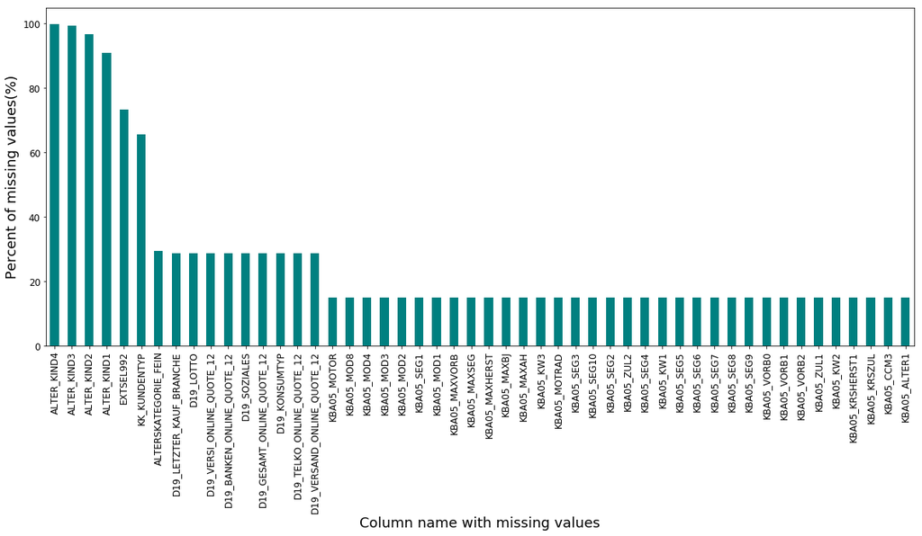

```python
# Visualizing the top 50 features with naturally missing data in the original azdias dataset.
plot_top50_feat(azdias)
```

```python
# Printing out a column missing_or_unknown value and its type for a particular attribute.
print(feat_info.loc[['AGER_TYP'], ['missing_or_unknown']].missing_or_unknown.item())
print('Type of missing_or_unknown column value : {}'.format(type(feat_info.\
                                                                 loc[['AGER_TYP'], ['missing_or_unknown']].\
                                                                 missing_or_unknown.item())))


# Parsing missing_or_unknown column having string values to array of lists and storing it in new columnn nan_vals.
nan_vals = feat_info['missing_or_unknown'].str.replace('[','').str.replace(']','').str.split(',').values

# Adding nan_vals column to the dataframe.
feat_info['nan_vals'] = nan_vals
#print(type(feat_info))

# Printing out the value and type of value in nan_vals column for a particular attribute after parsing.
print(feat_info.loc[['AGER_TYP'], ['nan_vals']].nan_vals.item())
print('Type of nan_vals column value : {}'.format(type(feat_info.loc[['AGER_TYP'], ['nan_vals']].nan_vals.item())))
```

```
[-1,0]
Type of missing_or_unknown column value : <class 'str'>
['-1', '0']
Type of nan_vals column value : <class 'list'>
```

```python
feat_info.head()
```

| attribute | information_level | type | missing_or_unknown | nan_vals |
| --- | --- | --- | --- | --- |
| AGER_TYP | person | categorical | [-1,0] | [-1, 0] |
| ALTERSKATEGORIE_GROB | person | ordinal | [-1,0,9] | [-1, 0, 9] |
| ANREDE_KZ | person | categorical | [-1,0] | [-1, 0] |
| CJT_GESAMTTYP | person | categorical | [0] | [0] |
| FINANZ_MINIMALIST | person | ordinal | [-1] | [-1] |

```python
# Converting (list of string) values to (list of integers and string) in nan_vals column.

def is_int(value):
    try:
        int(value)
#        print('Integer : {}'.format(value))
        return True
    except ValueError:
#        print('Character : {}'.format(value))
        return False

feat_info['nan_vals'] = feat_info.apply(lambda x: [int(i) if is_int(i) else i for i in x['nan_vals']], axis=1)
```

```python
# Sanity check.
# Printing out the value and type of value in nan_vals column for a particular attribute after converting
# to list of integers and string

print(feat_info.loc[['AGER_TYP'], ['nan_vals']].nan_vals.item())
print('Type of nan_vals column value : {}'.format(type(feat_info.loc[['AGER_TYP'], ['nan_vals']].nan_vals.item())))
```

```
[-1, 0]
Type of nan_vals column value : <class 'list'>
```

```python
# Identify missing or unknown data values in azdias dataframe columns and convert them to NaNs as per nan_vals in feat_info
for idx in feat_info.index:
    column = idx
    if column in azdias.columns:
        azdias[column] = azdias[column].replace(feat_info.loc[column]['nan_vals'], np.nan)
```

```python
# Sanity check after mapping missing_or_unknown values.
azdias['CAMEO_DEUG_2015'][2511]
```

```
nan
```

#### Step 1.1.2: Assess Missing Data in Each Column

How much missing data is present in each column? There are a few columns that are outliers in terms of the proportion of values that are missing. You will want to use matplotlib's hist() function to visualize the distribution of missing value counts to find these columns. Identify and document these columns. While some of these columns might have justifications for keeping or re-encoding the data, for this project you should just remove them from the dataframe. (Feel free to make remarks about these outlier columns in the discussion, however!)

For the remaining features, are there any patterns in which columns have, or share, missing data?

```python
# Perform an assessment of how much missing data there is in each column of the azdias dataset after encoding missing values
# Count value of NaN values in each column in descenindg order.
azdias_after_nan = find_missing_data(azdias)
azdias_after_nan
```

|  | count | pct |
| --- | --- | --- |
| ALTER_KIND4 | 890016 | 99.86 |
| TITEL_KZ | 889061 | 99.76 |
| ALTER_KIND3 | 885051 | 99.31 |
| ALTER_KIND2 | 861722 | 96.69 |
| ALTER_KIND1 | 810163 | 90.90 |
| AGER_TYP | 685843 | 76.96 |
| EXTSEL992 | 654153 | 73.40 |
| KK_KUNDENTYP | 584612 | 65.60 |
| KBA05_BAUMAX | 476524 | 53.47 |
| GEBURTSJAHR | 392318 | 44.02 |
| ALTER_HH | 310267 | 34.81 |
| ALTERSKATEGORIE_FEIN | 262947 | 29.50 |
| D19_VERSI_ONLINE_QUOTE_12 | 257113 | 28.85 |
| D19_VERSAND_ONLINE_QUOTE_12 | 257113 | 28.85 |
| D19_SOZIALES | 257113 | 28.85 |
| D19_LOTTO | 257113 | 28.85 |
| D19_LETZTER_KAUF_BRANCHE | 257113 | 28.85 |
| D19_KONSUMTYP | 257113 | 28.85 |
| D19_GESAMT_ONLINE_QUOTE_12 | 257113 | 28.85 |
| D19_BANKEN_ONLINE_QUOTE_12 | 257113 | 28.85 |
| D19_TELKO_ONLINE_QUOTE_12 | 257113 | 28.85 |
| REGIOTYP | 158064 | 17.74 |
| KKK | 158064 | 17.74 |
| KBA05_AUTOQUOT | 148115 | 16.62 |
| KBA05_SEG5 | 148110 | 16.62 |
| KBA05_MAXSEG | 148110 | 16.62 |
| KBA05_MAXHERST | 148110 | 16.62 |
| KBA05_MAXBJ | 148110 | 16.62 |
| KBA05_MAXAH | 148110 | 16.62 |
| KBA05_KW3 | 148110 | 16.62 |
| ... | ... | ... |
| VK_DISTANZ | 75917 | 8.52 |
| VK_ZG11 | 75917 | 8.52 |
| KONSUMNAEHE | 73969 | 8.30 |
| ANZ_PERSONEN | 73499 | 8.25 |
| ANZ_KINDER | 73499 | 8.25 |
| UNGLEICHENN_FLAG | 73499 | 8.25 |
| ANZ_TITEL | 73499 | 8.25 |
| EINGEZOGENAM_HH_JAHR | 73499 | 8.25 |
| AKT_DAT_KL | 73499 | 8.25 |
| WOHNDAUER_2008 | 73499 | 8.25 |
| SOHO_KZ | 73499 | 8.25 |
| VHA | 73499 | 8.25 |
| RT_UEBERGROESSE | 51226 | 5.75 |
| HH_EINKOMMEN_SCORE | 18348 | 2.06 |
| GFK_URLAUBERTYP | 4854 | 0.54 |
| RETOURTYP_BK_S | 4854 | 0.54 |
| RT_SCHNAEPPCHEN | 4854 | 0.54 |
| RT_KEIN_ANREIZ | 4854 | 0.54 |
| CJT_TYP_6 | 4854 | 0.54 |
| CJT_TYP_5 | 4854 | 0.54 |
| CJT_TYP_4 | 4854 | 0.54 |
| CJT_GESAMTTYP | 4854 | 0.54 |
| CJT_KATALOGNUTZER | 4854 | 0.54 |
| CJT_TYP_1 | 4854 | 0.54 |
| ONLINE_AFFINITAET | 4854 | 0.54 |
| CJT_TYP_2 | 4854 | 0.54 |
| CJT_TYP_3 | 4854 | 0.54 |
| LP_STATUS_GROB | 4854 | 0.54 |
| LP_STATUS_FEIN | 4854 | 0.54 |
| ALTERSKATEGORIE_GROB | 2881 | 0.32 |

281 rows × 2 columns

So, 281 columns have NaN data and we can see that after mapping missing_or_unknown values to NaN, columns TITEL_KZ, ALTER_KIND1, ALTER_KIND2, ALTER_KIND3 & ALTER_KIND4 has more than 65% of missing values.

```python
# Total number of missing obersvations after mapping missing_or_unknown values to NaN
# by using codes mentioned in feature summary file.
np.sum(azdias_after_nan['count'])
```

```
37827227
```

```python
# Define function to plot histogram of missing data in columns
def plot_hist_missing_col(df):
    '''
    INPUT:
        df - (dataframe), dataframe to check for missing data and plot histogram of the missing data in columns
    OUTPUT:
        visualization: (histogram), of the missing data
    '''
    plt.hist(df['pct'], bins=20, facecolor='g', alpha=0.75)

    plt.xlabel('Percentage of missing value (%)', fontsize=12)
    plt.ylabel('Counts', fontsize=12)
    plt.title('Histogram of missing value counts in columns', fontsize=12)
    plt.grid(True)
    plt.show()
```

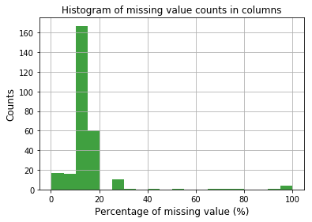

```python
# Plot distribution of missing value counts in columns
plot_hist_missing_col(azdias_after_nan)
```

We can see that columns with more than 20% missing values are outliers in the histogram above. Here, we will investigate those columns and decide if it is OK to drop them from the data frame. But first let’s see a bar plot of all columns with missing values and their percentage.

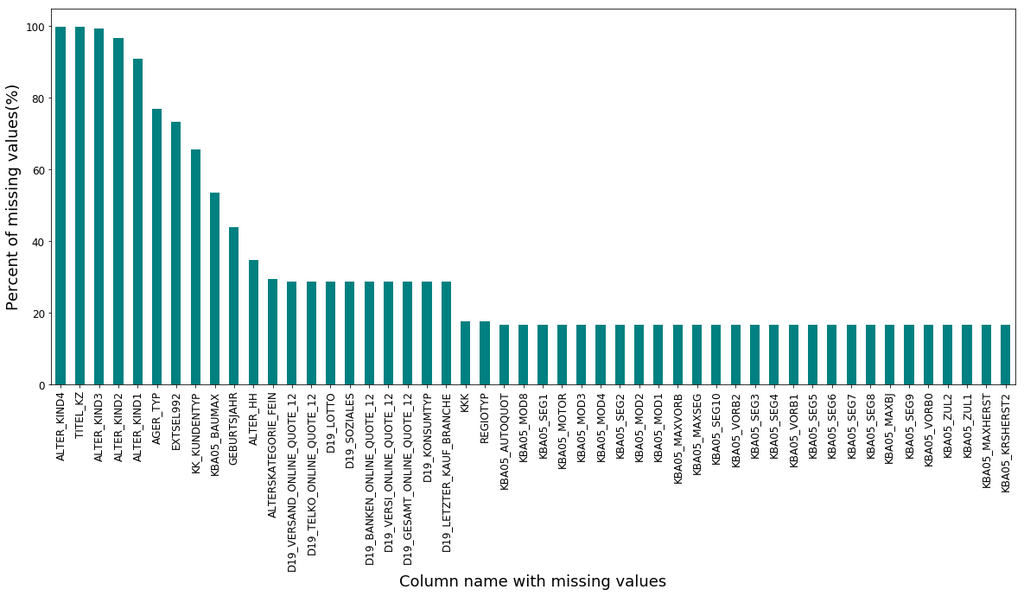

```python
# Visualizing the top 50 features with missing data(after encoding) in the azdias dataset.
plot_top50_feat(azdias)
```

```python
# Investigate patterns in the amount of missing data in each column.
index_groupby_info_level = {}
for info_level in feat_info['information_level'].unique():
    index_groupby_info_level[info_level] = feat_info[feat_info['information_level'] == info_level].index.values

index_groupby_info_level
```

```
{'person': array(['AGER_TYP', 'ALTERSKATEGORIE_GROB', 'ANREDE_KZ', 'CJT_GESAMTTYP',
        'FINANZ_MINIMALIST', 'FINANZ_SPARER', 'FINANZ_VORSORGER',
        'FINANZ_ANLEGER', 'FINANZ_UNAUFFAELLIGER', 'FINANZ_HAUSBAUER',
        'FINANZTYP', 'GEBURTSJAHR', 'GFK_URLAUBERTYP', 'GREEN_AVANTGARDE',
        'HEALTH_TYP', 'LP_LEBENSPHASE_FEIN', 'LP_LEBENSPHASE_GROB',
        'LP_FAMILIE_FEIN', 'LP_FAMILIE_GROB', 'LP_STATUS_FEIN',
        'LP_STATUS_GROB', 'NATIONALITAET_KZ', 'PRAEGENDE_JUGENDJAHRE',
        'RETOURTYP_BK_S', 'SEMIO_SOZ', 'SEMIO_FAM', 'SEMIO_REL',
        'SEMIO_MAT', 'SEMIO_VERT', 'SEMIO_LUST', 'SEMIO_ERL', 'SEMIO_KULT',
        'SEMIO_RAT', 'SEMIO_KRIT', 'SEMIO_DOM', 'SEMIO_KAEM',
        'SEMIO_PFLICHT', 'SEMIO_TRADV', 'SHOPPER_TYP', 'SOHO_KZ',
        'TITEL_KZ', 'VERS_TYP', 'ZABEOTYP'], dtype=object),
 'household': array(['ALTER_HH', 'ANZ_PERSONEN', 'ANZ_TITEL', 'HAUSHALTSSTRUKTUR',
        'HH_EINKOMMEN_SCORE', 'KK_KUNDENTYP', 'D19_KONSUMTYP',
        'D19_GESAMT_ANZ_12', 'D19_GESAMT_ANZ_24', 'D19_BANKEN_ANZ_12',
        'D19_BANKEN_ANZ_24', 'D19_TELKO_ ANZ_12', 'D19_TELKO_ ANZ_24',
        'D19_VERSI_ ANZ_12 ', 'D19_VERSI_ ANZ_24', 'D19_VERSAND_ ANZ_12 ',
        'D19_VERSAND_ ANZ_24', 'D19_GESAMT_OFFLINE_DATUM',
        'D19_GESAMT_ONLINE_DATUM', 'D19_GESAMT_DATUM',
        'D19_BANKEN_OFFLINE_DATUM', 'D19_BANKEN_ONLINE_DATUM',
        'D19_BANKEN_DATUM', 'D19_TELKO_OFFLINE_DATUM',
        'D19_TELKO_ONLINE_DATUM', 'D19_TELKO_DATUM',
        'D19_VERSAND_OFFLINE_DATUM', 'D19_VERSAND_ONLINE_DATUM',
        'D19_VERSAND_DATUM', 'D19_VERSI_OFFLINE_DATUM',
        'D19_VERSI_ONLINE_DATUM', 'D19_VERSI_DATUM',
        'D19_GESAMT_ONLINE_QUOTE_12', 'D19_BANKEN_ONLINE_QUOTE_12',
        'D19_VERSAND_ONLINE_QUOTE_12', 'W_KEIT_KIND_HH', 'WOHNDAUER_2008'], dtype=object),
 'building': array(['ANZ_HAUSHALTE_AKTIV', 'ANZ_HH_TITEL', 'GEBAEUDETYP',
        'GEOSCORE_KLS7', 'KBA05_HERSTTEMP', 'KBA05_MODTEMP', 'KONSUMNAEHE',
        'MIN_GEBAEUDEJAHR', 'OST_WEST_KZ', 'WOHNLAGE'], dtype=object),
 'microcell_rr4': array(['CAMEO_DEUG_2015', 'CAMEO_DEU_2015', 'CAMEO_INTL_2015'], dtype=object),
 'microcell_rr3': array(['KBA05_ALTER1', 'KBA05_ALTER2', 'KBA05_ALTER3', 'KBA05_ALTER4',
        'KBA05_ANHANG', 'KBA05_ANTG1', 'KBA05_ANTG2', 'KBA05_ANTG3',
        'KBA05_ANTG4', 'KBA05_AUTOQUOT', 'KBA05_BAUMAX', 'KBA05_CCM1',
        'KBA05_CCM2', 'KBA05_CCM3', 'KBA05_CCM4', 'KBA05_DIESEL',
        'KBA05_FRAU', 'KBA05_GBZ', 'KBA05_HERST1', 'KBA05_HERST2',
        'KBA05_HERST3', 'KBA05_HERST4', 'KBA05_HERST5', 'KBA05_KRSAQUOT',
        'KBA05_KRSHERST1', 'KBA05_KRSHERST2', 'KBA05_KRSHERST3',
        'KBA05_KRSKLEIN', 'KBA05_KRSOBER', 'KBA05_KRSVAN', 'KBA05_KRSZUL',
        'KBA05_KW1', 'KBA05_KW2', 'KBA05_KW3', 'KBA05_MAXAH', 'KBA05_MAXBJ',
```

[output cut: 46 more lines]

```
        'KBA13_KW_90', 'KBA13_KW_110', 'KBA13_KW_120', 'KBA13_KW_121',
        'KBA13_MAZDA', 'KBA13_MERCEDES', 'KBA13_MOTOR', 'KBA13_NISSAN',
        'KBA13_OPEL', 'KBA13_PEUGEOT', 'KBA13_RENAULT',
        'KBA13_SEG_GELAENDEWAGEN', 'KBA13_SEG_GROSSRAUMVANS',
        'KBA13_SEG_KLEINST', 'KBA13_SEG_KLEINWAGEN',
        'KBA13_SEG_KOMPAKTKLASSE', 'KBA13_SEG_MINIVANS',
        'KBA13_SEG_MINIWAGEN', 'KBA13_SEG_MITTELKLASSE',
        'KBA13_SEG_OBEREMITTELKLASSE', 'KBA13_SEG_OBERKLASSE',
        'KBA13_SEG_SONSTIGE', 'KBA13_SEG_SPORTWAGEN', 'KBA13_SEG_UTILITIES',
        'KBA13_SEG_VAN', 'KBA13_SEG_WOHNMOBILE', 'KBA13_SITZE_4',
        'KBA13_SITZE_5', 'KBA13_SITZE_6', 'KBA13_TOYOTA', 'KBA13_VORB_0',
        'KBA13_VORB_1', 'KBA13_VORB_1_2', 'KBA13_VORB_2', 'KBA13_VORB_3',
        'KBA13_VW', 'PLZ8_ANTG1', 'PLZ8_ANTG2', 'PLZ8_ANTG3', 'PLZ8_ANTG4',
        'PLZ8_BAUMAX', 'PLZ8_HHZ', 'PLZ8_GBZ'], dtype=object),
 'community': array(['ARBEIT', 'ORTSGR_KLS9', 'RELAT_AB'], dtype=object)}
```

```python
index_groupby_info_level.keys()
```

```
dict_keys(['person', 'household', 'building', 'microcell_rr4', 'microcell_rr3', '125m_125m_grid', 'postcode', 'region_rr1', 'plz8', 'community'])
```

```python
index_groupby_info_level['person']
```

```
array(['AGER_TYP', 'ALTERSKATEGORIE_GROB', 'ANREDE_KZ', 'CJT_GESAMTTYP',
       'FINANZ_MINIMALIST', 'FINANZ_SPARER', 'FINANZ_VORSORGER',
       'FINANZ_ANLEGER', 'FINANZ_UNAUFFAELLIGER', 'FINANZ_HAUSBAUER',
       'FINANZTYP', 'GEBURTSJAHR', 'GFK_URLAUBERTYP', 'GREEN_AVANTGARDE',
       'HEALTH_TYP', 'LP_LEBENSPHASE_FEIN', 'LP_LEBENSPHASE_GROB',
       'LP_FAMILIE_FEIN', 'LP_FAMILIE_GROB', 'LP_STATUS_FEIN',
       'LP_STATUS_GROB', 'NATIONALITAET_KZ', 'PRAEGENDE_JUGENDJAHRE',
       'RETOURTYP_BK_S', 'SEMIO_SOZ', 'SEMIO_FAM', 'SEMIO_REL',
       'SEMIO_MAT', 'SEMIO_VERT', 'SEMIO_LUST', 'SEMIO_ERL', 'SEMIO_KULT',
       'SEMIO_RAT', 'SEMIO_KRIT', 'SEMIO_DOM', 'SEMIO_KAEM',
       'SEMIO_PFLICHT', 'SEMIO_TRADV', 'SHOPPER_TYP', 'SOHO_KZ',
       'TITEL_KZ', 'VERS_TYP', 'ZABEOTYP'], dtype=object)
```

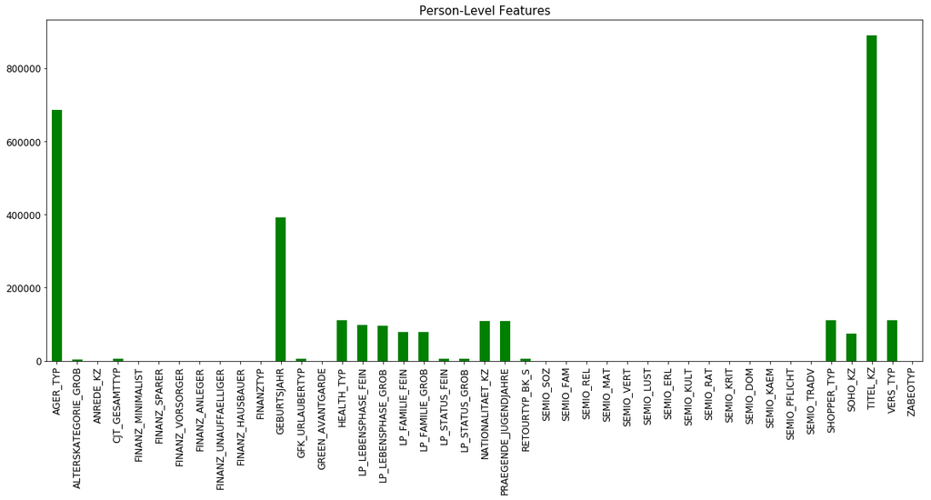

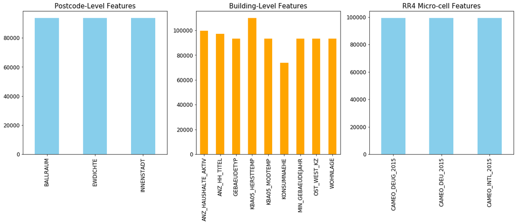

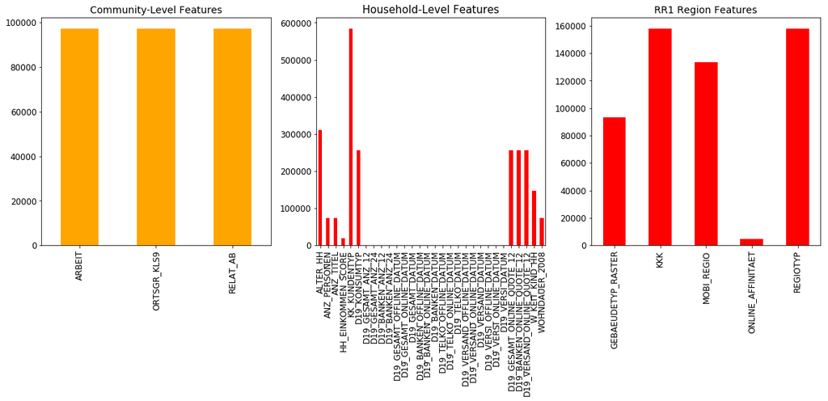

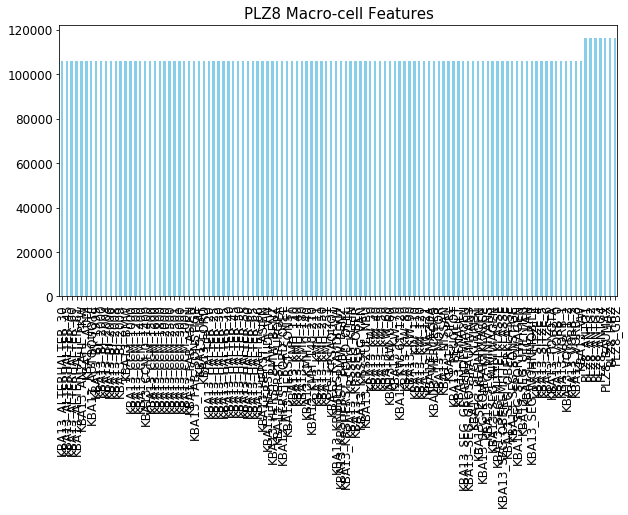

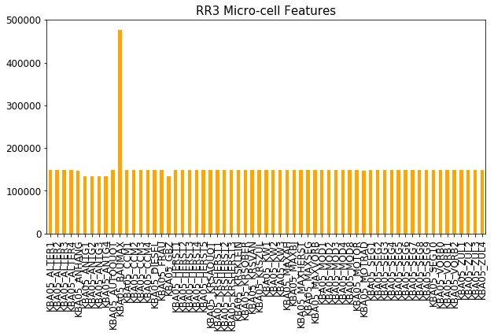

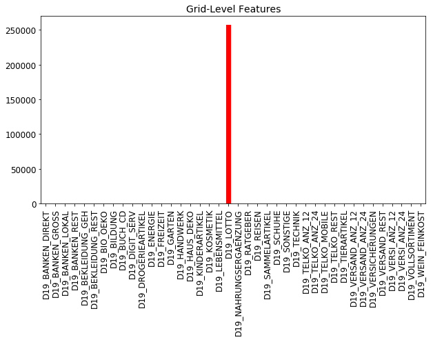

```python
# Visualize the missing data by each data group i.e. by feature level.

plt.figure(1,figsize=(20,8))

plt.subplot(111)
person = []
for col in index_groupby_info_level['person'].tolist():
    if col in azdias.columns:
        person.append(col)
azdias[person].isnull().sum().plot.bar(fontsize=12,color='green')
plt.title('Person-Level Features',fontsize=15)

plt.figure(2,figsize=(20,6))

plt.subplot(131)
postcode = []
for col in index_groupby_info_level['postcode'].tolist():
    if col in azdias.columns:
        postcode.append(col)
azdias[postcode].isnull().sum().plot.bar(fontsize=12,color='skyblue')
plt.title('Postcode-Level Features',fontsize=15)

plt.subplot(132)
building = []
for col in index_groupby_info_level['building'].tolist():
    if col in azdias.columns:
        building.append(col)
azdias[building].isnull().sum().plot.bar(fontsize=12,color='orange')
plt.title('Building-Level Features',fontsize=15)

plt.subplot(133)
microcell_rr4 = []
for col in index_groupby_info_level['microcell_rr4'].tolist():
    if col in azdias.columns:
        microcell_rr4.append(col)
azdias[microcell_rr4].isnull().sum().plot.bar(fontsize=12,color='skyblue')
plt.title('RR4 Micro-cell Features',fontsize=15)


plt.figure(3,figsize=(20,6))

plt.subplot(131)
community = []
for col in index_groupby_info_level['community'].tolist():
    if col in azdias.columns:
        community.append(col)
azdias[community].isnull().sum().plot.bar(fontsize=12,color='orange')
plt.title('Community-Level Features',fontsize=14)

plt.subplot(132)
household = []
for col in index_groupby_info_level['household'].tolist():
    if col in azdias.columns:
        household.append(col)
azdias[household].isnull().sum().plot.bar(fontsize=12,color='red')
plt.title('Household-Level Features',fontsize=15)

plt.subplot(133)
region_rr1 = []
for col in index_groupby_info_level['region_rr1'].tolist():
    if col in azdias.columns:
        region_rr1.append(col)
azdias[index_groupby_info_level['region_rr1'].tolist()].isnull().sum().plot.bar(fontsize=12,color='red')
plt.title('RR1 Region Features',fontsize=14)


plt.figure(4,figsize=(10,5))

plt.subplot(111)
plz8 = []
for col in index_groupby_info_level['plz8'].tolist():
    if col in azdias.columns:
        plz8.append(col)
azdias[plz8].isnull().sum().plot.bar(fontsize=12,color='skyblue')
plt.title('PLZ8 Macro-cell Features',fontsize=15)

plt.figure(5,figsize=(10,5))

plt.subplot(111)
microcell_rr3 = []
for col in index_groupby_info_level['microcell_rr3'].tolist():
    if col in azdias.columns:
        microcell_rr3.append(col)
azdias[microcell_rr3].isnull().sum().plot.bar(fontsize=12,color='orange')
plt.title('RR3 Micro-cell Features',fontsize=15)


plt.figure(6,figsize=(10,5))

plt.subplot(111)
grid = []
for col in index_groupby_info_level['125m_125m_grid'].tolist():
    if col in azdias.columns:
        grid.append(col)
azdias[grid].isnull().sum().plot.bar(fontsize=12,color='red')
plt.title('Grid-Level Features',fontsize=14)

plt.show()
```

```python
# Define function to find columns with 20% missing values
def find_cols_missing_pct_data(df, pct):
    '''
    INPUT:
        df - (dataframe), dataframe to check for missing values in its columns
    OUTPUT:
        missing_pct_cols: (list), list of columns with more than pct missing values
    '''
    missing_pct_cols = [col for col in df.columns if (df[col].isnull().sum()/df.shape[0]) * 100 > pct]
    return missing_pct_cols
```

```python
# Find the name of columns with more than 20% missing values
missing_20 = find_cols_missing_pct_data(azdias, pct=20)
print(missing_20)
```

```
['AGER_TYP', 'ALTER_HH', 'ALTER_KIND1', 'ALTER_KIND2', 'ALTER_KIND3', 'ALTER_KIND4', 'ALTERSKATEGORIE_FEIN', 'D19_BANKEN_ONLINE_QUOTE_12', 'D19_GESAMT_ONLINE_QUOTE_12', 'D19_KONSUMTYP', 'D19_LETZTER_KAUF_BRANCHE', 'D19_LOTTO', 'D19_SOZIALES', 'D19_TELKO_ONLINE_QUOTE_12', 'D19_VERSAND_ONLINE_QUOTE_12…
```

```python
# Remove the outlier columns from the dataset. (You'll perform other data
# engineering tasks such as re-encoding and imputation later.)
azdias.drop(missing_20, axis=1, inplace=True)
```

```python
# Droping column LNR from azdias dataframe as column LNR is unique ID assigned to an each individual
azdias.drop('LNR', axis=1, inplace=True)
```

```python
# Shape of azdias dataframe after removing outliers columns and column 'LNR'
azdias.shape
```

```
(891221, 344)
```

#### Discussion 1.1.2: Assess Missing Data in Each Column

- From the above graphs and plots, we can see 21 columns clearly stand out, with more than 20% of missing observations namely 'AGER_TYP', 'ALTER_HH', 'ALTER_KIND1', 'ALTER_KIND2', 'ALTER_KIND3', 'ALTER_KIND4', 'ALTERSKATEGORIE_FEIN', 'D19_BANKEN_ONLINE_QUOTE_12', 'D19_GESAMT_ONLINE_QUOTE_12', 'D19_KONSUMTYP', 'D19_LETZTER_KAUF_BRANCHE', 'D19_LOTTO', 'D19_SOZIALES', 'D19_TELKO_ONLINE_QUOTE_12', 'D19_VERSAND_ONLINE_QUOTE_12', 'D19_VERSI_ONLINE_QUOTE_12', 'EXTSEL992', 'GEBURTSJAHR', 'KBA05_BAUMAX', 'KK_KUNDENTYP', 'TITEL_KZ'. Therefore, taking the decision to drop the 21 outlier columns.

#### Step 1.1.3: Assess Missing Data in Each Row

Now, you'll perform a similar assessment for the rows of the dataset. How much data is missing in each row? As with the columns, you should see some groups of points that have a very different numbers of missing values. Divide the data into two subsets: one for data points that are above some threshold for missing values, and a second subset for points below that threshold.

In order to know what to do with the outlier rows, we should see if the distribution of data values on columns that are not missing data (or are missing very little data) are similar or different between the two groups. Select at least five of these columns and compare the distribution of values.

- You can use seaborn's [countplot()](https://seaborn.pydata.org/generated/seaborn.countplot.html) function to create a bar chart of code frequencies and matplotlib's [subplot()](https://matplotlib.org/api/_as_gen/matplotlib.pyplot.subplot.html) function to put bar charts for the two subplots side by side.
- To reduce repeated code, you might want to write a function that can perform this comparison, taking as one of its arguments a column to be compared.

Depending on what you observe in your comparison, this will have implications on how you approach your conclusions later in the analysis. If the distributions of non-missing features look similar between the data with many missing values and the data with few or no missing values, then we could argue that simply dropping those points from the analysis won't present a major issue. On the other hand, if the data with many missing values looks very different from the data with few or no missing values, then we should make a note on those data as special. We'll revisit these data later on. **Either way, you should continue your analysis for now using just the subset of the data with few or no missing values.**

```python
# How much data is missing in each row of the dataset?
azdias_null_data_row = azdias.isnull().sum(axis=1)

# Aggregate missing row data by number of missing values per row
print('Below are the number of missing values in a row along with their frequencies')
azdias_null_data_row.value_counts().sort_index()
```

```
Below are the number of missing values in a row along with their frequencies
```

```
0      611722
1       10335
2       26076
3       17884
4       12937
5        4252
6       24953
7        9923
8       11004
9         872
10       1254
11        667
12        479
13        262
14        151
```

[output cut: 47 more lines]

```python
# Aggregate missing row data by percentage of missing values per row
a = azdias_null_data_row/(len(azdias.columns)) * 100
a.sort_values(inplace=True)
a.value_counts().sort_index()
```

```
0.000000     611722
0.290698      10335
0.581395      26076
0.872093      17884
1.162791      12937
1.453488       4252
1.744186      24953
2.034884       9923
2.325581      11004
2.616279        872
2.906977       1254
3.197674        667
3.488372        479
3.779070        262
4.069767        151
4.360465         74
4.651163         26
4.941860         17
5.232558          7
5.523256          4
5.813953       1916
6.104651         23
6.395349         84
6.686047       1901
6.976744         97
7.267442        106
7.558140         87
7.848837         73
8.139535         46
8.430233         45
              ...
61.046512         2
61.337209         1
61.627907         6
61.918605         4
62.209302         3
62.500000         6
62.790698         2
63.081395         2
63.372093       206
63.662791      2870
63.953488     10880
64.244186      3960
64.534884        82
64.825581        84
65.116279       730
65.406977       223
65.697674       138
65.988372       344
66.279070        12
66.569767        13
66.860465        10
69.186047     27348
69.476744       111
69.767442       508
70.058140         8
70.348837         6
70.639535     45606
70.930233         9
71.220930         2
71.802326         1
Length: 174, dtype: int64
```

```python
# Define function to plot histogram of missing data in rows
def plot_hist_missing_row(df, pct):
    '''
    INPUT:
        df - (dataframe), dataframe to check for missing data and plot histogram of the misisng data in rows
        pct - (%), percentage of missing value. 0 means with all the missing values. Anything greater than 0 means
             with missing values equal to or greater than that value i.e. 8 means, equal to or
             more than 8 missing values
    OUTPUT:
        visualization: (histogram), of the missing data
    '''
    df_null_data_row = df.isnull().sum(axis=1)
    df_null_data_row_percentage = df_null_data_row/(len(df.columns)) * 100
    df_null_data_row_percentage.sort_values(inplace=True)

    if pct == 0:
        plt.hist(df_null_data_row_percentage, bins=20, facecolor='g', alpha=0.75)
    elif pct > 0:
        plt.hist(df_null_data_row_percentage[df_null_data_row_percentage >= pct], bins=20, facecolor='g', alpha=0.75)

    plt.xlabel('Percentage of missing value (%)')
    plt.ylabel('Counts')
    plt.title('Histogram of missing value counts in rows')
    plt.grid(True)
    plt.show()
```

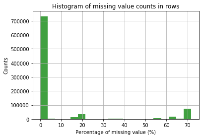

```python
# Plot distribution of missing value counts in rows.
plot_hist_missing_row(azdias, pct=0)
```

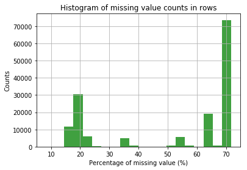

```python
# Zooming in the histogram and ploting the distribution of rows with atleast 8% missing data.
plot_hist_missing_row(azdias, pct=8)
```

```python
# Calculate count and percentage of rows with no missing data points

print('Count of rows with no missing data points: {}'\
      .format(np.round(azdias_null_data_row.value_counts().sort_index().cumsum()[0])))
print('Total number of rows in the dataset : {}'.format(azdias.shape[0]))
print('Percentage of rows with no missing data points: {}%'\
      .format(np.round(azdias_null_data_row.value_counts().sort_index().cumsum()[0]/azdias.shape[0] *100,2)))
```

```
Count of rows with no missing data points: 611722
Total number of rows in the dataset : 891221
Percentage of rows with no missing data points: 68.64%
```

```python
# Calculate cumulative sum of rows with 28 or less missing data points
cumsum= azdias_null_data_row.value_counts().sort_index().cumsum()[:28]
print('Cumulative sums of rows with 28 or less missing data points are : \n{}'.format(cumsum))

cumsum_percentage = np.round(azdias_null_data_row.value_counts().sort_index().cumsum()[:28]/azdias_null_data_row.shape[0]*100,2)
print('\nCumulative percentage of rows with 28 or less missing data points are : \n{}'.format(cumsum_percentage))
```

```
Cumulative sums of rows with 28 or less missing data points are :
0     611722
1     622057
2     648133
3     666017
4     678954
5     683206
6     708159
7     718082
8     729086
9     729958
10    731212
11    731879
12    732358
13    732620
```

[output cut: 46 more lines]

```python
# Calculate percentage of rows with 8 or less missing data points

print('Count of rows with 8 or less missing data points: {}'.format(cumsum[8]))
print('Total number of rows in the dataset : {}'.format(azdias.shape[0]))
print("Percentage of rows with 8 or less missing data points:",cumsum_percentage[8],"%")
```

```
Count of rows with 8 or less missing data points: 729086
Total number of rows in the dataset : 891221
Percentage of rows with 8 or less missing data points: 81.81 %
```

```python
# Write code to divide the data into two subsets based on the number of missing
# values to be 8 or less in each row.

#azdias_null_data_row_few = azdias[azdias.isnull().sum(axis=1) < 9].reset_index(drop=True)
azdias_null_data_row_few = azdias[azdias.isnull().sum(axis=1) < 9]

#azdias_null_data_row_high = azdias[azdias.isnull().sum(axis=1) >= 9].reset_index(drop=True)
azdias_null_data_row_high = azdias[azdias.isnull().sum(axis=1) >= 9]
```

```python
# Printing the number of rows with few missing data and high missing data.
print('Number of rows with few missing data : {}'.format(azdias_null_data_row_few.shape[0]))
print('Number of rows with high missing data : {}'.format(azdias_null_data_row_high.shape[0]))

# Checking if the number of rows with few missing data and high missing data adds upto total number of rows in azdias dataset.
if azdias.shape[0] == azdias_null_data_row_few.shape[0] + azdias_null_data_row_high.shape[0]:
    print('Number of rows with few missing data and high missing data adds upto total number of rows in azdias dataset,\
 which is : {}'.format(azdias_null_data_row_few.shape[0] + azdias_null_data_row_high.shape[0]))
else:
    print('Number of total rows in few missing dataset and high missing dataset is not equal\
    to the total number of rows in the dataset')
```

```
Number of rows with few missing data : 729086
Number of rows with high missing data : 162135
Number of rows with few missing data and high missing data adds upto total number of rows in azdias dataset, which is : 891221
```

```python
# Printing columns with no or less than 2 missing values in columns of azdias dataset with outliers columns removed.

azdias_no_null_columns = azdias.isnull().sum() < 2
print('Below are the columns of azdias dataset(outliers removed azdias dataset) with no nulls or less than 2 missing values\n')
print(azdias_no_null_columns[azdias_no_null_columns.values == True].index)
```

```
Below are the columns of azdias dataset(outliers removed azdias dataset) with no nulls or less than 2 missing values

Index(['D19_BANKEN_ANZ_12', 'D19_BANKEN_ANZ_24', 'D19_BANKEN_DATUM',
       'D19_BANKEN_DIREKT', 'D19_BANKEN_GROSS', 'D19_BANKEN_LOKAL',
       'D19_BANKEN_OFFLINE_DATUM', 'D19_BANKEN_ONLINE_DATUM',
       'D19_BANKEN_REST', 'D19_BEKLEIDUNG_GEH', 'D19_BEKLEIDUNG_REST',
       'D19_BILDUNG', 'D19_BIO_OEKO', 'D19_BUCH_CD', 'D19_DIGIT_SERV',
       'D19_DROGERIEARTIKEL', 'D19_ENERGIE', 'D19_FREIZEIT', 'D19_GARTEN',
       'D19_GESAMT_ANZ_12', 'D19_GESAMT_ANZ_24', 'D19_GESAMT_DATUM',
       'D19_GESAMT_OFFLINE_DATUM', 'D19_GESAMT_ONLINE_DATUM', 'D19_HANDWERK',
       'D19_HAUS_DEKO', 'D19_KINDERARTIKEL', 'D19_KONSUMTYP_MAX',
       'D19_KOSMETIK', 'D19_LEBENSMITTEL', 'D19_NAHRUNGSERGAENZUNG',
       'D19_RATGEBER', 'D19_REISEN', 'D19_SAMMELARTIKEL', 'D19_SCHUHE',
       'D19_SONSTIGE', 'D19_TECHNIK', 'D19_TELKO_ANZ_12', 'D19_TELKO_ANZ_24',
       'D19_TELKO_DATUM', 'D19_TELKO_MOBILE', 'D19_TELKO_OFFLINE_DATUM',
       'D19_TELKO_ONLINE_DATUM', 'D19_TELKO_REST', 'D19_TIERARTIKEL',
       'D19_VERSAND_ANZ_12', 'D19_VERSAND_ANZ_24', 'D19_VERSAND_DATUM',
       'D19_VERSAND_OFFLINE_DATUM', 'D19_VERSAND_ONLINE_DATUM',
       'D19_VERSAND_REST', 'D19_VERSI_ANZ_12', 'D19_VERSI_ANZ_24',
       'D19_VERSI_DATUM', 'D19_VERSI_OFFLINE_DATUM', 'D19_VERSI_ONLINE_DATUM',
       'D19_VERSICHERUNGEN', 'D19_VOLLSORTIMENT', 'D19_WEIN_FEINKOST',
       'FINANZ_ANLEGER', 'FINANZ_HAUSBAUER', 'FINANZ_MINIMALIST',
       'FINANZ_SPARER', 'FINANZ_UNAUFFAELLIGER', 'FINANZ_VORSORGER',
       'FINANZTYP', 'GREEN_AVANTGARDE', 'KOMBIALTER', 'SEMIO_DOM', 'SEMIO_ERL',
       'SEMIO_FAM', 'SEMIO_KAEM', 'SEMIO_KRIT', 'SEMIO_KULT', 'SEMIO_LUST',
       'SEMIO_MAT', 'SEMIO_PFLICHT', 'SEMIO_RAT', 'SEMIO_REL', 'SEMIO_SOZ',
       'SEMIO_TRADV', 'SEMIO_VERT', 'ZABEOTYP', 'ANREDE_KZ'],
      dtype='object')
```

```
Randomly selected columns names with no or 1 missing values are :
['FINANZ_ANLEGER', 'SEMIO_REL', 'D19_VERSAND_DATUM', 'D19_SCHUHE', 'D19_FREIZEIT']
```

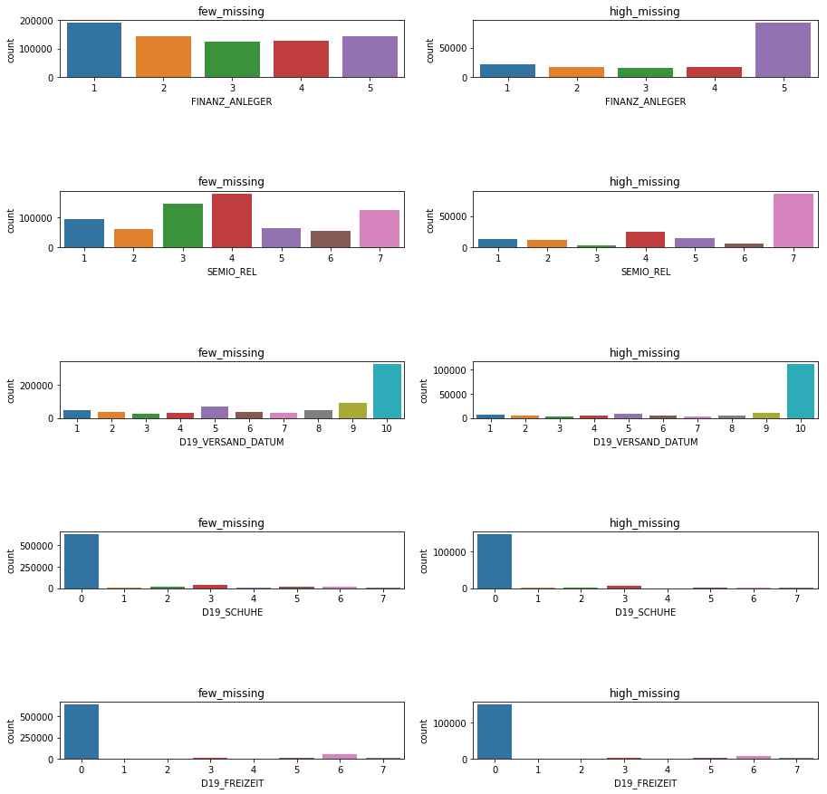

```python
# Compare the distribution of values for at least five columns where there are
# no or few missing values, between the two subsets.

col_names_no_null = list(azdias_no_null_columns[azdias_no_null_columns.values == True].index)

# Selecting random sample from the list of columns with no null values.
random.seed(9)
random_cols = random.sample(col_names_no_null, 5)
print('Randomly selected columns names with no or 1 missing values are : \n{}'.format(random_cols))

def print_countplot(cols, num):

    fig, axs = plt.subplots(num,2, figsize=(15, 15), facecolor='w', edgecolor='k')
    fig.subplots_adjust(hspace =2 , wspace=.2)
    axs = axs.ravel()

    for i in range(num):

        sns.countplot(azdias_null_data_row_few[cols[i]], ax=axs[i*2])
        axs[i*2].set_title('few_missing')

        sns.countplot(azdias_null_data_row_high[cols[i]], ax=axs[i*2+1])
        axs[i*2+1].set_title('high_missing')


print_countplot(random_cols, 5)
```

```python
# Drop rows with high missing values in the azdias dataset.
print('Total number of rows : {}'.format(azdias.shape[0]))

azdias = azdias[azdias.index.isin(azdias_null_data_row_few.index)]

print('Number of rows after dropping rows with more than 8 missing values : {}'.format(azdias.shape[0]))
```

```
Total number of rows : 891221
Number of rows after dropping rows with more than 8 missing values : 729086
```

#### Discussion 1.1.3: Assess Missing Data in Each Row

First of all, we can see 611,722 rows are complete out of a total of 891,221 or 68.64% of the total dataset is complete.

Clearly we can see from the above histograms that most of our data comprises of rows with no missing values(68.64%).Therefore, about 69% of our dataset is complete. Also, we can see that there appears to be multiple groups in small patches with more than 8% of the missing data in rows making them as outliers. With 8 or less missing data in rows, we still have 81.81% of data retained. With more than 8 missing data in rows, there is not substantial increase in cumulative percentage of data retained.

Now, 8% of 344 columns or features turns out be in 27.52. We can observe that after 8 missing values in a row, there is not a substantial increase in cumulative percentage of data retained. Therefore, finding a break at 8 missing values in a row could be the appropriate choice if we have to keep rows with few missing values and droping the rows with more than 8 missing values would not lead to major issue. So, droping rows which contains more than 8 missing values in a row leads to reduction of 162135 number of rows and our total number of rows after reduction would make our azdias dataset with 729086 number of rows and it contains rows with maximum 8 missing values in a row.

If we compare the distribution of 5 random selected features or columns that are missing less than 2 data values in these 2 subsets(One with 8 or less missing values & other with more than 8 missing values) as can be seen from the above bar charts, we could see that the distribution of columns data within subset of few missing values is qualitatively different from the columns data within subset of many missing values. We can see features 'D19_VERSAND_DATUM', 'D19_SCHUHE', 'D19_FREIZEIT' seems comparable and other features namely 'FINANZ_ANLEGER', 'SEMIO_REL' are highly different in distribution.

Considering that the clustering algorithm K-means requires no missing information to work and that the dataset is made up of mainly ordinal and categorical data, where imputing values with means, modes or medians can impact the truth of the dataset much more than if the dataset was made up of numerical data. Therefore, it seems more appropriate to minimize imputing missing data and maintain the integrity at maximum. Therfore, we would minimize imputing missing values to 8 missing values in a row.

We could also have discarded all rows with any missing values and kept 69% of the complete dataset and performed no imputation. In a real-world scenario, we would have discarded all rows with any missing observations, but since we are doing this course to learn, therefore, we would keep rows with 8 or less missing values and do all the steps and practice everything.

#### Step 1.1.4: Checking for columns which didn't had description in feature summary file

```python
# Number of columns in azdias
len(azdias.columns)
```

```
344
```

```python
# Find columns whcich are not in feat_info but in azdias
# Find number of attributes which are in azdias but not in feat_info
attr_not_in_feat_info = np.setdiff1d(np.array(azdias.columns), np.array(feat_info.index), assume_unique=True)
print(len(attr_not_in_feat_info))
```

```
42
```

So, from above, after removing 21 outliers columns and column 'LNR' in azdias, we have reduced features from 366 to 344 in azdias. Now, we have 302 common features in azdias & feat_info i.e. 302 features had a description in feat_info. Therefore, we have 42 features in azdias which are not in feat_info i.e. 42 features in azdias didn't had a description in feat_info.

```python
# Print features not in feat_info but in azdias
attr_not_in_feat_info
```

```
array(['AKT_DAT_KL', 'ANZ_KINDER', 'ANZ_STATISTISCHE_HAUSHALTE',
       'CJT_KATALOGNUTZER', 'CJT_TYP_1', 'CJT_TYP_2', 'CJT_TYP_3',
       'CJT_TYP_4', 'CJT_TYP_5', 'CJT_TYP_6', 'D19_KONSUMTYP_MAX',
       'DSL_FLAG', 'EINGEFUEGT_AM', 'EINGEZOGENAM_HH_JAHR', 'FIRMENDICHTE',
       'GEMEINDETYP', 'HH_DELTA_FLAG', 'KBA13_ANTG1', 'KBA13_ANTG2',
       'KBA13_ANTG3', 'KBA13_ANTG4', 'KBA13_BAUMAX', 'KBA13_CCM_1401_2500',
       'KBA13_GBZ', 'KBA13_HHZ', 'KBA13_KMH_210', 'KOMBIALTER',
       'KONSUMZELLE', 'MOBI_RASTER', 'RT_KEIN_ANREIZ', 'RT_SCHNAEPPCHEN',
       'RT_UEBERGROESSE', 'STRUKTURTYP', 'UMFELD_ALT', 'UMFELD_JUNG',
       'UNGLEICHENN_FLAG', 'VERDICHTUNGSRAUM', 'VHA', 'VHN', 'VK_DHT4A',
       'VK_DISTANZ', 'VK_ZG11'], dtype=object)
```

Let us analyse each of the above 42 features and decide if we can drop them or we need to keep them in azdias for further anaylsis.

```python
# Find percentage of missing values in 42 features not in feat_info
np.round(azdias[attr_not_in_feat_info.tolist()].isnull().sum().sort_values(ascending=False)/\
         azdias[attr_not_in_feat_info.tolist()].shape[0],2)
```

```
HH_DELTA_FLAG                 0.04
VHN                           0.01
GEMEINDETYP                   0.00
VERDICHTUNGSRAUM              0.00
STRUKTURTYP                   0.00
UMFELD_JUNG                   0.00
UMFELD_ALT                    0.00
RT_UEBERGROESSE               0.00
FIRMENDICHTE                  0.00
KONSUMZELLE                   0.00
CJT_TYP_5                     0.00
EINGEZOGENAM_HH_JAHR          0.00
EINGEFUEGT_AM                 0.00
DSL_FLAG                      0.00
D19_KONSUMTYP_MAX             0.00
CJT_TYP_6                     0.00
VK_ZG11                       0.00
CJT_TYP_4                     0.00
CJT_TYP_3                     0.00
CJT_TYP_1                     0.00
CJT_KATALOGNUTZER             0.00
ANZ_STATISTISCHE_HAUSHALTE    0.00
ANZ_KINDER                    0.00
CJT_TYP_2                     0.00
KBA13_ANTG4                   0.00
KBA13_ANTG1                   0.00
KOMBIALTER                    0.00
VK_DHT4A                      0.00
VHA                           0.00
UNGLEICHENN_FLAG              0.00
RT_SCHNAEPPCHEN               0.00
RT_KEIN_ANREIZ                0.00
MOBI_RASTER                   0.00
KBA13_KMH_210                 0.00
KBA13_ANTG2                   0.00
KBA13_HHZ                     0.00
KBA13_GBZ                     0.00
KBA13_CCM_1401_2500           0.00
KBA13_BAUMAX                  0.00
VK_DISTANZ                    0.00
KBA13_ANTG3                   0.00
AKT_DAT_KL                    0.00
dtype: float64
```

```python
# Print dtype of each of the 42 features not in feat_info
data_type_42 = {}
for col in attr_not_in_feat_info:
        data_type = azdias[col].dtype
        if data_type not in data_type_42:
            data_type_42[data_type] = 1
        else:
            data_type_42[data_type] += 1

print('Nunber of features of each data type are : {}'.format(data_type_42))
```

```
Nunber of features of each data type are : {dtype('float64'): 39, dtype('int64'): 2, dtype('O'): 1}
```

```python
# Find col_names for each dtype in 42 features not in feat_info
int_col_name_42 = []
float_col_name_42 = []
object_col_name_42 = []

for col in attr_not_in_feat_info:
        data_type = azdias[col].dtype
        if data_type.name == 'float64':
            float_col_name_42.append(col)
        elif data_type.name == 'int64':
            int_col_name_42.append(col)
        elif data_type == 'O':
            object_col_name_42.append(col)

print("Columns with float dtype: {}\n".format(float_col_name_42))
print("Columns with int dtype: {}\n".format(int_col_name_42))
print("Columns with object dtype: {}".format(object_col_name_42))
```

```
Columns with float dtype: ['AKT_DAT_KL', 'ANZ_KINDER', 'ANZ_STATISTISCHE_HAUSHALTE', 'CJT_KATALOGNUTZER', 'CJT_TYP_1', 'CJT_TYP_2', 'CJT_TYP_3', 'CJT_TYP_4', 'CJT_TYP_5', 'CJT_TYP_6', 'DSL_FLAG', 'EINGEZOGENAM_HH_JAHR', 'FIRMENDICHTE', 'GEMEINDETYP', 'HH_DELTA_FLAG', 'KBA13_ANTG1', 'KBA13_ANTG2', 'K…

Columns with int dtype: ['D19_KONSUMTYP_MAX', 'KOMBIALTER']

Columns with object dtype: ['EINGEFUEGT_AM']
```

After analyzing the above 42 features which are in azdias but not in feat_info, below are the findings -

- There are 4 binary value features - DSL_FLAG, HH_DELTA_FLAG, KONSUMZELLE & UNGLEICHENN_FLAG.
- There are 2 date value features - EINGEZOGENAM_HH_JAHR, EINGEFUEGT_AM.
- There are 1 multi-level categorical feature - GEMEINDETYP.
- There are 35 ordinal features - AKT_DAT_KL, ANZ_KINDER, ANZ_STATISTISCHE_HAUSHALTE, CJT_KATALOGNUTZER, CJT_TYP_1, CJT_TYP_2, CJT_TYP_3, CJT_TYP_4, CJT_TYP_5, CJT_TYP_6, FIRMENDICHTE, KBA13_ANTG1, KBA13_ANTG2,KBA13_ANTG3, KBA13_ANTG4, KBA13_BAUMAX, KBA13_CCM_1401_2500, KBA13_GBZ,KBA13_HHZ, KBA13_KMH_210, MOBI_RASTER, RT_KEIN_ANREIZ, RT_SCHNAEPPCHEN, RT_UEBERGROESSE, STRUKTURTYP, UMFELD_ALT, UMFELD_JUNG, VERDICHTUNGSRAUM, VHA, VHN, VK_DHT4A, VK_DISTANZ,VK_ZG11, D19_KONSUMTYP_MAX & KOMBIALTER.

Now, there are 42 features which we could keep or drop. We don't know what they are about as we don't have any exact description of them in feature summary file which we created manually by using DIAS Information Levels & Attributes file provided to us. We could keep them in our analysis but at the cost of memory and computing time.

There are few features like -

- Features (CJT_KATALOGNUTZER, CJT_TYP_1, CJT_TYP_2, CJT_TYP_3, CJT_TYP_4, CJT_TYP_5, CJT_TYP_6) being related to CJT_GESAMTTYP. So, information is related to CJT_GESAMTTYP.
- Features (KBA13_ANTG1, KBA13_ANTG2,KBA13_ANTG3, KBA13_ANTG4, KBA13_BAUMAX, KBA13_CCM_1401_2500, KBA13_GBZ,KBA13_HHZ, KBA13_KMH_210) being related to PLZ8 information level data. So, information is related to (PLZ8_ANTG1,PLZ8_ANTG2, PLZ8_ANTG3, PLZ8_ANTG4, PLZ8_BAUMAX, PLZ8_HHZ, PLZ8_GBZ).
- FIRMENDICHTE is related to compnay density and could be found in other features like (GEBAEUDETYP, BIP_FLAG)
- Information contained in MOBI_RASTER could be determined by using features with information level as 125m_125m_grid and mobile data infromation.
- There are many other features above which are indirectly related to other features for which exact description was provided.
- There are few features for which we are not able to make any idea about what that feature is about.
- Also, these features might have Nan values encoded as other values just like other features for which we have exact decription in feature summary file. We don't have what values are encoded as Nan value, so keeping those features could lead to incorrect analysis. Its better to keep features which are correctly coded for Nan values to provide better result rather than going with features which might have Nan values encoded as some other values which we are unaware about and this could lead to incorrect analysis.

```python
len(attr_not_in_feat_info.tolist())
```

```
42
```

```python
# Dropping 42 features which didn't had any description in feat_info
azdias.drop(attr_not_in_feat_info.tolist(), axis=1, inplace=True)
```

```python
# Printing out binary values variables from above 42 features
#for col in ['DSL_FLAG', 'HH_DELTA_FLAG', 'KONSUMZELLE', 'UNGLEICHENN_FLAG']:
#    print(azdias[col].value_counts())
```

```python
# Printing out multi-level variables from above 42 features
#azdias['GEMEINDETYP'].value_counts().sort_index()
```

```python
# Drop date value features from azdias
#azdias.drop(['EINGEZOGENAM_HH_JAHR', 'EINGEFUEGT_AM'], axis=1, inplace=True)
```

```python
# Shape of azdias after droping 42 features(which didn't had description in feature summary file) in azdias
azdias.shape
```

```
(729086, 302)
```

```python
# Find number of attributes which are in azdias but not in feat_info
attr_not_in_feat_info = np.setdiff1d(np.array(azdias.columns), np.array(feat_info.index), assume_unique=True)
print(len(attr_not_in_feat_info))
```

```
0
```

#### Discussion 1.1.4: Checking for columns which didn't had description in feature summary file

In real world scenario, we would have kept these columns for the analysis. This is a large dataset which would really require huge computing time and memory. Also, these features might have Nan values encoded as other values just like other features for which we have exact decription in feature summary file. We don't have what values are encoded as Nan value, so keeping those features could lead to incorrect analysis. Its better to keep features which are correctly coded for Nan values to provide better result rather than going with features which might have Nan values encoded as some other values which we are unaware about and this could lead to incorrect analysis. Since, few of the information is already present in other features and to avoid unreliability of our analysis, we had dropped them to save computing time, memory and make our analysis to be more realiable. Therefore, moving forward by dropping these 42 features.

After dropping these 42 columns, we have now 302 columns in azdias dataframe and for each column we have description and details in feature summary file. Therefore, moving forward with 302 columns and each observation in the dataframe have missing values ranging from 0 to 8.

#### Step 1.1.5: Take a sample representative of a large dataset

```python
# Shape of azdias
azdias.shape
```

```
(729086, 302)
```

```python
# How much data is missing in each row of the dataset(with row having 8 or less than 8 missing values)
azdias_null_data_row_8 = azdias.isnull().sum(axis=1)
```

```python
azdias_null_data_row_8.shape
```

```
(729086,)
```

```python
# Count & Percentage of rows with specific missing values i.e. from zero missing value to 8 missing values
# in azdias(with 8 or less than 8 missing values)
print(azdias_null_data_row_8.value_counts().sort_index(),'\n')
print((azdias_null_data_row_8.value_counts().sort_index()/azdias_null_data_row_8.shape[0])*100)
```

```
0    612220
1     15104
2     27459
3     17035
4     12393
5     21754
6      3237
7     12056
8      7828
dtype: int64

0    83.970890
1     2.071635
2     3.766222
3     2.336487
4     1.699799
5     2.983736
6     0.443981
7     1.653577
8     1.073673
dtype: float64
```

```python
# Stratified Ramdom Sampling function
def strat_rand_sampling(df, frac):
    '''
    INPUT:
        df - dataframe, from which sample has to be dervied\
        frac - float, proportion of number of observations in df to be dervied in sample
    OUTPUT:
        sample_df: dataframe, dataframe sampled from df

    '''
    sample_df = df.sample(frac=frac, random_state=42)

    return sample_df
```

```python
# Use function strat_rand_sampling to create list of sample dataframe's for each specific missing values rows
# Taking 20% stratified random sample from azdias
sample_df_list = [strat_rand_sampling(df=azdias[azdias_null_data_row_8 == missing_val],frac=0.20) for missing_val in range(0,9)]
```

```python
# Create azdias_sample(sample dataset) from azdias
azdias_sample = pd.concat(sample_df_list)
```

```python
# Shape of azdias_sample
azdias_sample.shape
```

```
(145818, 302)
```

```python
# How much data is missing in each row of the (azdias_sample)sample dataset
azdias_sample_null_data_row = azdias_sample.isnull().sum(axis=1)
```

```python
azdias_sample_null_data_row.shape
```

```
(145818,)
```

```python
# Count & Percentage of rows with specific missing values i.e. from zero missing value to 8 missing values
# in azdias_sample
print(azdias_sample_null_data_row.value_counts().sort_index(),'\n')
print((azdias_sample_null_data_row.value_counts().sort_index()/azdias_sample_null_data_row.shape[0])*100)
```

```
0    122444
1      3021
2      5492
3      3407
4      2479
5      4351
6       647
7      2411
8      1566
dtype: int64

0    83.970429
1     2.071761
2     3.766339
3     2.336474
4     1.700064
5     2.983857
6     0.443704
7     1.653431
8     1.073941
dtype: float64
```

From above we can observe that azdias_sample and azdias(having only 8 or less than 8 missing values) have the same proportion of rows with specific missing values i.e from zero missing values to 8 missing values. we had taken 20% of the azdias(having only 8 or less than 8 missing values) observations in the sample azdias_sample.

```python
# Checking number of columns in azdias and azdias_sample
print("Number of columns in azdias: {}".format(azdias.shape[1]))
print("Number of columns in azdias_sample: {}".format(azdias_sample.shape[1]))
```

```
Number of columns in azdias: 302
Number of columns in azdias_sample: 302
```

Both azdias and azdias_sample have the same number of columns.

```python
# Checking if all the columns in azdias and azdias_sample are same
len(set(azdias.columns).intersection(set(azdias_sample.columns)))
```

```
302
```

From above, we can say that all columns of azdias_sample and azdias are same.

#### Discussion 1.1.5: Take a sample representative of a large dataset

Since azdias(having only 8 or less than 8 missing values) is a large dataset and it would take a lot of computing time and memory while computing Principal Components using PCA and then using Clustering algorithms. Therefore, in order to reduce computing time and avoid memory error further down in our analysis, we could make use of ramdomm sample which is representative of the large dataset. So, in order to take a sample which is representative of the large dataset, we have used the stratified ramdom sampling process to have the same proportion of observations with specific missing values as was in the larger dataset. From above we can observe that azdias_sample and azdias(having only 8 or less than 8 missing values) have the same proportion of rows with specific missing values i.e from zero missing values to 8 missing values. we had taken 20% of the azdias(having only 8 or less than 8 missing values) observations in the sample datset i.e. azdias_sample. With Stratified random sampling, we were able to have 20% of observations in each of the sub-groups i.e. sub-group with zero missing value to 8 missing values. Therefore, azdias_sample is the sample representative of the azdias(having only 8 or less than 8 missing values) with the same columns as in azdias and we can proceed further with our analysis by using azdias_sample which is smaller in size which would reduce computing time and avoid memory error. Therefore, moving forward with azdias_sample having 145818 rows and 302 columns.

### Step 1.2: Select and Re-Encode Features

Checking for missing data isn't the only way in which you can prepare a dataset for analysis. Since the unsupervised learning techniques to be used will only work on data that is encoded numerically, you need to make a few encoding changes or additional assumptions to be able to make progress. In addition, while almost all of the values in the dataset are encoded using numbers, not all of them represent numeric values. Check the third column of the feature summary (feat_info) for a summary of types of measurement.

- For numeric and interval data, these features can be kept without changes.
- Most of the variables in the dataset are ordinal in nature. While ordinal values may technically be non-linear in spacing, make the simplifying assumption that the ordinal variables can be treated as being interval in nature (that is, kept without any changes).
- Special handling may be necessary for the remaining two variable types: categorical, and 'mixed'.

In the first two parts of this sub-step, you will perform an investigation of the categorical and mixed-type features and make a decision on each of them, whether you will keep, drop, or re-encode each. Then, in the last part, you will create a new data frame with only the selected and engineered columns.

Data wrangling is often the trickiest part of the data analysis process, and there's a lot of it to be done here. But stick with it: once you're done with this step, you'll be ready to get to the machine learning parts of the project!

```python
# How many features are there of each data type in azdias_sample?
d={}
for col in azdias_sample.columns:
    if col in feat_info.index:
        data_type = feat_info.loc[col].type
        if data_type not in d:
            d[data_type] = 1
        else:
            d[data_type] += 1

print('Nunber of features of each data type are : {}'.format(d))
```

```
Nunber of features of each data type are : {'numeric': 6, 'ordinal': 253, 'categorical': 37, 'mixed': 6}
```

#### Step 1.2.1: Re-Encode Categorical Features

For categorical data, you would ordinarily need to encode the levels as dummy variables. Depending on the number of categories, perform one of the following: •For binary (two-level) categoricals that take numeric values, you can keep them without needing to do anything. •There is one binary variable that takes on non-numeric values. For this one, you need to re-encode the values as numbers or create a dummy variable. •For multi-level categoricals (three or more values), you can choose to encode the values using multiple dummy variables (e.g. via [OneHotEncoder](http://scikit-learn.org/stable/modules/generated/sklearn.preprocessing.OneHotEncoder.html)), or (to keep things straightforward) just drop them from the analysis. As always, document your choices in the Discussion section.

```python
# Assess categorical variables: which are binary, which are multi-level, and
# which one needs to be re-encoded?

#extract categorical columns with their data types and number of categories
bin_cat = []
multi_cat = []
for col in azdias_sample.columns:
    if col in feat_info.index:
        if feat_info.loc[col].type == 'categorical':
            if len(azdias_sample[col].value_counts()) == 2:
                bin_cat.append(col)
            else:
                multi_cat.append(col)
            print(col, len(azdias_sample[col].value_counts()), azdias[col].dtype)
print('\nBinary categorical variables are : {}'.format(bin_cat))
print('\nMulti-level categorical variables are : {}'.format(multi_cat))
```

```
CAMEO_DEU_2015 44 object
CAMEO_DEUG_2015 18 object
CJT_GESAMTTYP 6 float64
D19_BANKEN_ANZ_12 7 int64
D19_BANKEN_ANZ_24 7 int64
D19_BANKEN_DATUM 10 int64
D19_BANKEN_OFFLINE_DATUM 10 int64
D19_BANKEN_ONLINE_DATUM 10 int64
D19_GESAMT_ANZ_12 7 int64
D19_GESAMT_ANZ_24 7 int64
D19_GESAMT_DATUM 10 int64
D19_GESAMT_OFFLINE_DATUM 10 int64
D19_GESAMT_ONLINE_DATUM 10 int64
D19_TELKO_DATUM 10 int64
D19_TELKO_OFFLINE_DATUM 10 int64
D19_TELKO_ONLINE_DATUM 10 int64
D19_VERSAND_DATUM 10 int64
D19_VERSAND_OFFLINE_DATUM 10 int64
D19_VERSAND_ONLINE_DATUM 10 int64
D19_VERSI_DATUM 10 int64
D19_VERSI_OFFLINE_DATUM 10 int64
D19_VERSI_ONLINE_DATUM 10 int64
FINANZTYP 6 int64
GEBAEUDETYP 6 float64
GFK_URLAUBERTYP 12 float64
GREEN_AVANTGARDE 2 int64
LP_FAMILIE_FEIN 11 float64
LP_FAMILIE_GROB 5 float64
LP_STATUS_FEIN 10 float64
LP_STATUS_GROB 5 float64
NATIONALITAET_KZ 3 float64
OST_WEST_KZ 2 object
SHOPPER_TYP 4 float64
SOHO_KZ 2 float64
VERS_TYP 2 float64
ZABEOTYP 6 int64
ANREDE_KZ 2 int64

Binary categorical variables are : ['GREEN_AVANTGARDE', 'OST_WEST_KZ', 'SOHO_KZ', 'VERS_TYP', 'ANREDE_KZ']

Multi-level categorical variables are : ['CAMEO_DEU_2015', 'CAMEO_DEUG_2015', 'CJT_GESAMTTYP', 'D19_BANKEN_ANZ_12', 'D19_BANKEN_ANZ_24', 'D19_BANKEN_DATUM', 'D19_BANKEN_OFFLINE_DATUM', 'D19_BANKEN_ONLINE_DATUM', 'D19_GESAMT_ANZ_12', 'D19_GESAMT_ANZ_24', 'D19_GESAMT_DATUM', 'D19_GESAMT_OFFLINE_DATUM'…
```

```python
# Find the column names for mixed type columns
mixed_features = []
for col in azdias_sample.columns:
    if col in feat_info.index:
        if feat_info.loc[col].type == 'mixed':
            mixed_features.append(col)

print('\nMixed type variables are : {}'.format(mixed_features))
```

```
Mixed type variables are : ['CAMEO_INTL_2015', 'LP_LEBENSPHASE_FEIN', 'LP_LEBENSPHASE_GROB', 'PLZ8_BAUMAX', 'PRAEGENDE_JUGENDJAHRE', 'WOHNLAGE']
```

```python
# Printing out binary categorical values
for col in bin_cat:
    print(azdias_sample[col].value_counts())
```

```
0    113254
1     32564
Name: GREEN_AVANTGARDE, dtype: int64
W    115086
O     30732
Name: OST_WEST_KZ, dtype: int64
0.0    144585
1.0      1233
Name: SOHO_KZ, dtype: int64
2.0    73358
1.0    66200
Name: VERS_TYP, dtype: int64
2    75988
1    69830
Name: ANREDE_KZ, dtype: int64
```

There are 5 binary features, out of which 'ANREDE_KZ', 'GREEN_AVANTGARDE', 'SOHO_KZ', 'VERS_TYP' take numeric values, so we don't need to do anything with them. One feature 'OST_WEST_KZ' take non-numeric values, therefore, we will re-encode the values as numbers.

```python
# Re-encode categorical variable(s) to be kept in the analysis.

# Change 'OST_WEST_KZ' into numerical values
azdias_sample['OST_WEST_KZ'].replace(['W','O'], [1, 0], inplace=True)
```

```python
azdias_sample['OST_WEST_KZ'].value_counts()
```

```
1    115086
0     30732
Name: OST_WEST_KZ, dtype: int64
```

```python
# Printing out binary categorical values after feature 'OST_WEST_KZ' has been re-encoded to numerical values
for col in bin_cat:
    print(azdias_sample[col].value_counts())
```

```
0    113254
1     32564
Name: GREEN_AVANTGARDE, dtype: int64
1    115086
0     30732
Name: OST_WEST_KZ, dtype: int64
0.0    144585
1.0      1233
Name: SOHO_KZ, dtype: int64
2.0    73358
1.0    66200
Name: VERS_TYP, dtype: int64
2    75988
1    69830
Name: ANREDE_KZ, dtype: int64
```

```python
# OneHotEncoding multi-level categoricals (three or more values), using multiple dummy variables via OneHotEncoder.
azdias_sample = pd.get_dummies(azdias_sample, columns=multi_cat, prefix=multi_cat)
```

```python
# Shape of azdias_sample dataset after oneHotEncoding multi-level categorical variables.
azdias_sample.shape
```

```
(145818, 584)
```

#### Discussion 1.2.1: Re-Encode Categorical Features

37 Categorical features or columns were categorized between binary variables having 2 values and multiple variables having 3 or more values. There were 5 binary features, out of which 'ANREDE_KZ', 'GREEN_AVANTGARDE', 'SOHO_KZ', 'VERS_TYP' took numeric values, so we didn't did anything with them. One feature 'OST_WEST_KZ' took non-numeric values, therefore, we re-encoded the values as numbers.

Rest of the 32 multi-level categorial features were OneHotEncoded to have multiple dummy variables. After OneHotEncoding, the total number of features of azdias_sample dataset were 584.

#### Step 1.2.2: Engineer Mixed-Type Features

There are a handful of features that are marked as "mixed" in the feature summary that require special treatment in order to be included in the analysis. There are two in particular that deserve attention; the handling of the rest are up to your own choices:

- "PRAEGENDE_JUGENDJAHRE" combines information on three dimensions: generation by decade, movement (mainstream vs. avantgarde), and nation (east vs. west). While there aren't enough levels to disentangle east from west, you should create two new variables to capture the other two dimensions: an interval-type variable for decade, and a binary variable for movement.
- "CAMEO_INTL_2015" combines information on two axes: wealth and life stage. Break up the two-digit codes by their 'tens'-place and 'ones'-place digits into two new ordinal variables (which, for the purposes of this project, is equivalent to just treating them as their raw numeric values).
- If you decide to keep or engineer new features around the other mixed-type features, make sure you note your steps in the Discussion section.

```python
# Creating decade_dict and decade_list to be used in make_decade function.
decade_dict = {1: [1, 2], 2: [3, 4], 3: [5, 6, 7], 4: [8, 9], 5: [10, 11, 12, 13], 6:[14, 15]}
#decade_dict.items()
decade_dict.values()
decade_list = []
for dd in decade_dict.values():
    for i in dd:
        decade_list.append(i)
```

```python
decade_list
```

```
[1, 2, 3, 4, 5, 6, 7, 8, 9, 10, 11, 12, 13, 14, 15]
```

```python
type(decade_list)
```

```
list
```

```python
# Investigate "PRAEGENDE_JUGENDJAHRE" and engineer two new variables.
def make_decade(x):

    if pd.isnull(x):
        return np.nan
    else:
        for key, array in decade_dict.items():
            if x in array:
                return key
            elif x not in decade_list:
                print('There is some error while mapping decade. Please check.')


def make_movement(x):
    if pd.isnull(x):
        return np.nan
    elif x in (2,4,6,7,9,11,13,15):
        return 0
    elif x in (1,3,5,8,10,12,14):
        return 1
    else:
        print('There is some error while mapping movement. Please check.')
```

```python
# Shape of azdias_sample
azdias_sample.shape
```

```
(145818, 584)
```

```python
# Engineering two new variables from 'PRAEGENDE_JUGENDJAHRE'
azdias_sample['PRAEGENDE_JUGENDJAHRE_decade'] = azdias_sample['PRAEGENDE_JUGENDJAHRE'].apply(make_decade)
azdias_sample['PRAEGENDE_JUGENDJAHRE_movement'] = azdias_sample['PRAEGENDE_JUGENDJAHRE'].apply(make_movement)
```

```python
# Dropping column 'PRAEGENDE_JUGENDJAHRE' from azdias_sample
azdias_sample.drop('PRAEGENDE_JUGENDJAHRE', axis=1, inplace=True)
```

```python
# Shape of azdias_sample
azdias_sample.shape
```

```
(145818, 585)
```

```python
# Investigate "CAMEO_INTL_2015" and engineer two new variables.
def make_wealth(x):
#    print(x)
#    print(type(x))
    if pd.isnull(x):
        return np.nan
    elif int(x) // 10 == 1:
        return 1
    elif int(x) // 10 == 2:
        return 2
    elif int(x) // 10 == 3:
        return 3
    elif int(x) // 10 == 4:
        return 4
    elif int(x) // 10 == 5:
        return 5

def make_life_stage(x):
    if pd.isnull(x):
        return np.nan
    elif int(x) % 10 == 1:
        return 1
    elif int(x) % 10 == 2:
        return 2
    elif int(x) % 10 == 3:
        return 3
    elif int(x) % 10 == 4:
        return 4
    elif int(x) % 10 == 5:
        return 5
```

```python
# Engineering two new variables from 'CAMEO_INTL_2015'
azdias_sample['CAMEO_INTL_2015_wealth'] = azdias_sample['CAMEO_INTL_2015'].apply(make_wealth)
azdias_sample['CAMEO_INTL_2015_life_stage'] = azdias_sample['CAMEO_INTL_2015'].apply(make_life_stage)
```

```python
# Dropping column 'CAMEO_INTL_2015' from azdias_sample
azdias_sample.drop('CAMEO_INTL_2015', axis=1, inplace=True)
```

```python
# Shape of azdias_sample
azdias_sample.shape
```

```
(145818, 586)
```

```python
# Investigate 'WOHNLAGE' and engineer two new variables.
azdias_sample['WOHNLAGE'].value_counts().sort_index()
```

```
0.0        9
1.0     8271
2.0    18634
3.0    46654
4.0    25240
5.0    13344
7.0    31892
8.0     1774
Name: WOHNLAGE, dtype: int64
```

```python
# Engineer a feature based on rural or not.
azdias_sample['WOHNLAGE_rural'] = azdias_sample['WOHNLAGE'].map({0:0,1:0,2:0,3:0,4:0,5:0,7:1,8:1})
```

```python
# Engineer a feature based on quality of neighborhood.
azdias_sample['WOHNLAGE_rating_class'] = azdias_sample['WOHNLAGE'].map({0:0,1:1,2:2,3:3,4:4,5:5,7:0,8:0})
```

```python
# Drop mixed features not required
azdias_sample = azdias_sample.drop(['LP_LEBENSPHASE_FEIN','LP_LEBENSPHASE_GROB','WOHNLAGE','PLZ8_BAUMAX'], axis=1)
```

```python
# Dropping column 'WOHNLAGE' from azdias
#azdias.drop('WOHNLAGE', axis=1, inplace=True)
```

```python
# Drop other mixed features not required
#azdias = azdias.drop(['LP_LEBENSPHASE_FEIN','LP_LEBENSPHASE_GROB', 'PLZ8_BAUMAX'], axis=1)
```

```python
# Shape of azdias_sample
azdias_sample.shape
```

```
(145818, 584)
```

#### Discussion 1.2.2: Engineer Mixed-Type Features

The 2 mixed variables 'PRAEGENDE_JUGENDJAHRE' and 'CAMEO_INTL_2015' were re-engineered into 4 new features as required at the start of this section namely into 'PRAEGENDE_JUGENDJAHRE_decade', 'PRAEGENDE_JUGENDJAHRE_movement', 'CAMEO_INTL_2015_wealth' and 'CAMEO_INTL_2015_life_stage'. The two original columns were then dropped.

For feature 'WOHNLAGE', which represents the quality of the neighborhood, could impact customer segments and this information wasn't available in other features. Feature "WOHNLAGE" was re-engineered into 2 features, the first 'WOHNLAGE_rural', a binary categorical feature, whether the neighbourhood was rural or not, and the second into feature 'WOHNLAGE_rating_class' for the neighborhood. For rural neighborhoods I classed them as no score calculated.

For other mixed-type features ('LP_LEBENSPHASE_FEIN','LP_LEBENSPHASE_GROB') were dropped on the basis that the information in these features were already included in other features in the dataset, 1.2 "ALTERSKATEGORIE_GROB", 1.13 "LP_FAMILIE_FEIN" and 1.15 "LP_STATUS_FEIN" and it wasn't necessary to re-engineer and keep them in the dataset.

For "PLZ8_BAUMAX", again this feature was a summary of other features in the RR3 micro-cell category and was deemed unnecessary to re-engineer and keep it in the dataset.

#### Step 1.2.3: Complete Feature Selection

In order to finish this step up, you need to make sure that your data frame now only has the columns that you want to keep. To summarize, the dataframe should consist of the following:

- All numeric, interval, and ordinal type columns from the original dataset.
- Binary categorical features (all numerically-encoded).
- Engineered features from other multi-level categorical features and mixed features.

Make sure that for any new columns that you have engineered, that you've excluded the original columns from the final dataset. Otherwise, their values will interfere with the analysis later on the project. For example, you should not keep "PRAEGENDE_JUGENDJAHRE", since its values won't be useful for the algorithm: only the values derived from it in the engineered features you created should be retained. As a reminder, your data should only be from **the subset with few or no missing values.**

```python
# If there are other re-engineering tasks you need to perform, make sure you
# take care of them here. (Dealing with missing data will come in step 2.1.)
```

```python
# Do whatever you need to in order to ensure that the dataframe only contains
# the columns that should be passed to the algorithm functions.
```

```python
# Check that columns have the right type
print('azdias_sample dataset contain values with type : {}'.format(np.unique(azdias_sample.dtypes.values)))
```

```
azdias_sample dataset contain values with type : [dtype('uint8') dtype('int64') dtype('float64')]
```

```python
# Define function to find dtype of features in a dataset along with number of coulmns assigned to each dtype
def find_feat_dtype(df):
    """
    Find dtype of each feature in a dataframe along with number of coulmns assigned to each dtype

    INPUT:
        df - (dataframe), check for dtype pf features in this datafram
    OUTPUT:
        d - (dict), dict containing dtypes along with number of features assigned to that dtype
    """

    d={}
    for val in df.dtypes.values:
        if val not in d:
            d[val] = 1
        else:
            d[val] += 1

    return d
```

```python
# Find dtype of each feature in a dataframe along with number of coulmns assigned to each dtype
print('Nunber of features of each data type are : {}'.format(find_feat_dtype(azdias_sample)))
```

```
Nunber of features of each data type are : {dtype('float64'): 206, dtype('int64'): 64, dtype('uint8'): 314}
```

### Step 1.3: Create a Cleaning Function

Even though you've finished cleaning up the general population demographics data, it's important to look ahead to the future and realize that you'll need to perform the same cleaning steps on the customer demographics data. In this substep, complete the function below to execute the main feature selection, encoding, and re-engineering steps you performed above. Then, when it comes to looking at the customer data in Step 3, you can just run this function on that DataFrame to get the trimmed dataset in a single step

```python
def clean_data(df):
    """
    Perform feature trimming, re-encoding, and engineering for demographics
    data

    INPUT: Demographics DataFrame
    OUTPUT: Trimmed and cleaned demographics DataFrame
    """
    for idx in feat_info.index:
        column = idx
        if column in df.columns:
            df[column] = df[column].replace(feat_info.loc[column]['nan_vals'], np.nan)


    # remove selected columns
    df.drop(['AGER_TYP', 'ALTER_HH', 'ALTER_KIND1', 'ALTER_KIND2', 'ALTER_KIND3', 'ALTER_KIND4', 'ALTERSKATEGORIE_FEIN',\
             'D19_BANKEN_ONLINE_QUOTE_12', 'D19_GESAMT_ONLINE_QUOTE_12', 'D19_KONSUMTYP', 'D19_LETZTER_KAUF_BRANCHE',\
             'D19_LOTTO', 'D19_SOZIALES', 'D19_TELKO_ONLINE_QUOTE_12', 'D19_VERSAND_ONLINE_QUOTE_12',\
             'D19_VERSI_ONLINE_QUOTE_12', 'EXTSEL992','GEBURTSJAHR', 'KBA05_BAUMAX', 'KK_KUNDENTYP', 'TITEL_KZ', 'LNR'],
            axis=1, inplace=True)


    # remove selected rows
    df = df[df.isnull().sum(axis=1) < 9].reset_index(drop=True)

    # remove selected columns again
    features_not_in_feat_info_42 = ['AKT_DAT_KL', 'ANZ_KINDER', 'ANZ_STATISTISCHE_HAUSHALTE', 'CJT_KATALOGNUTZER','CJT_TYP_1',\
                                    'CJT_TYP_2', 'CJT_TYP_3', 'CJT_TYP_4', 'CJT_TYP_5', 'CJT_TYP_6', 'DSL_FLAG',\
                                    'EINGEZOGENAM_HH_JAHR','FIRMENDICHTE', 'GEMEINDETYP', 'HH_DELTA_FLAG', 'KBA13_ANTG1',\
                                    'KBA13_ANTG2', 'KBA13_ANTG3','KBA13_ANTG4', 'KBA13_BAUMAX', 'KBA13_CCM_1401_2500',\
                                    'KBA13_GBZ', 'KBA13_HHZ', 'KBA13_KMH_210','KONSUMZELLE', 'MOBI_RASTER', 'RT_KEIN_ANREIZ',\
                                    'RT_SCHNAEPPCHEN', 'RT_UEBERGROESSE', 'STRUKTURTYP','UMFELD_ALT', 'UMFELD_JUNG',\
                                    'UNGLEICHENN_FLAG', 'VERDICHTUNGSRAUM', 'VHA', 'VHN', 'VK_DHT4A','VK_DISTANZ',\
                                    'VK_ZG11','D19_KONSUMTYP_MAX', 'KOMBIALTER','EINGEFUEGT_AM']

    df.drop(features_not_in_feat_info_42,axis=1, inplace=True)


    # select, re-encode, and engineer column values.
    # # feature engineering of categorical features

    df['OST_WEST_KZ'].replace(['W','O'], [1, 0], inplace=True)

    multi = ['CAMEO_DEU_2015', 'CAMEO_DEUG_2015', 'CJT_GESAMTTYP', 'D19_BANKEN_ANZ_12', 'D19_BANKEN_ANZ_24',\
             'D19_BANKEN_DATUM','D19_BANKEN_OFFLINE_DATUM', 'D19_BANKEN_ONLINE_DATUM', 'D19_GESAMT_ANZ_12',\
             'D19_GESAMT_ANZ_24', 'D19_GESAMT_DATUM','D19_GESAMT_OFFLINE_DATUM', 'D19_GESAMT_ONLINE_DATUM',\
             'D19_TELKO_DATUM', 'D19_TELKO_OFFLINE_DATUM', 'D19_TELKO_ONLINE_DATUM','D19_VERSAND_DATUM',\
             'D19_VERSAND_OFFLINE_DATUM', 'D19_VERSAND_ONLINE_DATUM', 'D19_VERSI_DATUM', 'D19_VERSI_OFFLINE_DATUM',\
             'D19_VERSI_ONLINE_DATUM', 'FINANZTYP', 'GEBAEUDETYP', 'GFK_URLAUBERTYP','LP_FAMILIE_FEIN','LP_FAMILIE_GROB',\
             'LP_STATUS_FEIN', 'LP_STATUS_GROB', 'NATIONALITAET_KZ', 'SHOPPER_TYP', 'ZABEOTYP']

    df = pd.get_dummies(df, columns=multi, prefix=multi)


     # feature engineering of mixed features
    df['PRAEGENDE_JUGENDJAHRE_decade'] = df['PRAEGENDE_JUGENDJAHRE'].apply(make_decade)
    df['PRAEGENDE_JUGENDJAHRE_movement'] = df['PRAEGENDE_JUGENDJAHRE'].apply(make_movement)
    df.drop('PRAEGENDE_JUGENDJAHRE', axis=1, inplace=True)


    df['CAMEO_INTL_2015_wealth'] = df['CAMEO_INTL_2015'].apply(make_wealth)
    df['CAMEO_INTL_2015_life_stage'] = df['CAMEO_INTL_2015'].apply(make_life_stage)
    df.drop('CAMEO_INTL_2015', axis=1, inplace=True)

    df['WOHNLAGE_rural'] = df['WOHNLAGE'].map({0:0,1:0,2:0,3:0,4:0,5:0,7:1,8:1})
    df['WOHNLAGE_rating_class'] = df['WOHNLAGE'].map({0:0,1:1,2:2,3:3,4:4,5:5,7:0,8:0})

    df = df.drop(['LP_LEBENSPHASE_FEIN','LP_LEBENSPHASE_GROB','WOHNLAGE','PLZ8_BAUMAX'], axis=1)


    # Return the cleaned dataframe.
    return df
```

### Step 2: Feature Transformation

#### Step 2.1: Apply Feature Scaling

Before we apply dimensionality reduction techniques to the data, we need to perform feature scaling so that the principal component vectors are not influenced by the natural differences in scale for features. Starting from this part of the project, you'll want to keep an eye on the [API reference page for sklearn](http://scikit-learn.org/stable/modules/classes.html) to help you navigate to all of the classes and functions that you'll need. In this substep, you'll need to check the following:

- sklearn requires that data not have missing values in order for its estimators to work properly. So, before applying the scaler to your data, make sure that you've cleaned the DataFrame of the remaining missing values. This can be as simple as just removing all data points with missing data, or applying an [Imputer](http://scikit-learn.org/stable/modules/generated/sklearn.preprocessing.Imputer.html) to replace all missing values. You might also try a more complicated procedure where you temporarily remove missing values in order to compute the scaling parameters before re-introducing those missing values and applying imputation. Think about how much missing data you have and what possible effects each approach might have on your analysis, and justify your decision in the discussion section below.
- For the actual scaling function, a [StandardScaler](http://scikit-learn.org/stable/modules/generated/sklearn.preprocessing.StandardScaler.html) instance is suggested, scaling each feature to mean 0 and standard deviation 1.
- For these classes, you can make use of the `.fit_transform()` method to both fit a procedure to the data as well as apply the transformation to the data at the same time. Don't forget to keep the fit sklearn objects handy, since you'll be applying them to the customer demographics data towards the end of the project.

```python
# If you've not yet cleaned the dataset of all NaN values, then investigate and
# do that now.


# Impute nans with mode value
imputer = Imputer(missing_values='NaN',strategy='most_frequent',axis=0)
azdias_sample_imputed = imputer.fit_transform(azdias_sample)
print('Type of azdias_sample_imputed is : {}'.format(type(azdias_sample_imputed)))

# Making azdias_imputed into a dataframe
azdias_sample_imputed = pd.DataFrame(azdias_sample_imputed)
print('Type of azdias_sample_imputed now is : {}'.format(type(azdias_sample_imputed)))
azdias_sample_imputed.head()
```

```
Type of azdias_sample_imputed is : <class 'numpy.ndarray'>
Type of azdias_sample_imputed now is : <class 'pandas.core.frame.DataFrame'>
```

|  | 0 | 1 | 2 | 3 | 4 | 5 | 6 | 7 | 8 | 9 | ... | 574 | 575 | 576 | 577 | 578 | 579 | 580 | 581 | 582 | 583 |
| --- | --- | --- | --- | --- | --- | --- | --- | --- | --- | --- | --- | --- | --- | --- | --- | --- | --- | --- | --- | --- | --- |
| 0 | 2.0 | 0.0 | 1.0 | 0.0 | 2.0 | 2.0 | 0.0 | 0.0 | 0.0 | 0.0 | ... | 1.0 | 0.0 | 0.0 | 0.0 | 1.0 | 0.0 | 1.0 | 4.0 | 0.0 | 4.0 |
| 1 | 2.0 | 0.0 | 2.0 | 0.0 | 3.0 | 4.0 | 3.0 | 5.0 | 0.0 | 0.0 | ... | 0.0 | 1.0 | 0.0 | 0.0 | 5.0 | 1.0 | 5.0 | 1.0 | 0.0 | 5.0 |
| 2 | 22.0 | 0.0 | 4.0 | 0.0 | 4.0 | 3.0 | 6.0 | 6.0 | 0.0 | 0.0 | ... | 0.0 | 1.0 | 0.0 | 0.0 | 4.0 | 1.0 | 5.0 | 2.0 | 0.0 | 3.0 |
| 3 | 2.0 | 0.0 | 3.0 | 0.0 | 3.0 | 3.0 | 7.0 | 0.0 | 0.0 | 0.0 | ... | 1.0 | 0.0 | 0.0 | 0.0 | 4.0 | 1.0 | 4.0 | 5.0 | 1.0 | 0.0 |
| 4 | 10.0 | 0.0 | 1.0 | 0.0 | 4.0 | 1.0 | 0.0 | 0.0 | 0.0 | 0.0 | ... | 1.0 | 0.0 | 0.0 | 0.0 | 4.0 | 1.0 | 4.0 | 1.0 | 0.0 | 5.0 |

5 rows × 584 columns

```python
# Checking the sum of all misisng values in the azdias_sample_imputed dataset.
# It should be 0 as we have already imputed the missing value with mode value.
sum(azdias_sample_imputed.isnull().sum())
```

```
0
```

```python
len(list(azdias_sample_imputed.columns.values))
```

```
584
```

```python
# Apply feature scaling to the general population demographics data.

scaler = StandardScaler()
azdias_sample_scaled = scaler.fit_transform(azdias_sample_imputed)
print('Type of azdias_sample_scaled is : {}'.format(type(azdias_sample_scaled)))

# Making azdias_sample_scaled into a dataframe
azdias_sample_scaled = pd.DataFrame(azdias_sample_scaled, columns= list(azdias_sample.columns.values))
print('Type of azdias_sample_scaled now is : {}'.format(type(azdias_sample_scaled)))
azdias_sample_scaled.head()
```

```
Type of azdias_sample_scaled is : <class 'numpy.ndarray'>
Type of azdias_sample_scaled now is : <class 'pandas.core.frame.DataFrame'>
```

|  | ANZ_HAUSHALTE_AKTIV | ANZ_HH_TITEL | ANZ_PERSONEN | ANZ_TITEL | ARBEIT | BALLRAUM | D19_BANKEN_DIREKT | D19_BANKEN_GROSS | D19_BANKEN_LOKAL | D19_BANKEN_REST | ... | ZABEOTYP_3 | ZABEOTYP_4 | ZABEOTYP_5 | ZABEOTYP_6 | PRAEGENDE_JUGENDJAHRE_decade | PRAEGENDE_JUGENDJAHRE_movement | CAMEO_INTL_2015_wealth | CAMEO_INTL_2015_life_stage | WOHNLAGE_rural | WOHNLAGE_rating_class |
| --- | --- | --- | --- | --- | --- | --- | --- | --- | --- | --- | --- | --- | --- | --- | --- | --- | --- | --- | --- | --- | --- |
| 0 | -0.408963 | -0.123417 | -0.637724 | -0.062039 | -1.189251 | -0.978354 | -0.467054 | -0.361868 | -0.135111 | -0.293792 | ... | 1.352162 | -0.599071 | -0.337095 | -0.314214 | -2.292812 | -1.864910 | -1.558050 | 0.758950 | -0.547889 | 0.971472 |
| 1 | -0.408963 | -0.123417 | 0.220156 | -0.062039 | -0.182866 | -0.064003 | 0.971964 | 2.578838 | -0.135111 | -0.293792 | ... | -0.739556 | 1.669251 | -0.337095 | -0.314214 | 0.439394 | 0.536219 | 1.168974 | -1.252036 | -0.547889 | 1.587133 |
| 2 | 0.908815 | -0.123417 | 1.935915 | -0.062039 | 0.823519 | -0.521179 | 2.410981 | 3.166979 | -0.135111 | -0.293792 | ... | -0.739556 | 1.669251 | -0.337095 | -0.314214 | -0.243657 | 0.536219 | 1.168974 | -0.581707 | -0.547889 | 0.355811 |
| 3 | -0.408963 | -0.123417 | 1.078036 | -0.062039 | -0.182866 | -0.521179 | 2.890654 | -0.361868 | -0.135111 | -0.293792 | ... | 1.352162 | -0.599071 | -0.337095 | -0.314214 | -0.243657 | 0.536219 | 0.487218 | 1.429279 | 1.825189 | -1.491173 |
| 4 | 0.118148 | -0.123417 | -0.637724 | -0.062039 | 0.823519 | -1.435530 | -0.467054 | -0.361868 | -0.135111 | -0.293792 | ... | 1.352162 | -0.599071 | -0.337095 | -0.314214 | -0.243657 | 0.536219 | 0.487218 | -1.252036 | -0.547889 | 1.587133 |

5 rows × 584 columns

#### Discussion 2.1: Apply Feature Scaling

For imputation, we had chosen to use the mode or 'most frequent' value rather than the mean or median to fill in the missing values. Since most of the columns are categorical or ordinal in nature, mean and median could have given us values other than permissible values of which the columns comprises. The mean and median would have squashed the dataset distibutions towards a center which has no relevance with categorical and ordinal distributions. The mode seemed the logical choice as it would reinforce the highest value for each feature making them stand out more in the later analysis for customer segments.

The features were standardized using StandardScaler to achieve a mean of 0 and standard deviation of 1.

#### Step 2.2: Perform Dimensionality Reduction

On your scaled data, you are now ready to apply dimensionality reduction techniques.

- Use sklearn's [PCA](http://scikit-learn.org/stable/modules/generated/sklearn.decomposition.PCA.html) class to apply principal component analysis on the data, thus finding the vectors of maximal variance in the data. To start, you should not set any parameters (so all components are computed) or set a number of components that is at least half the number of features (so there's enough features to see the general trend in variability).
- Check out the ratio of variance explained by each principal component as well as the cumulative variance explained. Try plotting the cumulative or sequential values using matplotlib's `plot()` function. Based on what you find, select a value for the number of transformed features you'll retain for the clustering part of the project.
- Once you've made a choice for the number of components to keep, make sure you re-fit a PCA instance to perform the decided-on transformation.

```python
# Defining do_pca function to apply PCA to the data.

def do_pca(n_components, data):
    '''
    Transforms data using PCA to create n_components, and provides back the results of the
    transformation.

    INPUT: n_components - int - the number of principal components to create
           data - the data you would like to transform

    OUTPUT: pca - the pca object created after fitting the data
            X_pca - the transformed X matrix with new number of components
    '''
    #X = StandardScaler().fit_transform(data) # data is already scaled.
    X = data
    pca = PCA(n_components, random_state=42)
    X_pca = pca.fit_transform(X)
    return pca, X_pca
```

```python
# Shape of azdias_sample_scaled
azdias_sample_scaled.shape
```

```
(145818, 584)
```

```python
# Apply PCA to the data and creating 292 components which are half the number of features which are 584

pca, azdias_sample_pca = do_pca(292,azdias_sample_scaled)
```

```python
# Number of principal components
pca.n_components_
```

```
292
```

```python
# Principal components in feature space, representing the directions of maximum variance in the data.
# The components are sorted by explained_variance_.
pca.components_
```

```
array([[-0.07006193, -0.01339677,  0.09195305, ...,  0.06582226,
         0.06533258, -0.08329715],
       [ 0.00785644, -0.01637796,  0.05391207, ..., -0.03058327,
         0.02059245,  0.01232925],
       [ 0.05754894,  0.02429914,  0.03125508, ..., -0.05486   ,
        -0.10638452,  0.08992421],
       ...,
       [ 0.00068774, -0.0150592 , -0.00968715, ...,  0.00039811,
        -0.07096067,  0.08242805],
       [ 0.02617576, -0.04827495,  0.01264231, ...,  0.00701116,
         0.09517214, -0.12032824],
       [ 0.01765531, -0.03453216, -0.00196334, ...,  0.0135207 ,
         0.05449941, -0.03398586]])
```

```python
# The amount of variance explained by each of the selected components.
pca.explained_variance_
```

```
array([ 27.74122919,  18.52937776,  16.10002867,  11.55814082,
         8.06311391,   7.04954844,   6.7101916 ,   6.07516094,
         5.87437576,   5.40694416,   4.83278242,   4.67900411,
         4.49554162,   4.34604896,   3.9967847 ,   3.91385009,
         3.81129284,   3.69684938,   3.67840987,   3.61443552,
         3.58603088,   3.55085118,   3.26659881,   3.26301185,
         3.22927044,   3.17602735,   3.05631499,   3.01137695,
         2.95085401,   2.85834316,   2.80677957,   2.76795347,
         2.68782429,   2.66687343,   2.64242726,   2.58431253,
         2.50203349,   2.44466606,   2.3986521 ,   2.38915415,
         2.35719661,   2.30516013,   2.30275681,   2.25706024,
         2.22788091,   2.21871359,   2.1731368 ,   2.14917213,
         2.11539894,   2.10145571,   2.09189267,   2.08068157,
         2.07326799,   2.06839901,   2.04918514,   2.03008447,
         2.02251975,   2.00214011,   1.99949823,   1.97849444,
         1.96844328,   1.95346741,   1.95157067,   1.94112858,
         1.93388657,   1.91144015,   1.89275074,   1.87959132,
         1.87501946,   1.85993719,   1.85858907,   1.8489504 ,
         1.83346389,   1.78544978,   1.78008547,   1.77629131,
         1.76022669,   1.74333994,   1.71822428,   1.6926494 ,
         1.67636405,   1.6497091 ,   1.64015935,   1.63045552,
         1.5963246 ,   1.56585988,   1.5475737 ,   1.54356565,
         1.52805748,   1.51357513,   1.50758163,   1.48816483,
         1.48439236,   1.46801463,   1.44967969,   1.43818291,
         1.43239753,   1.42656235,   1.41857848,   1.4156494 ,
         1.4079885 ,   1.40369484,   1.398006  ,   1.38331638,
         1.37737711,   1.3716436 ,   1.36051259,   1.35911774,
         1.35400303,   1.3379115 ,   1.33294517,   1.32747699,
         1.31190748,   1.30294115,   1.28479615,   1.28139633,
         1.2760186 ,   1.27415299,   1.26422749,   1.26183945,
         1.25148216,   1.24338689,   1.23964894,   1.23709055,
         1.22535847,   1.22283714,   1.22138797,   1.21056842,
         1.2087969 ,   1.19974711,   1.19634466,   1.18747575,
         1.16939592,   1.1642507 ,   1.15680325,   1.14464034,
         1.13466485,   1.13112363,   1.12360934,   1.11808108,
         1.10988264,   1.1071562 ,   1.10284203,   1.09949261,
         1.09633268,   1.09017176,   1.08600141,   1.08136538,
         1.08007157,   1.07614603,   1.07503819,   1.07188923,
         1.0704414 ,   1.06643601,   1.06286753,   1.06224986,
         1.05918171,   1.05711717,   1.05694209,   1.05459861,
```

[output cut: 18 more lines]

```
         0.91828297,   0.91274587,   0.91116732,   0.90846721,
         0.90619469,   0.9017995 ,   0.89609727,   0.89288748,
         0.88901856,   0.88535522,   0.88485507,   0.87916167,
         0.87330422,   0.87068607,   0.86541144,   0.8590037 ,
         0.85545468,   0.84742912,   0.84433122,   0.8416483 ,
         0.83711657,   0.83449099,   0.83238395,   0.83049589,
         0.81997756,   0.81673389,   0.81153477,   0.80953468,
         0.80198721,   0.80010205,   0.79260222,   0.78716896,
         0.78490088,   0.78162273,   0.77931331,   0.77405939,
         0.76580436,   0.76327135,   0.7588148 ,   0.75205689,
         0.75013761,   0.73951453,   0.73767205,   0.72964017,
         0.72499058,   0.72181737,   0.71430052,   0.70868917,
         0.70742954,   0.70208974,   0.69690931,   0.69287633,
         0.68421647,   0.67946825,   0.67329908,   0.66848464,
         0.66494001,   0.65649142,   0.65141604,   0.64788988])
```

```python
# Percentage of variance explained by each of the selected components.
pca.explained_variance_ratio_
```

```
array([ 0.04750178,  0.03172817,  0.02756835,  0.0197912 ,  0.01380661,
        0.01207106,  0.01148998,  0.0104026 ,  0.01005879,  0.0092584 ,
        0.00827526,  0.00801194,  0.00769779,  0.00744181,  0.00684376,
        0.00670175,  0.00652614,  0.00633018,  0.0062986 ,  0.00618906,
        0.00614042,  0.00608018,  0.00559345,  0.00558731,  0.00552953,
        0.00543837,  0.00523338,  0.00515643,  0.0050528 ,  0.00489439,
        0.0048061 ,  0.00473961,  0.00460241,  0.00456653,  0.00452467,
        0.00442516,  0.00428427,  0.00418604,  0.00410725,  0.00409099,
        0.00403627,  0.00394716,  0.00394305,  0.0038648 ,  0.00381484,
        0.00379914,  0.0037211 ,  0.00368006,  0.00362223,  0.00359836,
        0.00358198,  0.00356279,  0.00355009,  0.00354175,  0.00350885,
        0.00347615,  0.00346319,  0.0034283 ,  0.00342377,  0.00338781,
        0.0033706 ,  0.00334496,  0.00334171,  0.00332383,  0.00331143,
        0.00327299,  0.00324099,  0.00321846,  0.00321063,  0.0031848 ,
        0.00318249,  0.00316599,  0.00313947,  0.00305726,  0.00304807,
        0.00304157,  0.00301407,  0.00298515,  0.00294214,  0.00289835,
        0.00287047,  0.00282482,  0.00280847,  0.00279186,  0.00273341,
        0.00268125,  0.00264994,  0.00264307,  0.00261652,  0.00259172,
        0.00258146,  0.00254821,  0.00254175,  0.00251371,  0.00248231,
        0.00246263,  0.00245272,  0.00244273,  0.00242906,  0.00242404,
        0.00241092,  0.00240357,  0.00239383,  0.00236868,  0.00235851,
        0.00234869,  0.00232963,  0.00232724,  0.00231848,  0.00229093,
        0.00228242,  0.00227306,  0.0022464 ,  0.00223105,  0.00219998,
        0.00219416,  0.00218495,  0.00218175,  0.00216476,  0.00216067,
        0.00214293,  0.00212907,  0.00212267,  0.00211829,  0.0020982 ,
        0.00209388,  0.0020914 ,  0.00207288,  0.00206984,  0.00205435,
        0.00204852,  0.00203333,  0.00200238,  0.00199357,  0.00198081,
        0.00195999,  0.00194291,  0.00193684,  0.00192398,  0.00191451,
        0.00190047,  0.0018958 ,  0.00188842,  0.00188268,  0.00187727,
        0.00186672,  0.00185958,  0.00185164,  0.00184942,  0.0018427 ,
        0.00184081,  0.00183541,  0.00183294,  0.00182608,  0.00181997,
        0.00181891,  0.00181365,  0.00181012,  0.00180982,  0.00180581,
        0.00180248,  0.00179837,  0.00178917,  0.0017861 ,  0.0017841 ,
        0.00178044,  0.00177809,  0.0017728 ,  0.00177114,  0.00176941,
        0.00176834,  0.0017654 ,  0.00176165,  0.00175894,  0.00175688,
        0.0017548 ,  0.0017493 ,  0.00174711,  0.00174553,  0.00174418,
        0.00174321,  0.00174182,  0.00173837,  0.00173671,  0.00173269,
        0.001732  ,  0.00172911,  0.00172629,  0.00172535,  0.00172188,
        0.00172128,  0.00171847,  0.00171701,  0.00171465,  0.00171271,
        0.00171172,  0.00171008,  0.00170796,  0.00170354,  0.00170241,
        0.00170102,  0.00169853,  0.00169736,  0.00169637,  0.0016908 ,
        0.00168997,  0.00168494,  0.00168294,  0.00167929,  0.00167697,
        0.00167446,  0.00167305,  0.00166999,  0.00166587,  0.00166269,
        0.00165596,  0.00165056,  0.00165018,  0.00164963,  0.00164683,
        0.00164475,  0.00163855,  0.00163139,  0.00162702,  0.00162644,
        0.0016177 ,  0.00161297,  0.00160655,  0.00160141,  0.0015974 ,
        0.00159641,  0.00158803,  0.00157239,  0.00156291,  0.00156021,
        0.00155558,  0.00155169,  0.00154417,  0.0015344 ,  0.00152891,
        0.00152228,  0.00151601,  0.00151515,  0.0015054 ,  0.00149537,
        0.00149089,  0.00148186,  0.00147089,  0.00146481,  0.00145107,
        0.00144576,  0.00144117,  0.00143341,  0.00142891,  0.00142531,
        0.00142207,  0.00140406,  0.00139851,  0.0013896 ,  0.00138618,
        0.00137326,  0.00137003,  0.00135719,  0.00134788,  0.001344  ,
        0.00133839,  0.00133443,  0.00132544,  0.0013113 ,  0.00130696,
        0.00129933,  0.00128776,  0.00128447,  0.00126628,  0.00126313,
        0.00124938,  0.00124141,  0.00123598,  0.00122311,  0.0012135 ,
        0.00121134,  0.0012022 ,  0.00119333,  0.00118642,  0.0011716 ,
        0.00116347,  0.0011529 ,  0.00114466,  0.00113859,  0.00112412,
        0.00111543,  0.00110939])
```

```python
# Define scree_plot function to check out the ratio of variance explained by each principal component
# as well as the cumulative variance explained.

def scree_plot(pca):
    '''
    Creates a scree plot associated with the principal components

    INPUT: pca - the result of instantian of PCA in scikit learn

    OUTPUT:
            None
    '''
    num_components=len(pca.explained_variance_ratio_)
    ind = np.arange(num_components)
    vals = pca.explained_variance_ratio_

    plt.figure(figsize=(16, 10))
    ax = plt.subplot(111)
    cumvals = np.cumsum(vals)
    ax.bar(ind, vals)
    ax.plot(ind, cumvals)

    ax.grid()
    ax.set_axisbelow(True)
    ax.grid(linewidth='0.5', alpha=0.5)

    #for i in range(num_components):
    #    ax.annotate(r"%s%%" % ((str(vals[i]*100)[:4])), (ind[i]+0.2, vals[i]), va="bottom", ha="center", fontsize=12)

    ax.xaxis.set_tick_params(width=0)
    ax.yaxis.set_tick_params(width=2, length=12)

    ax.set_xlabel("Principal Component")
    ax.set_ylabel("Variance Explained (%)")
    plt.title('Explained Variance Per Principal Component')
```

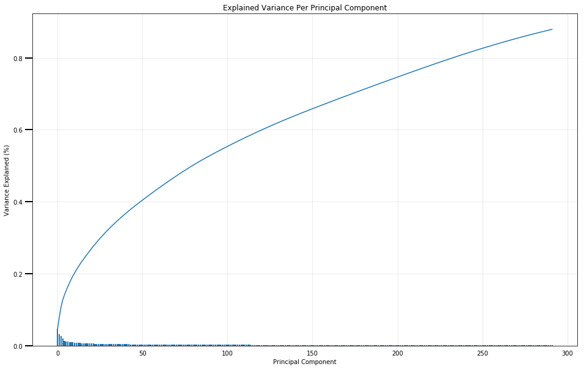

```python
# Investigate the variance accounted for by each principal component.
scree_plot(pca)
```

```python
# Define plot function to check out the ratio of variance explained by each principal component

def plot_variance_ratio(pca):
    '''
    Creates a plot associated with the principal components

    INPUT: pca - the result of instantian of PCA in scikit learn

    OUTPUT:
            None
    '''
    num_components=len(pca.explained_variance_ratio_)
    ind = np.arange(num_components)
    vals = pca.explained_variance_ratio_

    plt.figure(figsize=(16, 10))
    ax = plt.subplot(111)
    #cumvals = np.cumsum(vals)
    ax.bar(ind, vals)
    #ax.plot(ind, cumvals)

    ax.grid()
    ax.set_axisbelow(True)
    ax.grid(linewidth='0.5', alpha=0.5)

    # Printing percentage of variance explained by first 5 components.
    for i in range(ind[5]):
        ax.annotate(r"%s%%" % ((str(vals[i]*100)[:4])), (ind[i]+0.2, vals[i]), va="bottom", ha="center", fontsize=12)

    ax.xaxis.set_tick_params(width=0)
    ax.yaxis.set_tick_params(width=2, length=12)

    ax.set_xlabel("Principal Component")
    ax.set_ylabel("Variance Explained (%)")
    plt.title('Explained Variance Per Principal Component')
```

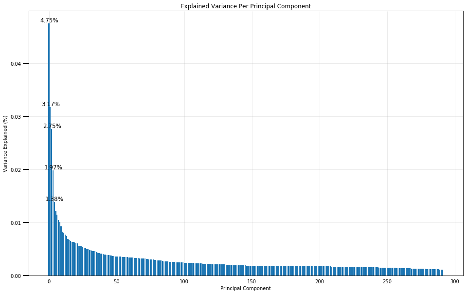

```python
plot_variance_ratio(pca)
```

```python
# Getting cumulative sum of explained variance ratio.
vals = pca.explained_variance_ratio_
cumvals = list(np.cumsum(vals))
for cmv in enumerate(cumvals):
    print(cmv)
```

```
(0, 0.047501779013964317)
(1, 0.079229947998727318)
(2, 0.10679830118313607)
(3, 0.12658950247763434)
(4, 0.14039610969010505)
(5, 0.15246717149125769)
(6, 0.16395714680417875)
(7, 0.17435974829930884)
(8, 0.18441854192660989)
(9, 0.1936769444574615)
(10, 0.20195220007040657)
(11, 0.20996413846230635)
(12, 0.21766193090363067)
(13, 0.2251037445180587)
(14, 0.23194750700804484)
(15, 0.23864925915237759)
(16, 0.24517540077384983)
(17, 0.25150557891098174)
(18, 0.25780418275534805)
(19, 0.2639932422372836)
(20, 0.27013366395421623)
(21, 0.27621384688438361)
(22, 0.28180729964090728)
(23, 0.28739461038846342)
(24, 0.29292414514353143)
(25, 0.29836251084409504)
(26, 0.30359589102491635)
(27, 0.30875232304561812)
(28, 0.31380512060117272)
(29, 0.31869951025802856)
(30, 0.32350560669125927)
(31, 0.32824522054791744)
(32, 0.33284762783006366)
(33, 0.33741416059976742)
(34, 0.34193883378968098)
(35, 0.34636399613772051)
(36, 0.35064827067995991)
(37, 0.35483431398534621)
(38, 0.35894156681880984)
(39, 0.36303255613659247)
```

[output cut: 237 more lines]

```
(277, 0.86245073384744009)
(278, 0.86367384278646364)
(279, 0.86488734331287753)
(280, 0.86609868696599313)
(281, 0.86730088718065634)
(282, 0.86849421686297434)
(283, 0.86968064079516738)
(284, 0.87085223629879993)
(285, 0.87201570135712692)
(286, 0.87316860283067577)
(287, 0.8743132604663032)
(288, 0.87545184855952707)
(289, 0.87657596999131904)
(290, 0.87769140076312235)
(291, 0.87880079362924457)
```

```python
# Define plot function to check out cumulative variance explained by principal components.

def plot_cumulative_variance(pca):
    '''
    Creates a plot associated with the principal components

    INPUT: pca - the result of instantian of PCA in scikit learn

    OUTPUT:
            None
    '''
    num_components=len(pca.explained_variance_ratio_)
    ind = np.arange(num_components)
    vals = pca.explained_variance_ratio_

    plt.figure(figsize=(10, 6))
    ax = plt.subplot(111)
    cumvals = np.cumsum(vals)
    #ax.bar(ind, vals)
    ax.plot(ind, cumvals)

    ax.grid()
    ax.set_axisbelow(True)
    ax.grid(linewidth='0.5', alpha=0.5)

    cumval_ind_hv1 = []
    cumval_ind_hv2 = []
    cumval_ind_hv3 = []
    cumval_ind_hv4 = []
    cumval_ind_hv5 = []
    cumval_ind_hv6 = []
#    cumval_ind_hv7 = []
    for i in enumerate(cumvals):
        if i[1] > 0.3 and i[1] < 0.4:
            cumval_ind_hv1.append(i)
        elif i[1] > 0.4 and i[1] < 0.5:
            cumval_ind_hv2.append(i)
        elif i[1] > 0.5 and i[1] < 0.6:
            cumval_ind_hv3.append(i)
        elif i[1] > 0.6 and i[1] < 0.7:
            cumval_ind_hv4.append(i)
        elif i[1] > 0.7 and i[1] < 0.8:
            cumval_ind_hv5.append(i)
        elif i[1] > 0.8 and i[1] < 0.9:
            cumval_ind_hv6.append(i)
#        elif i[1] > 0.9:
#            cumval_ind_hv7.append(i)

    #print(cumval_ind_hv1[0][0])
    #print(cumval_ind_hv2[0][0])
    #print(cumval_ind_hv3[0][0])
    #print(cumval_ind_hv4[0][0])

    # Plotting horizontal and vertical at points with cumulative variance of 30%, 50%, 60% and 80%.

    plt.hlines(y=0.3, xmin=0, xmax=cumval_ind_hv1[0][0], color='red', linestyles='dashed',zorder=1)
    plt.vlines(x=cumval_ind_hv1[0][0], ymin=0, ymax=0.3, color='red', linestyles='dashed',zorder=2)
    plt.hlines(y=0.4, xmin=0, xmax=cumval_ind_hv2[0][0], color='red', linestyles='dashed',zorder=3)
    plt.vlines(x=cumval_ind_hv2[0][0], ymin=0, ymax=0.4, color='red', linestyles='dashed',zorder=4)
    plt.hlines(y=0.5, xmin=0, xmax=cumval_ind_hv3[0][0], color='red', linestyles='-',zorder=5)
    plt.vlines(x=cumval_ind_hv3[0][0], ymin=0, ymax=0.5, color='red', linestyles='-',zorder=6)
    plt.hlines(y=0.6, xmin=0, xmax=cumval_ind_hv4[0][0], color='red', linestyles='dashed',zorder=7)
    plt.vlines(x=cumval_ind_hv4[0][0], ymin=0, ymax=0.6, color='red', linestyles='dashed',zorder=8)
    plt.hlines(y=0.7, xmin=0, xmax=cumval_ind_hv5[0][0], color='red', linestyles='dashed',zorder=9)
    plt.vlines(x=cumval_ind_hv5[0][0], ymin=0, ymax=0.7, color='red', linestyles='dashed',zorder=10)
    plt.hlines(y=0.8, xmin=0, xmax=cumval_ind_hv6[0][0], color='red', linestyles='dashed',zorder=11)
    plt.vlines(x=cumval_ind_hv6[0][0], ymin=0, ymax=0.8, color='red', linestyles='dashed',zorder=12)
#    plt.hlines(y=0.9, xmin=0, xmax=cumval_ind_hv7[0][0], color='red', linestyles='dashed',zorder=13)
#    plt.vlines(x=cumval_ind_hv7[0][0], ymin=0, ymax=0.9, color='red', linestyles='dashed',zorder=14)

    # Plotting number of components for cumulative variance of 30%, 50%, 60% and 80%.
    for i,v in [cumval_ind_hv1[0], cumval_ind_hv2[0], cumval_ind_hv3[0],\
                cumval_ind_hv4[0], cumval_ind_hv5[0], cumval_ind_hv6[0]]:
        ax.annotate(r"%s" % ((str(i+1))), (i+0.2, np.round(v, 2)), va="bottom", ha="center", fontsize=12)



    ax.xaxis.set_tick_params(width=0)
    ax.yaxis.set_tick_params(width=2, length=12)

    ax.set_xlabel("Principal Component")
    ax.set_ylabel("Variance Explained (%)")
    plt.title('Cumulative Variance of Principal Components')
```

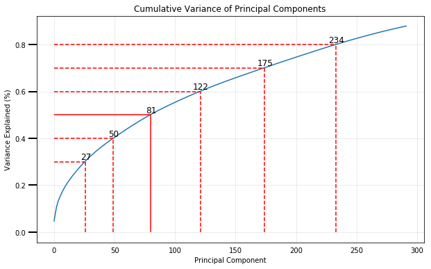

```python
plot_cumulative_variance(pca)
```

```python
# Re-apply PCA to the data while selecting for number of components to retain.
pca_81, azdias_sample_pca = do_pca(81,azdias_sample_scaled)
```

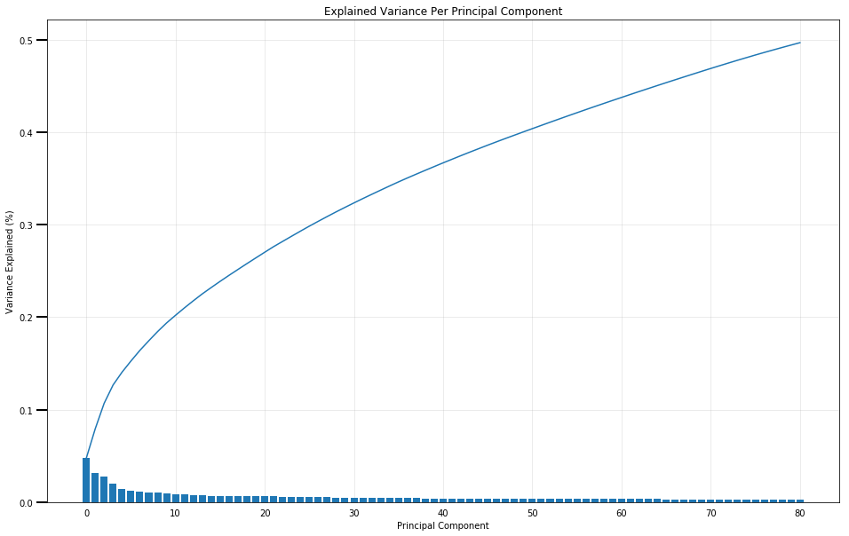

```python
scree_plot(pca_81)
```

#### Discussion 2.2: Perform Dimensionality Reduction

Before performing dimensionality reduction we had 584 features in the dataset which were cleaned, imputed, scaled and ready to use. We passed the features through PCA process to obtain principal components in the directions of maximum variance. We then visualized the explained variance ratio per principal components and cumulative variance ratio of principal components.

From the plot of cumulative variance of principal components, we can observe that with every 10% increase of variance, the number of components required for the same increase kept on increasing i.e. to get 10 % increase from 30% to 40% to 50% to 60% to 70% to 80% of the total variance, it required to increase components from 27 to 50 to 81 to 122 to 175 to 234 which corresponds to increase of 23 to 31 to 41 to 53 to 59 components respectively.

At 81, 122, 175 and 234 principal components, we had 50%, 60%, 70% and 80% of the total variance of the dataset.

So, proceeding with 81 principal components which explains 50% of the total variance in the dataset and should be helpful to much extent in generalizing the customer segments during cluster analysis process.

#### Step 2.3: Interpret Principal Components

Now that we have our transformed principal components, it's a nice idea to check out the weight of each variable on the first few components to see if they can be interpreted in some fashion.

As a reminder, each principal component is a unit vector that points in the direction of highest variance (after accounting for the variance captured by earlier principal components). The further a weight is from zero, the more the principal component is in the direction of the corresponding feature. If two features have large weights of the same sign (both positive or both negative), then increases in one tend expect to be associated with increases in the other. To contrast, features with different signs can be expected to show a negative correlation: increases in one variable should result in a decrease in the other.

- To investigate the features, you should map each weight to their corresponding feature name, then sort the features according to weight. The most interesting features for each principal component, then, will be those at the beginning and end of the sorted list. Use the data dictionary document to help you understand these most prominent features, their relationships, and what a positive or negative value on the principal component might indicate.
- You should investigate and interpret feature associations from the first three principal components in this substep. To help facilitate this, you should write a function that you can call at any time to print the sorted list of feature weights, for the i-th principal component. This might come in handy in the next step of the project, when you interpret the tendencies of the discovered clusters.

```python
# Principal components of pca_81 in feature space, representing the directions of maximum variance in the data.
pca_81.components_
```

```
array([[-0.07006195, -0.01339678,  0.09195306, ...,  0.06582224,
         0.0653326 , -0.08329718],
       [ 0.00785656, -0.01637789,  0.05391194, ..., -0.03058364,
         0.02059239,  0.01232933],
       [ 0.05754929,  0.0242995 ,  0.03125491, ..., -0.05485934,
        -0.1063848 ,  0.08992442],
       ...,
       [-0.01918135, -0.05834385,  0.0194214 , ...,  0.1200575 ,
        -0.00876168,  0.00704499],
       [ 0.0136567 ,  0.0781543 ,  0.01317668, ...,  0.01884484,
         0.00133063,  0.0180403 ],
       [ 0.01346202,  0.0489122 , -0.01763022, ..., -0.10378368,
        -0.03158991,  0.04356361]])
```

```python
# The amount of variance explained by each of the selected component in pca_81.
pca_81.explained_variance_
```

```
array([ 27.74122919,  18.52937776,  16.10002866,  11.55814057,
         8.06311081,   7.04953653,   6.71017753,   6.07513678,
         5.87435334,   5.40686931,   4.83253063,   4.67888112,
         4.49515726,   4.34575767,   3.99617774,   3.91292092,
         3.80990302,   3.69541629,   3.67699421,   3.6127054 ,
         3.58518608,   3.54844775,   3.2650674 ,   3.25973074,
         3.22642987,   3.17361104,   3.04992146,   3.00846071,
         2.94601205,   2.8517137 ,   2.80001441,   2.76065075,
         2.67952574,   2.65095146,   2.63577691,   2.57382348,
         2.48417778,   2.42850534,   2.38334889,   2.36563835,
         2.34180488,   2.2844125 ,   2.27993253,   2.23575078,
         2.19286078,   2.19093971,   2.13639644,   2.10403563,
         2.07361213,   2.06525067,   2.04270912,   2.03914577,
         2.03194014,   2.00608153,   1.99965192,   1.97089468,
         1.96848187,   1.94899244,   1.92415647,   1.91098474,
         1.90470875,   1.89281168,   1.8777681 ,   1.85456512,
         1.8503722 ,   1.83604903,   1.81745406,   1.80341351,
         1.80321841,   1.78080547,   1.77333888,   1.74147609,
         1.72103874,   1.70588008,   1.66610782,   1.65792185,
         1.61513112,   1.58015041,   1.55400136,   1.52926728,   1.51017934])
```

```python
# Percentage of variance explained by each of the selected components in pca_81.
pca_81.explained_variance_ratio_
```

```
array([ 0.04750178,  0.03172817,  0.02756835,  0.0197912 ,  0.0138066 ,
        0.01207104,  0.01148995,  0.01040256,  0.01005876,  0.00925827,
        0.00827482,  0.00801173,  0.00769713,  0.00744131,  0.00684272,
        0.00670016,  0.00652376,  0.00632772,  0.00629618,  0.0061861 ,
        0.00613898,  0.00607607,  0.00559083,  0.00558169,  0.00552467,
        0.00543423,  0.00522243,  0.00515144,  0.00504451,  0.00488304,
        0.00479451,  0.00472711,  0.0045882 ,  0.00453927,  0.00451329,
        0.0044072 ,  0.0042537 ,  0.00415837,  0.00408105,  0.00405072,
        0.00400991,  0.00391164,  0.00390397,  0.00382831,  0.00375487,
        0.00375158,  0.00365819,  0.00360278,  0.00355068,  0.00353636,
        0.00349777,  0.00349166,  0.00347933,  0.00343505,  0.00342404,
        0.0033748 ,  0.00337067,  0.00333729,  0.00329477,  0.00327221,
        0.00326147,  0.00324109,  0.00321533,  0.0031756 ,  0.00316842,
        0.0031439 ,  0.00311206,  0.00308802,  0.00308768,  0.0030493 ,
        0.00303652,  0.00298196,  0.00294696,  0.00292101,  0.0028529 ,
        0.00283889,  0.00276562,  0.00270572,  0.00266094,  0.00261859,
        0.00258591])
```

```python
# Create a dataframe of Explained Variance ratio in pca_81.
dimensions = ['PC {}'.format(i) for i in range(1,len(pca_81.components_)+1)]
ratios = pca_81.explained_variance_ratio_
variance_ratios = pd.DataFrame(np.round(ratios, 4), columns = ['EXPLAINED_VARIANCE RATIO'])
variance_ratios.index = dimensions
```

```python
variance_ratios
```

|  | EXPLAINED_VARIANCE RATIO |
| --- | --- |
| PC 1 | 0.0475 |
| PC 2 | 0.0317 |
| PC 3 | 0.0276 |
| PC 4 | 0.0198 |
| PC 5 | 0.0138 |
| PC 6 | 0.0121 |
| PC 7 | 0.0115 |
| PC 8 | 0.0104 |
| PC 9 | 0.0101 |
| PC 10 | 0.0093 |
| PC 11 | 0.0083 |
| PC 12 | 0.0080 |
| PC 13 | 0.0077 |
| PC 14 | 0.0074 |
| PC 15 | 0.0068 |
| PC 16 | 0.0067 |
| PC 17 | 0.0065 |
| PC 18 | 0.0063 |
| PC 19 | 0.0063 |
| PC 20 | 0.0062 |
| PC 21 | 0.0061 |
| PC 22 | 0.0061 |
| PC 23 | 0.0056 |
| PC 24 | 0.0056 |
| PC 25 | 0.0055 |
| PC 26 | 0.0054 |
| PC 27 | 0.0052 |
| PC 28 | 0.0052 |
| PC 29 | 0.0050 |
| PC 30 | 0.0049 |
| ... | ... |
| PC 52 | 0.0035 |
| PC 53 | 0.0035 |
| PC 54 | 0.0034 |
| PC 55 | 0.0034 |
| PC 56 | 0.0034 |
| PC 57 | 0.0034 |
| PC 58 | 0.0033 |
| PC 59 | 0.0033 |
| PC 60 | 0.0033 |
| PC 61 | 0.0033 |
| PC 62 | 0.0032 |
| PC 63 | 0.0032 |
| PC 64 | 0.0032 |
| PC 65 | 0.0032 |
| PC 66 | 0.0031 |
| PC 67 | 0.0031 |
| PC 68 | 0.0031 |
| PC 69 | 0.0031 |
| PC 70 | 0.0030 |
| PC 71 | 0.0030 |
| PC 72 | 0.0030 |
| PC 73 | 0.0029 |
| PC 74 | 0.0029 |
| PC 75 | 0.0029 |
| PC 76 | 0.0028 |
| PC 77 | 0.0028 |
| PC 78 | 0.0027 |
| PC 79 | 0.0027 |
| PC 80 | 0.0026 |
| PC 81 | 0.0026 |

81 rows × 1 columns

```python
# Create a dataframe with the weights for each principal component in pca_81.
# Map weights for the principal components to corresponding feature names.
components_weights = pd.DataFrame(np.round(pca_81.components_, 4), columns = azdias_sample_scaled.keys())
components_weights.index = dimensions
```

```python
components_weights.head()
```

|  | ANZ_HAUSHALTE_AKTIV | ANZ_HH_TITEL | ANZ_PERSONEN | ANZ_TITEL | ARBEIT | BALLRAUM | D19_BANKEN_DIREKT | D19_BANKEN_GROSS | D19_BANKEN_LOKAL | D19_BANKEN_REST | ... | ZABEOTYP_3 | ZABEOTYP_4 | ZABEOTYP_5 | ZABEOTYP_6 | PRAEGENDE_JUGENDJAHRE_decade | PRAEGENDE_JUGENDJAHRE_movement | CAMEO_INTL_2015_wealth | CAMEO_INTL_2015_life_stage | WOHNLAGE_rural | WOHNLAGE_rating_class |
| --- | --- | --- | --- | --- | --- | --- | --- | --- | --- | --- | --- | --- | --- | --- | --- | --- | --- | --- | --- | --- | --- |
| PC 1 | -0.0701 | -0.0134 | 0.0920 | 0.0051 | -0.0837 | 0.0470 | 0.0609 | 0.0443 | 0.0279 | 0.0512 | ... | -0.0368 | 0.0114 | -0.0409 | -0.0371 | -0.0058 | -0.0799 | -0.1217 | 0.0658 | 0.0653 | -0.0833 |
| PC 2 | 0.0079 | -0.0164 | 0.0539 | -0.0094 | 0.0592 | 0.0355 | 0.0709 | 0.0561 | 0.0186 | 0.0435 | ... | -0.0516 | 0.0552 | 0.0229 | -0.0118 | 0.0628 | 0.0662 | 0.0579 | -0.0306 | 0.0206 | 0.0123 |
| PC 3 | 0.0575 | 0.0243 | 0.0313 | 0.0058 | 0.0335 | -0.1089 | 0.0687 | 0.0585 | 0.0047 | 0.0451 | ... | -0.0790 | 0.0604 | 0.0356 | 0.0005 | 0.0978 | -0.0262 | 0.0562 | -0.0549 | -0.1064 | 0.0899 |
| PC 4 | 0.0294 | 0.0226 | 0.0230 | 0.0122 | 0.0929 | -0.0540 | 0.0084 | 0.0047 | 0.0058 | 0.0129 | ... | 0.1328 | -0.0738 | -0.0872 | -0.0025 | -0.1891 | -0.0561 | 0.0342 | 0.0365 | -0.0767 | 0.0523 |
| PC 5 | -0.0065 | 0.0100 | -0.0172 | 0.0051 | 0.0893 | 0.0362 | -0.0076 | -0.0064 | -0.0067 | -0.0104 | ... | -0.0695 | 0.0203 | 0.0506 | -0.0054 | 0.0789 | -0.0420 | -0.0353 | 0.0749 | -0.0119 | -0.0204 |

5 rows × 584 columns

```python
# Map weights for the first principal component to corresponding feature names
# and then print the linked values, sorted by weight.
# HINT: Try defining a function here or in a new cell that you can reuse in the
# other cells.

# Highest positive and negative weights for the first Principal Componnent

def weights_sorted_p_comp(n_p_comp, n_weights):
    p_comp = 'PC' + ' ' + str(n_p_comp)
    print("Principal Component", (n_p_comp))
    print('-' * 30)
    print("\nTop positive weights are below\n")
    print(components_weights.loc[p_comp].sort_values(ascending=False)[:n_weights])
    print('-' * 30)
    print("\nTop negative weights are below\n")
    print(components_weights.loc[p_comp].sort_values()[:n_weights])
```

```python
# Plot the feature weights as a function of the components
def plot_component_weights(n_p_comp, n_weights):
    '''
    n_p_comp: prinicipal component number
    n_weights: number of top positive and top negative weights
    '''
    p_comp = 'PC' + ' ' + str(n_p_comp)
    comp_weight_first_last = components_weights.loc[p_comp].sort_values(ascending=False)[:n_weights].append(
                                    components_weights.loc[p_comp].sort_values()[:n_weights])

    # Create a bar plot visualization
    fig, ax = plt.subplots(figsize = (10,6))
    comp_weight_first_last.plot(ax = ax, kind = 'bar')

    # Turn on the grid
    ax.grid()

    # Don't allow the axis to be on top of your data
    ax.set_axisbelow(True)

    # Customize the grid
    ax.grid(linewidth='0.5', alpha=0.5)

    #comp_weight_first_last.plot(ax = ax, kind = 'bar')
    ax.set_ylabel("Feature Weights")
    #ax.set_xticklabels(list(comp_weight_first_last.index), rotation='vertical')
    plt.show()
```

```python
# Getting top 5 positive and negative weights of a principal component 1.
weights_sorted_p_comp(1, 5)
```

```
Principal Component 1
------------------------------

Top positive weights are below

MOBI_REGIO        0.1305
KBA05_ANTG1       0.1227
KBA05_AUTOQUOT    0.1189
PLZ8_ANTG1        0.1169
KBA05_GBZ         0.1150
Name: PC 1, dtype: float64
------------------------------

Top negative weights are below

HH_EINKOMMEN_SCORE       -0.1280
CAMEO_INTL_2015_wealth   -0.1217
LP_STATUS_GROB_1.0       -0.1182
PLZ8_ANTG3               -0.1145
D19_GESAMT_ANZ_24_0      -0.1105
Name: PC 1, dtype: float64
```

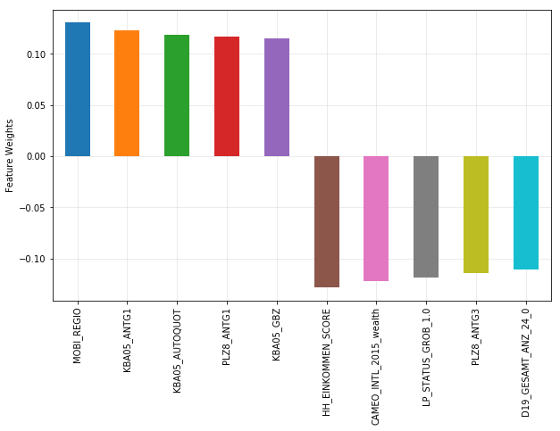

```python
# Plotting the top 5 positive and negative weights of a principal component 1.
plot_component_weights(1, 5)
```

```python
# Map weights for the second principal component to corresponding feature names
# and then print the linked values, sorted by weight.

# Getting top 5 positive and negative weights of a principal component 2.
weights_sorted_p_comp(2, 5)
```

```
Principal Component 2
------------------------------

Top positive weights are below

KBA13_SITZE_5           0.1181
KBA13_SEG_KLEINWAGEN    0.1081
KBA13_KMH_140_210       0.1036
KBA13_KMH_180           0.1025
KBA13_HALTER_25         0.1006
Name: PC 2, dtype: float64
------------------------------

Top negative weights are below

KBA13_HERST_BMW_BENZ          -0.1415
KBA13_MERCEDES                -0.1235
KBA13_SEG_OBEREMITTELKLASSE   -0.1180
KBA13_BMW                     -0.1148
KBA13_SEG_SPORTWAGEN          -0.1095
Name: PC 2, dtype: float64
```

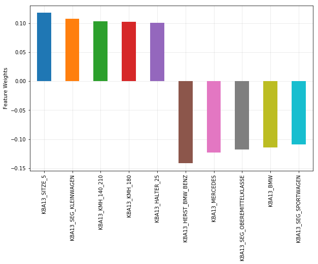

```python
# Plotting the top 5 positive and negative weights of a principal component 2.
plot_component_weights(2, 5)
```

```python
# Map weights for the third principal component to corresponding feature names
# and then print the linked values, sorted by weight.

# Getting top 5 positive and negative weights of a principal component 3.
weights_sorted_p_comp(3, 5)
```

```
Principal Component 3
------------------------------

Top positive weights are below

EWDICHTE                       0.1446
ORTSGR_KLS9                    0.1387
KBA13_HERST_BMW_BENZ           0.1191
PLZ8_ANTG3                     0.1085
KBA13_SEG_OBEREMITTELKLASSE    0.1083
Name: PC 3, dtype: float64
------------------------------

Top negative weights are below

KBA13_ALTERHALTER_60   -0.1316
KBA13_HALTER_55        -0.1196
KBA13_AUTOQUOTE        -0.1163
KBA13_HALTER_50        -0.1139
INNENSTADT             -0.1121
Name: PC 3, dtype: float64
```

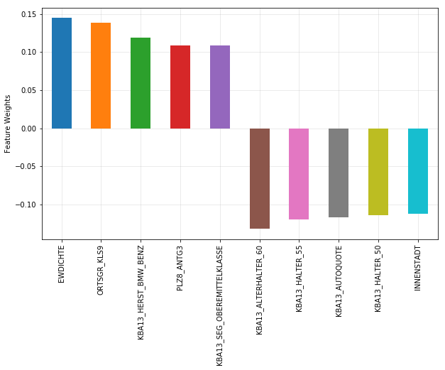

```python
# Plotting the top 5 positive and negative weights of a principal component 3.
plot_component_weights(3, 5)
```

#### Discussion 2.3: Interpret Principal Components

Each component is a combination of the 584 features left after cleaning, with each feature given a weight relative to its importance for a particular principal component. The higher the weight either positive or negative, the more impact the feature has on the calculation of the principal component. What value of weight is important is subjective and depends on the context.

We have taken the top 5 highest postive weights and negative weights to interpret the first 3 principal components.

The first principal component has positive weights with features mentioned below:

- MOBI_REGIO - Movement patterns(higher is lower movement)
- KBA05_ANTG1 - Number of 1-2 family houses in the microcell(higher is higher share)
- KBA05_AUTOQUOT - Share of cars per household(higher is higher quote)
- PLZ8_ANTG1 - Number of 1-2 family houses in the PLZ8 region(higher is higher share)
- KBA05_GBZ - Number of buildings in the microcell(higher is more buildings)

The first principal component has negative weights with features mentioned below:

- HH_EINKOMMEN_SCORE - Estimated household net income(higher is lower income)
- CAMEO_INTL_2015_wealth - Household Wealth Typology(Household wealth (higher is lower household or income)
- LP_STATUS_GROB_1.0 - Social status rough(higher is higher earner)
- PLZ8_ANTG3 - Number of 6-10 family houses in the PLZ8 region(higher is higher number)
- D19_GESAMT_ANZ_24_0 - Transaction activity TOTAL POOL in the last 24 months(higher is higher activity)

The second principal component have positive weights with features mentioned below:

- KBA13_SITZE_5 - number of cars with 5 seats(higher is higher)
- KBA13_SEG_KLEINWAGEN - share of small and very small cars(higher is higher)
- KBA13_KMH_140_210 - share of cars with max speed between 140 and 210 km/h(higher is higher)
- KBA13_KMH_180 - share of cars with max speed between 110 km/h and 180km/h(higher is higher)
- KBA13_HALTER_25 - share of car owners between 21 and 25(higher is higher)

The second principal component have negative weights with features mentioned below:

- KBA13_HERST_BMW_BENZ - share of BMW & Mercedes Benz(higher is higher)
- KBA13_MERCEDES - share of MERCEDES(higher is higher)
- KBA13_SEG_OBEREMITTELKLASSE - share of upper middle class cars and upper class cars(higher is higher)
- KBA13_BMW - share of BMW(higher is higher)
- KBA13_SEG_SPORTWAGEN - share of sportscars(higher is higher)

The second principal component seems to be representing a combination of features related to share of different types of cars in an area & share of car owners. Positive correlations with number of cars having 5 seats which are small in size with maximum speed between 110 to 210 Km/h and share of car owners between 21 and 25 and neagtive correlations with share of upper middle class and upper class cars like BMW, Mercedes Benz & sports cars. It appers that second principal component is related to share of different types of cars in an area and share of number of car owners in an area.

The third principal component have positive weights with features mentioned below:

- EWDICHTE - Density of households per square kilometer(higher is higher density)
- ORTSGR_KLS9 - Size of community(higher is higher size)
- KBA13_HERST_BMW_BENZ - share of BMW & Mercedes Benz(higher is higher)
- PLZ8_ANTG3 - Number of 6-10 family houses in the PLZ8 region(higher is higher number)
- KBA13_SEG_OBEREMITTELKLASSE - share of upper middle class cars and upper class cars(higher is higher)

The third principal component have negative weights with features mentioned below:

- KBA13_ALTERHALTER_60 - share of car owners between 46 and 60(higher is higher)
- KBA13_HALTER_55 - share of car owners between 51 and 55(higher is higher)
- KBA13_AUTOQUOTE - share of cars per household(higher is higher)
- KBA13_HALTER_50 - share of car owners between 46 and 50(higher is higher)
- INNENSTADT - distance to the city centre(higher is higher distance)

### Step 3: Clustering

#### Step 3.1: Apply Clustering to General Population

You've assessed and cleaned the demographics data, then scaled and transformed them. Now, it's time to see how the data clusters in the principal components space. In this substep, you will apply k-means clustering to the dataset and use the average within-cluster distances from each point to their assigned cluster's centroid to decide on a number of clusters to keep.

- Use sklearn's KMeans class to perform k-means clustering on the PCA-transformed data.
- Then, compute the average difference from each point to its assigned cluster's center. **Hint**: The KMeans object's `.score()` method might be useful here, but note that in sklearn, scores tend to be defined so that larger is better. Try applying it to a small, toy dataset, or use an internet search to help your understanding.
- Perform the above two steps for a number of different cluster counts. You can then see how the average distance decreases with an increasing number of clusters. However, each additional cluster provides a smaller net benefit. Use this fact to select a final number of clusters in which to group the data. **Warning**: because of the large size of the dataset, it can take a long time for the algorithm to resolve. The more clusters to fit, the longer the algorithm will take. You should test for cluster counts through at least 10 clusters to get the full picture, but you shouldn't need to test for a number of clusters above about 30.
- Once you've selected a final number of clusters to use, re-fit a KMeans instance to perform the clustering operation. Make sure that you also obtain the cluster assignments for the general demographics data, since you'll be using them in the final Step 3.3.

```python
# Printing type of azdias_sample_pca
type(azdias_sample_pca)
```

```
numpy.ndarray
```

```python
# Printing shape of azdias_sample_pca
azdias_sample_pca.shape
```

```
(145818, 81)
```

```python
def get_kmeans_score(data, center):
    '''
    returns the kmeans score regarding SSE for points to centers
    INPUT:
        data - the dataset you want to fit kmeans to
        center - the number of centers you want (the k value)
    OUTPUT:
        score - the SSE score for the kmeans model fit to the data
    '''
    #instantiate kmeans
    kmeans = KMeans(n_clusters=center)

    # Then fit the model to your data using the fit method
    model = kmeans.fit(data)

    # Obtain a score related to the model fit
    score = np.abs(model.score(data))

    return score
```

```python
# Over a number of different cluster counts...
# run k-means clustering on the data and...
# compute the average within-cluster distances.

scores = []
centers = list(range(2,26,1))

for center in centers:
    score = round(get_kmeans_score(azdias_sample_pca, center),2)
    print('center : {}     score : {}'.format(center, score))
    scores.append(score)
```

```
center : 2     score : 39482851.13
center : 3     score : 37962147.96
center : 4     score : 37067880.99
center : 5     score : 36355974.88
center : 6     score : 35800760.58
center : 7     score : 35333622.52
center : 8     score : 34962729.8
center : 9     score : 34613722.37
center : 10     score : 34294979.73
center : 11     score : 34021638.29
center : 12     score : 33695323.54
center : 13     score : 33394807.74
center : 14     score : 33248505.83
center : 15     score : 32938046.41
center : 16     score : 32760775.21
center : 17     score : 32551000.0
center : 18     score : 32319416.44
center : 19     score : 32123502.95
center : 20     score : 31985244.51
center : 21     score : 31689567.74
center : 22     score : 31573636.43
center : 23     score : 31392697.43
center : 24     score : 31200093.9
center : 25     score : 31057894.35
```

```python
# Create dataframe showing the average point-centroid distances
scores_ds = pd.Series(scores).round(2)
centers_ds = pd.Series(centers)
average_distance = np.array(scores)/azdias_sample_pca.shape[0]
average_distance_ds = pd.Series(average_distance).round(2)

scores_df = pd.concat([centers_ds, scores_ds, average_distance_ds],axis=1)
scores_df.columns = ['clusters','score','average_distance']
scores_df.set_index('clusters',inplace=True)
#scores_df['score'] = scores_df['score'].round(2)
scores_df
```

| clusters | score | average_distance |
| --- | --- | --- |
| 2 | 39482851.13 | 270.77 |
| 3 | 37962147.96 | 260.34 |
| 4 | 37067880.99 | 254.21 |
| 5 | 36355974.88 | 249.32 |
| 6 | 35800760.58 | 245.52 |
| 7 | 35333622.52 | 242.31 |
| 8 | 34962729.80 | 239.77 |
| 9 | 34613722.37 | 237.38 |
| 10 | 34294979.73 | 235.19 |
| 11 | 34021638.29 | 233.32 |
| 12 | 33695323.54 | 231.08 |
| 13 | 33394807.74 | 229.02 |
| 14 | 33248505.83 | 228.01 |
| 15 | 32938046.41 | 225.88 |
| 16 | 32760775.21 | 224.67 |
| 17 | 32551000.00 | 223.23 |
| 18 | 32319416.44 | 221.64 |
| 19 | 32123502.95 | 220.30 |
| 20 | 31985244.51 | 219.35 |
| 21 | 31689567.74 | 217.32 |
| 22 | 31573636.43 | 216.53 |
| 23 | 31392697.43 | 215.29 |
| 24 | 31200093.90 | 213.97 |
| 25 | 31057894.35 | 212.99 |

```python
# Save checkpoint
#scores_df.to_csv('scores_checkpoint.csv', encoding='utf-8',index=False)
scores_df.to_csv('scores_checkpoint.csv', encoding='utf-8')
```

```python
# Load scores_checkpoint.csv
scores_df = pd.read_csv('scores_checkpoint.csv')
scores_df.set_index('clusters',inplace=True)
scores_df
```

| clusters | score | average_distance |
| --- | --- | --- |
| 2 | 39482851.13 | 270.77 |
| 3 | 37962147.96 | 260.34 |
| 4 | 37067880.99 | 254.21 |
| 5 | 36355974.88 | 249.32 |
| 6 | 35800760.58 | 245.52 |
| 7 | 35333622.52 | 242.31 |
| 8 | 34962729.80 | 239.77 |
| 9 | 34613722.37 | 237.38 |
| 10 | 34294979.73 | 235.19 |
| 11 | 34021638.29 | 233.32 |
| 12 | 33695323.54 | 231.08 |
| 13 | 33394807.74 | 229.02 |
| 14 | 33248505.83 | 228.01 |
| 15 | 32938046.41 | 225.88 |
| 16 | 32760775.21 | 224.67 |
| 17 | 32551000.00 | 223.23 |
| 18 | 32319416.44 | 221.64 |
| 19 | 32123502.95 | 220.30 |
| 20 | 31985244.51 | 219.35 |
| 21 | 31689567.74 | 217.32 |
| 22 | 31573636.43 | 216.53 |
| 23 | 31392697.43 | 215.29 |
| 24 | 31200093.90 | 213.97 |
| 25 | 31057894.35 | 212.99 |

```python
# Create list of centers, scores, avg_point_centroid_dist
centers =  list(scores_df.index)
scores = scores_df['score'].values.tolist()
avg_point_centroid_dist = scores_df['average_distance'].values.tolist()
```

```python
print(type(centers))
print(type(scores))
print(type(list(avg_point_centroid_dist)))
```

```
<class 'list'>
<class 'list'>
<class 'list'>
```

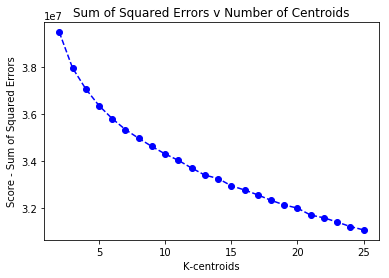

```python
# Investigate the change in sse across number of clusters.
# HINT: Use matplotlib's plot function to visualize this relationship.
plt.plot(centers, scores, linestyle='--', marker='o', color='b');
plt.xlabel('K-centroids');
plt.ylabel('Score - Sum of Squared Errors');
plt.title('Sum of Squared Errors v Number of Centroids');
```

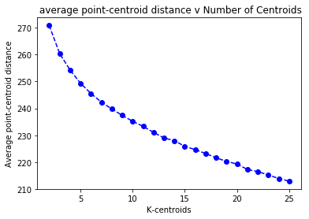

```python
# Investigate the change in within-cluster distance across number of clusters.
# HINT: Use matplotlib's plot function to visualize this relationship.
plt.plot(centers, avg_point_centroid_dist, linestyle='--', marker='o', color='b');
plt.xlabel('K-centroids');
plt.ylabel('Average point-centroid distance');
plt.title(' average point-centroid distance v Number of Centroids');
```

```python
# Re-fit the k-means model with the selected number of clusters and obtain
# cluster predictions for the general population demographics data.


#instantiate kmeans
kmeans_10 = KMeans(n_clusters=10, n_init=10, max_iter=300, random_state=42)

# Then fit the model to your data using the fit method
model_general = kmeans_10.fit(azdias_sample_pca)

# Finally predict the labels or clusters on the same data using the predict method
predict_general_clusters = model_general.predict(azdias_sample_pca)
```

```python
# Print clusters for first 5 observations in azdias_sample_pca
predict_general_clusters[:5]
```

```
array([9, 1, 7, 5, 0], dtype=int32)
```

```python
# Total number of predictions for sample general population data
len(predict_general_clusters)
```

```
145818
```

```python
# Total number of unique clusters in sample general population data
np.unique(predict_general_clusters)
```

```
array([0, 1, 2, 3, 4, 5, 6, 7, 8, 9], dtype=int32)
```

```python
# Distribution of general population sample data in clusters
pd.Series(predict_general_clusters).value_counts().sort_index()
```

```
0    15254
1     8535
2    17921
3    17427
4    14399
5    16451
6    10803
7    13391
8    16627
9    15010
dtype: int64
```

#### Discussion 3.1: Apply Clustering to General Population

From the above plot of score(SSE) vs. K-centroids, we can observe that the average within-cluster distances from each point to their assigned cluster's centroid decreases with increasing number of clusters. However, the rate of change of slope decreases with additional cluster i.e. each additional cluster provides a smaller net benefit.

Running the K-Means algorithm with 81 principal components didn't provided any defined and clear "elbow". Possible cluster candidates are 6, 7, 10, 11, 16, 17, 20 and 21 depending if you take a high "elbow" at 6 or 7 clusters, "middle" elbow at 10 or 11 clusters or low "elbow" at 16 or 17 clusters.

The rate of change of slope was substantial till 7 clusters and starts to be consistent around 7 clusters and additional clusters later on provided a smaller net benefit. In general, lower number of clusters could provide more equal distribution in the population clustering of the dataset, whereas a higher number of clusters could result in the population clustering having some wide differences between counts allocated to clusters. Keeping the above points in mind, we could take 10 clusters as a choice to segment the population generally.

#### Step 3.2: Apply All Steps to the Customer Data

Now that you have clusters and cluster centers for the general population, it's time to see how the customer data maps on to those clusters. Take care to not confuse this for re-fitting all of the models to the customer data. Instead, you're going to use the fits from the general population to clean, transform, and cluster the customer data. In the last step of the project, you will interpret how the general population fits apply to the customer data.

- Don't forget when loading in the customers data, that it is semicolon (`;`) delimited.
- Apply the same feature wrangling, selection, and engineering steps to the customer demographics using the `clean_data()` function you created earlier. (You can assume that the customer demographics data has similar meaning behind missing data patterns as the general demographics data.)
- Use the sklearn objects from the general demographics data, and apply their transformations to the customers data. That is, you should not be using a `.fit()` or `.fit_transform()` method to re-fit the old objects, nor should you be creating new sklearn objects! Carry the data through the feature scaling, PCA, and clustering steps, obtaining cluster assignments for all of the data in the customer demographics data.

```python
# Shape of customers df after removal of 3 extra columns
customers.shape
```

```
(191652, 366)
```

```python
# Apply preprocessing, feature transformation, and clustering from the general
# demographics onto the customer data, obtaining cluster predictions for the
# customer demographics data.

# Clean Customers subset file.
customers_cleaned = clean_data(customers)
```

```python
# Print type of customers_cleaned
type(customers_cleaned)
```

```
pandas.core.frame.DataFrame
```

```python
# Shape of customers demographic dataset after cleaning
customers_cleaned.shape
```

```
(130661, 584)
```

```python
# Checking if columns of customers_cleaned and azdias_sample are same or not
len(set(customers_cleaned.columns).intersection(azdias_sample.columns))
```

```
584
```

From above, we observe that customers_cleaned dataframe and azdias_sample dataframe has equal and same number of columns.

```python
# Impute nans with mode value in customers_cleaned dataframe
# Apply imputer to transform customer dataframe
customers_cleaned_imputed = imputer.transform(customers_cleaned)
print('Type of customers_cleaned_imputed is : {}'.format(type(customers_cleaned_imputed)))

# Making customers_cleaned_imputed into a dataframe
customers_cleaned_imputed = pd.DataFrame(customers_cleaned_imputed)
print('Type of customers_cleaned_imputed now is : {}'.format(type(customers_cleaned_imputed)))
customers_cleaned_imputed.head()
```

```
Type of customers_cleaned_imputed is : <class 'numpy.ndarray'>
Type of customers_cleaned_imputed now is : <class 'pandas.core.frame.DataFrame'>
```

|  | 0 | 1 | 2 | 3 | 4 | 5 | 6 | 7 | 8 | 9 | ... | 574 | 575 | 576 | 577 | 578 | 579 | 580 | 581 | 582 | 583 |
| --- | --- | --- | --- | --- | --- | --- | --- | --- | --- | --- | --- | --- | --- | --- | --- | --- | --- | --- | --- | --- | --- |
| 0 | 1.0 | 0.0 | 2.0 | 0.0 | 1.0 | 3.0 | 0.0 | 0.0 | 0.0 | 0.0 | ... | 1.0 | 0.0 | 0.0 | 0.0 | 2.0 | 0.0 | 1.0 | 3.0 | 1.0 | 0.0 |
| 1 | 1.0 | 0.0 | 1.0 | 0.0 | 3.0 | 7.0 | 0.0 | 0.0 | 0.0 | 0.0 | ... | 1.0 | 0.0 | 0.0 | 0.0 | 2.0 | 0.0 | 3.0 | 4.0 | 0.0 | 2.0 |
| 2 | 1.0 | 0.0 | 0.0 | 0.0 | 1.0 | 7.0 | 0.0 | 0.0 | 0.0 | 0.0 | ... | 0.0 | 0.0 | 0.0 | 0.0 | 1.0 | 1.0 | 2.0 | 4.0 | 1.0 | 0.0 |
| 3 | 7.0 | 0.0 | 4.0 | 0.0 | 3.0 | 3.0 | 5.0 | 0.0 | 3.0 | 0.0 | ... | 0.0 | 0.0 | 0.0 | 0.0 | 4.0 | 1.0 | 4.0 | 1.0 | 0.0 | 3.0 |
| 4 | 1.0 | 0.0 | 2.0 | 0.0 | 3.0 | 7.0 | 0.0 | 0.0 | 0.0 | 0.0 | ... | 0.0 | 0.0 | 0.0 | 0.0 | 2.0 | 0.0 | 3.0 | 4.0 | 0.0 | 1.0 |

5 rows × 584 columns

```python
# Checking the sum of all misisng values in the customers_cleaned_imputed.
# It should be 0 as we have already imputed the missing value with mode value.
sum(customers_cleaned_imputed.isnull().sum(axis=1))
```

```
0
```

```python
# Apply feature scaling to the customers demographics data.
# Apply scaler to transform customer dataframe

customers_scaled = scaler.transform(customers_cleaned_imputed)
print('Type of customers_scaled is : {}'.format(type(customers_scaled)))

# Making azdias_scaled into a dataframe
customers_scaled = pd.DataFrame(customers_scaled, columns= list(customers_cleaned.columns.values))
print('Type of customers_scaled now is : {}'.format(type(customers_scaled)))
customers_scaled.head()
```

```
Type of customers_scaled is : <class 'numpy.ndarray'>
Type of customers_scaled now is : <class 'pandas.core.frame.DataFrame'>
```

|  | ANZ_HAUSHALTE_AKTIV | ANZ_HH_TITEL | ANZ_PERSONEN | ANZ_TITEL | ARBEIT | BALLRAUM | D19_BANKEN_DIREKT | D19_BANKEN_GROSS | D19_BANKEN_LOKAL | D19_BANKEN_REST | ... | ZABEOTYP_3 | ZABEOTYP_4 | ZABEOTYP_5 | ZABEOTYP_6 | PRAEGENDE_JUGENDJAHRE_decade | PRAEGENDE_JUGENDJAHRE_movement | CAMEO_INTL_2015_wealth | CAMEO_INTL_2015_life_stage | WOHNLAGE_rural | WOHNLAGE_rating_class |
| --- | --- | --- | --- | --- | --- | --- | --- | --- | --- | --- | --- | --- | --- | --- | --- | --- | --- | --- | --- | --- | --- |
| 0 | -0.474852 | -0.123417 | 0.220156 | -0.062039 | -2.195637 | -0.521179 | -0.467054 | -0.361868 | -0.135111 | -0.293792 | ... | 1.352162 | -0.599071 | -0.337095 | -0.314214 | -1.609760 | -1.864910 | -1.558050 | 0.088621 | 1.825189 | -1.491173 |
| 1 | -0.474852 | -0.123417 | -0.637724 | -0.062039 | -0.182866 | 1.307524 | -0.467054 | -0.361868 | -0.135111 | -0.293792 | ... | 1.352162 | -0.599071 | -0.337095 | -0.314214 | -1.609760 | -1.864910 | -0.194538 | 0.758950 | -0.547889 | -0.259850 |
| 2 | -0.474852 | -0.123417 | -1.495603 | -0.062039 | -2.195637 | 1.307524 | -0.467054 | -0.361868 | -0.135111 | -0.293792 | ... | -0.739556 | -0.599071 | -0.337095 | -0.314214 | -2.292812 | 0.536219 | -0.876294 | 0.758950 | 1.825189 | -1.491173 |
| 3 | -0.079518 | -0.123417 | 1.935915 | -0.062039 | -0.182866 | -0.521179 | 1.931309 | -0.361868 | 3.490722 | -0.293792 | ... | -0.739556 | -0.599071 | -0.337095 | -0.314214 | -0.243657 | 0.536219 | 0.487218 | -1.252036 | -0.547889 | 0.355811 |
| 4 | -0.474852 | -0.123417 | 0.220156 | -0.062039 | -0.182866 | 1.307524 | -0.467054 | -0.361868 | -0.135111 | -0.293792 | ... | -0.739556 | -0.599071 | -0.337095 | -0.314214 | -1.609760 | -1.864910 | -0.194538 | 0.758950 | -0.547889 | -0.875512 |

5 rows × 584 columns

```python
# Apply PCA to the customers_scaled data
# Apply general population Principal Component transformation on customers_scaled dataframe

customers_pca = pca_81.transform(customers_scaled)
```

```python
type(customers_pca)
```

```
numpy.ndarray
```

```python
# Shape of customers_pca
customers_pca.shape
```

```
(130661, 81)
```

```python
# Apply fitted kmeans object from general population demographics onto the customer data,
# obtaining cluster predictions for the customer demographics data.

predict_customers_clusters = model_general.predict(customers_pca)
```

```python
# Print clusters for first 5 observations in clustomers_cleaned
predict_customers_clusters[:5]
```

```
array([9, 6, 3, 1, 6], dtype=int32)
```

```python
# Total number of predictions for customers_cleaned data
len(predict_customers_clusters)
```

```
130661
```

```python
# Total number of unique clusters in customers_cleaned data
np.unique(predict_customers_clusters)
```

```
array([0, 1, 2, 3, 4, 5, 6, 7, 8, 9], dtype=int32)
```

```python
# Distribution of customers_cleaned data in clusters
pd.Series(predict_customers_clusters).value_counts().sort_index()
```

```
0     1381
1     8818
2    13566
3    19343
4     3538
5    21371
6    11085
7     4542
8      815
9    46202
dtype: int64
```

#### Step 3.3: Compare Customer Data to Demographics Data

At this point, you have clustered data based on demographics of the general population of Germany, and seen how the customer data for a mail-order sales company maps onto those demographic clusters. In this final substep, you will compare the two cluster distributions to see where the strongest customer base for the company is.

Consider the proportion of persons in each cluster for the general population, and the proportions for the customers. If we think the company's customer base to be universal, then the cluster assignment proportions should be fairly similar between the two. If there are only particular segments of the population that are interested in the company's products, then we should see a mismatch from one to the other. If there is a higher proportion of persons in a cluster for the customer data compared to the general population (e.g. 5% of persons are assigned to a cluster for the general population, but 15% of the customer data is closest to that cluster's centroid) then that suggests the people in that cluster to be a target audience for the company. On the other hand, the proportion of the data in a cluster being larger in the general population than the customer data (e.g. only 2% of customers closest to a population centroid that captures 6% of the data) suggests that group of persons to be outside of the target demographics.

Take a look at the following points in this step:

- Compute the proportion of data points in each cluster for the general population and the customer data. Visualizations will be useful here: both for the individual dataset proportions, but also to visualize the ratios in cluster representation between groups. Seaborn's `countplot()` or `barplot()` function could be handy.
- Recall the analysis you performed in step 1.1.3 of the project, where you separated out certain data points from the dataset if they had more than a specified threshold of missing values. If you found that this group was qualitatively different from the main bulk of the data, you should treat this as an additional data cluster in this analysis. Make sure that you account for the number of data points in this subset, for both the general population and customer datasets, when making your computations!
- Which cluster or clusters are overrepresented in the customer dataset compared to the general population? Select at least one such cluster and infer what kind of people might be represented by that cluster. Use the principal component interpretations from step 2.3 or look at additional components to help you make this inference. Alternatively, you can use the `.inverse_transform()` method of the PCA and StandardScaler objects to transform centroids back to the original data space and interpret the retrieved values directly.
- Perform a similar investigation for the underrepresented clusters. Which cluster or clusters are underrepresented in the customer dataset compared to the general population, and what kinds of people are typified by these clusters?

```python
# Compare the proportion of data in each cluster for the customer data to the
# proportion of data in each cluster for the general population.

# Number of data points within each general population cluster.
population_clusters = pd.Series(predict_general_clusters)
count_pc = population_clusters.value_counts().sort_index()
print(type(count_pc))
count_pc
```

```
<class 'pandas.core.series.Series'>
```

```
0    15254
1     8535
2    17921
3    17427
4    14399
5    16451
6    10803
7    13391
8    16627
9    15010
dtype: int64
```

```python
# Number of data points within each customers cluster.
customers_clusters = pd.Series(predict_customers_clusters)
count_cc = customers_clusters.value_counts().sort_index()
print(type(count_cc))
count_cc
```

```
<class 'pandas.core.series.Series'>
```

```
0     1381
1     8818
2    13566
3    19343
4     3538
5    21371
6    11085
7     4542
8      815
9    46202
dtype: int64
```

```python
# Create a dataframe from counts of data points within each population and customer clusters.
pop_cust_clusters_data_count_df = pd.concat([count_pc, count_cc], axis=1).reset_index()
pop_cust_clusters_data_count_df.columns = ['cluster', 'population', 'customer']
#pop_cust_clusters_data_count_df.index.name = 'cluster'
pop_cust_clusters_data_count_df
```

|  | cluster | population | customer |
| --- | --- | --- | --- |
| 0 | 0 | 15254 | 1381 |
| 1 | 1 | 8535 | 8818 |
| 2 | 2 | 17921 | 13566 |
| 3 | 3 | 17427 | 19343 |
| 4 | 4 | 14399 | 3538 |
| 5 | 5 | 16451 | 21371 |
| 6 | 6 | 10803 | 11085 |
| 7 | 7 | 13391 | 4542 |
| 8 | 8 | 16627 | 815 |
| 9 | 9 | 15010 | 46202 |

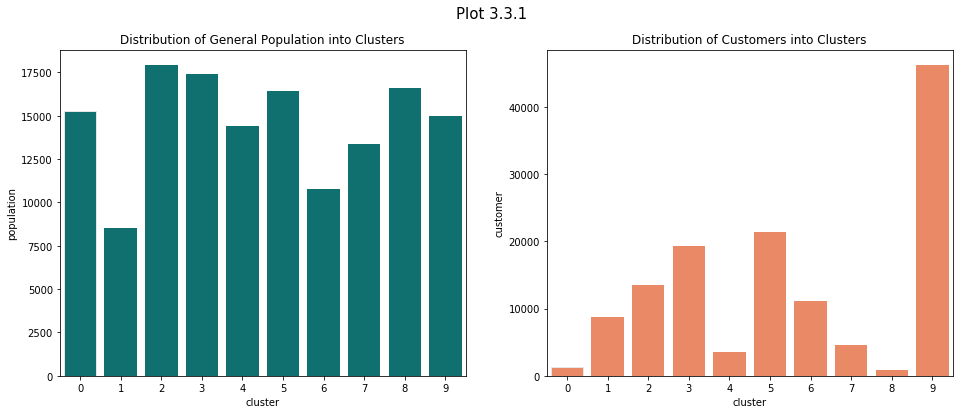

```python
# Visualize dataframe as bar charts
fig = plt.figure(figsize=(16,6))

ax1 = fig.add_subplot(1,2,1)
ax1 = sns.barplot(x=pop_cust_clusters_data_count_df['cluster'],\
                  y=pop_cust_clusters_data_count_df['population'],\
                  color='teal',edgecolor='.9')
plt.title("Distribution of General Population into Clusters")

ax2 = fig.add_subplot(1,2,2)
ax2 = sns.barplot(x=pop_cust_clusters_data_count_df['cluster'],\
                  y=pop_cust_clusters_data_count_df['customer'],\
                  color='coral',edgecolor='.9')

plt.title("Distribution of Customers into Clusters")
plt.suptitle("Plot 3.3.1", fontsize=15);
```

```python
# Add ratio and ratio difference for each cluster to the dataframe
pop_cust_clusters_data_count_df['pop_%'] = (pop_cust_clusters_data_count_df['population']\
                                            /pop_cust_clusters_data_count_df['population'].sum()*100).round(2)
pop_cust_clusters_data_count_df['cust_%'] = (pop_cust_clusters_data_count_df['customer']\
                                             /pop_cust_clusters_data_count_df['customer'].sum()*100).round(2)
pop_cust_clusters_data_count_df['diff'] = pop_cust_clusters_data_count_df['cust_%'] - pop_cust_clusters_data_count_df['pop_%']
pop_cust_clusters_data_count_df
```

|  | cluster | population | customer | pop_% | cust_% | diff |
| --- | --- | --- | --- | --- | --- | --- |
| 0 | 0 | 15254 | 1381 | 10.46 | 1.06 | -9.40 |
| 1 | 1 | 8535 | 8818 | 5.85 | 6.75 | 0.90 |
| 2 | 2 | 17921 | 13566 | 12.29 | 10.38 | -1.91 |
| 3 | 3 | 17427 | 19343 | 11.95 | 14.80 | 2.85 |
| 4 | 4 | 14399 | 3538 | 9.87 | 2.71 | -7.16 |
| 5 | 5 | 16451 | 21371 | 11.28 | 16.36 | 5.08 |
| 6 | 6 | 10803 | 11085 | 7.41 | 8.48 | 1.07 |
| 7 | 7 | 13391 | 4542 | 9.18 | 3.48 | -5.70 |
| 8 | 8 | 16627 | 815 | 11.40 | 0.62 | -10.78 |
| 9 | 9 | 15010 | 46202 | 10.29 | 35.36 | 25.07 |

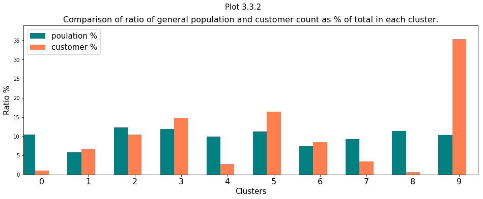

```python
# Visualize ratios for each cluster

fig = plt.figure(figsize=(16,6))

ax = fig.add_subplot(111)

ax = pop_cust_clusters_data_count_df['pop_%'].plot(x=pop_cust_clusters_data_count_df['cluster'], kind='bar',\
                                                   color='teal',width=-0.3, align='edge',position=0)
ax = pop_cust_clusters_data_count_df['cust_%'].plot(x=pop_cust_clusters_data_count_df['cluster'], kind='bar',\
                                                    color='coral',width = 0.3, align='edge',position=1)

ax.margins(x=0.5,y=0.1)
ax.set_xlabel('Clusters', fontsize=15)
ax.set_ylabel('Ratio %', fontsize=15)
ax.xaxis.set(ticklabels= pop_cust_clusters_data_count_df['cluster'])
ax.tick_params(axis = 'x', which = 'major', labelsize = 16)
plt.xticks(rotation=360,)

plt.legend(('poulation %', 'customer %'),fontsize=15)
plt.title(('Comparison of ratio of general population and customer count as % of total in each cluster.')
          ,fontsize=16)

plt.subplots_adjust(bottom=0.2)
plt.suptitle("Plot 3.3.2", fontsize=15)
plt.show()
```

```python
# General population data with missing values in row(rows with more than 8 missing values)
azdias_null_data_row_high.shape[0]
```

```
162135
```

```python
# Taking 20% of the missing rows from population dataset as our sample is 20% of the population
# dataset with 8 or less than 8 missing values
round(azdias_null_data_row_high.shape[0]*.20)
```

```
32427
```

```python
# Missing rows from customer dataset
customers_null_data_row_few = customers[customers.isnull().sum(axis=1) < 9].reset_index(drop=True)
customers_null_data_row_high = customers[customers.isnull().sum(axis=1) >= 9].reset_index(drop=True)
```

```python
customers.shape[0]
```

```
191652
```

```python
customers_null_data_row_high.shape[0]
```

```
60991
```

```python
customers_null_data_row_few.shape[0] + customers_null_data_row_high.shape[0]
```

```
191652
```

```python
# Add missing data rows as an extra cluster to pop_cust_clusters_data_count_df dataframe
pop_cust_clusters_data_count_df.loc[-1] = ['-1', round(azdias_null_data_row_high.shape[0]*.20),\
                                           customers_null_data_row_high.shape[0],0,0,0]  # adding a row
pop_cust_clusters_data_count_df.index = pop_cust_clusters_data_count_df.index + 1  # shifting index
pop_cust_clusters_data_count_df.sort_index(inplace=True)
```

```python
# Recalculate ratios and differences
pop_cust_clusters_data_count_df['pop_%'] = (pop_cust_clusters_data_count_df['population']\
                                            /pop_cust_clusters_data_count_df['population'].sum()*100).round(2)
pop_cust_clusters_data_count_df['cust_%'] = (pop_cust_clusters_data_count_df['customer']\
                                             /pop_cust_clusters_data_count_df['customer'].sum()*100).round(2)
pop_cust_clusters_data_count_df['diff'] = pop_cust_clusters_data_count_df['cust_%'] - pop_cust_clusters_data_count_df['pop_%']

pop_cust_clusters_data_count_df
```

|  | cluster | population | customer | pop_% | cust_% | diff |
| --- | --- | --- | --- | --- | --- | --- |
| 0 | -1 | 32427 | 60991 | 18.19 | 31.82 | 13.63 |
| 1 | 0 | 15254 | 1381 | 8.56 | 0.72 | -7.84 |
| 2 | 1 | 8535 | 8818 | 4.79 | 4.60 | -0.19 |
| 3 | 2 | 17921 | 13566 | 10.05 | 7.08 | -2.97 |
| 4 | 3 | 17427 | 19343 | 9.78 | 10.09 | 0.31 |
| 5 | 4 | 14399 | 3538 | 8.08 | 1.85 | -6.23 |
| 6 | 5 | 16451 | 21371 | 9.23 | 11.15 | 1.92 |
| 7 | 6 | 10803 | 11085 | 6.06 | 5.78 | -0.28 |
| 8 | 7 | 13391 | 4542 | 7.51 | 2.37 | -5.14 |
| 9 | 8 | 16627 | 815 | 9.33 | 0.43 | -8.90 |
| 10 | 9 | 15010 | 46202 | 8.42 | 24.11 | 15.69 |

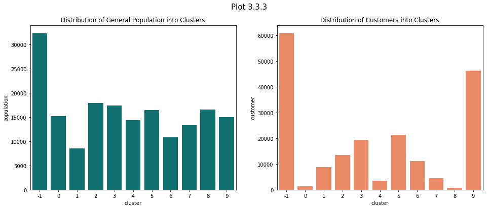

```python
# Re-visualize plot with missing row data added as cluster -1
fig = plt.figure(figsize=(16,6))

ax1 = fig.add_subplot(1,2,1)
ax1 = sns.barplot(x=pop_cust_clusters_data_count_df['cluster'],\
                  y=pop_cust_clusters_data_count_df['population'],\
                  color='teal',edgecolor='.9')
plt.title("Distribution of General Population into Clusters")

ax2 = fig.add_subplot(1,2,2)
ax2 = sns.barplot(x=pop_cust_clusters_data_count_df['cluster'],\
                  y=pop_cust_clusters_data_count_df['customer'],\
                  color='coral',edgecolor='.9')

plt.title("Distribution of Customers into Clusters")
plt.suptitle("Plot 3.3.3", fontsize=15);
```

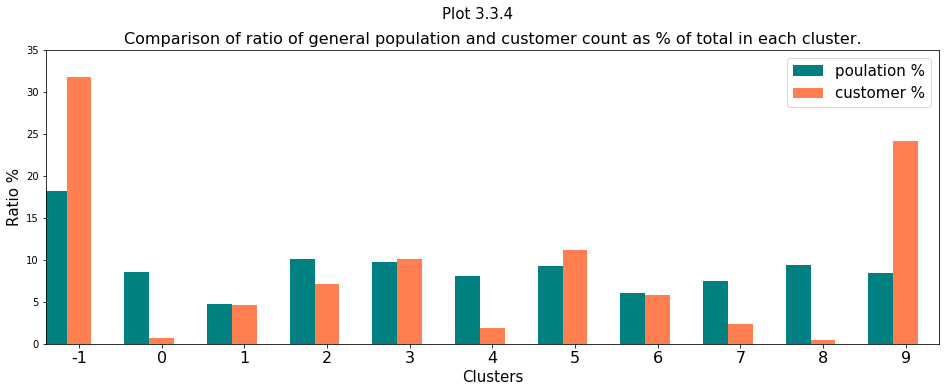

```python
# Re-visualize cluster ratios with missing row cluster -1

fig = plt.figure(figsize=(16,6))

ax = fig.add_subplot(111)

ax = pop_cust_clusters_data_count_df['pop_%'].plot(x=pop_cust_clusters_data_count_df['cluster'], kind='bar',\
                                                   color='teal',width=-0.3, align='edge',position=0)
ax = pop_cust_clusters_data_count_df['cust_%'].plot(x=pop_cust_clusters_data_count_df['cluster'], kind='bar',\
                                                    color='coral',width = 0.3, align='edge',position=1)

ax.margins(x=0.5,y=0.1)
ax.set_xlabel('Clusters', fontsize=15)
ax.set_ylabel('Ratio %', fontsize=15)
ax.xaxis.set(ticklabels= pop_cust_clusters_data_count_df['cluster'])
ax.tick_params(axis = 'x', which = 'major', labelsize = 16)
plt.xticks(rotation=360,)

plt.legend(('poulation %', 'customer %'),fontsize=15)
plt.title(('Comparison of ratio of general population and customer count as % of total in each cluster.')
          ,fontsize=16)

plt.subplots_adjust(bottom=0.2)
plt.suptitle("Plot 3.3.4", fontsize=15)
plt.show()
```

From the above visualization, we can observe that there is a proportion difference of +15.69% between customer proportion and genarl population proportion assigned to cluster 9. Therefore, cluster 9 over-represents customer data compared to general population.

Also, we can observe that there is a proportion difference of -8.90% between customer proportion and general population proportion assigned to cluster 8. Therefore, cluster 8 under-represents customer data compared to general population.

```python
# What kinds of people are part of a cluster that is overrepresented in the
# customer data compared to the general population?


# Analysis of principal components of cluster 9 consisting of people with over-representation in the
# customer data compared to the general population.
p_comp_cluster_9 = pd.Series(kmeans_10.cluster_centers_[9])
p_comp_cluster_9.index = p_comp_cluster_9.index + 1
p_comp_cluster_9.sort_values(ascending=False, inplace=True)
p_comp_cluster_9
```

```
1     4.765005
4     2.131913
6     1.111973
7     0.849343
5     0.669265
17    0.553747
19    0.458509
26    0.434569
15    0.405975
36    0.382000
27    0.208094
32    0.206176
10    0.205938
12    0.192689
54    0.183323
```

[output cut: 47 more lines]

```python
azdias_sample.columns
```

```
Index(['ANZ_HAUSHALTE_AKTIV', 'ANZ_HH_TITEL', 'ANZ_PERSONEN', 'ANZ_TITEL',
       'ARBEIT', 'BALLRAUM', 'D19_BANKEN_DIREKT', 'D19_BANKEN_GROSS',
       'D19_BANKEN_LOKAL', 'D19_BANKEN_REST',
       ...
       'ZABEOTYP_3', 'ZABEOTYP_4', 'ZABEOTYP_5', 'ZABEOTYP_6',
       'PRAEGENDE_JUGENDJAHRE_decade', 'PRAEGENDE_JUGENDJAHRE_movement',
       'CAMEO_INTL_2015_wealth', 'CAMEO_INTL_2015_life_stage',
       'WOHNLAGE_rural', 'WOHNLAGE_rating_class'],
      dtype='object', length=584)
```

```python
# Transform cluster 1 principal components to original feature values.
p_comp_cluster_9_orig = pd.Series(scaler.inverse_transform(pca_81.inverse_transform(p_comp_cluster_9)))
p_comp_cluster_9_orig = p_comp_cluster_9_orig.round(2)
p_comp_cluster_9_orig.index = azdias_sample.columns
p_comp_cluster_9_orig
```

```
ANZ_HAUSHALTE_AKTIV               1.67
ANZ_HH_TITEL                     -0.09
ANZ_PERSONEN                      2.49
ANZ_TITEL                        -0.02
ARBEIT                            2.83
BALLRAUM                          4.22
D19_BANKEN_DIREKT                 1.82
D19_BANKEN_GROSS                  1.35
D19_BANKEN_LOKAL                  0.59
D19_BANKEN_REST                   1.32
D19_BEKLEIDUNG_GEH                1.11
D19_BEKLEIDUNG_REST               2.52
D19_BILDUNG                       0.94
D19_BIO_OEKO                      0.69
D19_BUCH_CD                       2.73
D19_DIGIT_SERV                    0.30
D19_DROGERIEARTIKEL               1.85
D19_ENERGIE                       0.59
D19_FREIZEIT                      1.46
D19_GARTEN                        0.71
D19_HANDWERK                      1.44
D19_HAUS_DEKO                     2.16
D19_KINDERARTIKEL                 1.78
D19_KOSMETIK                      2.08
D19_LEBENSMITTEL                  0.79
D19_NAHRUNGSERGAENZUNG            0.79
D19_RATGEBER                      1.21
D19_REISEN                        1.52
D19_SAMMELARTIKEL                 1.13
D19_SCHUHE                        1.40
                                  ...
LP_STATUS_FEIN_5.0                0.05
LP_STATUS_FEIN_6.0                0.12
LP_STATUS_FEIN_7.0               -0.02
LP_STATUS_FEIN_8.0                0.05
LP_STATUS_FEIN_9.0                0.17
LP_STATUS_FEIN_10.0               0.24
LP_STATUS_GROB_1.0                0.27
LP_STATUS_GROB_2.0                0.17
LP_STATUS_GROB_3.0                0.10
LP_STATUS_GROB_4.0                0.22
LP_STATUS_GROB_5.0                0.24
NATIONALITAET_KZ_1.0              0.83
NATIONALITAET_KZ_2.0              0.13
NATIONALITAET_KZ_3.0              0.04
SHOPPER_TYP_0.0                   0.18
SHOPPER_TYP_1.0                   0.29
SHOPPER_TYP_2.0                   0.13
SHOPPER_TYP_3.0                   0.40
ZABEOTYP_1                        0.33
ZABEOTYP_2                        0.11
ZABEOTYP_3                        0.24
ZABEOTYP_4                        0.18
ZABEOTYP_5                        0.16
ZABEOTYP_6                       -0.01
PRAEGENDE_JUGENDJAHRE_decade      4.57
PRAEGENDE_JUGENDJAHRE_movement    0.63
CAMEO_INTL_2015_wealth            2.35
CAMEO_INTL_2015_life_stage        3.86
WOHNLAGE_rural                    0.39
WOHNLAGE_rating_class             1.53
Length: 584, dtype: float64
```

```python
# Analyze top principal component in cluster 9
# Getting top 5 positive and negative weights of a principal component 1.
weights_sorted_p_comp(1, 5)
```

```
Principal Component 1
------------------------------

Top positive weights are below

MOBI_REGIO        0.1305
KBA05_ANTG1       0.1227
KBA05_AUTOQUOT    0.1189
PLZ8_ANTG1        0.1169
KBA05_GBZ         0.1150
Name: PC 1, dtype: float64
------------------------------

Top negative weights are below

HH_EINKOMMEN_SCORE       -0.1280
CAMEO_INTL_2015_wealth   -0.1217
LP_STATUS_GROB_1.0       -0.1182
PLZ8_ANTG3               -0.1145
D19_GESAMT_ANZ_24_0      -0.1105
Name: PC 1, dtype: float64
```

```python
# Analyze second top principal component in cluster 9
# Getting top 5 positive and negative weights of a principal component 4.
weights_sorted_p_comp(4, 5)
```

```
Principal Component 4
------------------------------

Top positive weights are below

ALTERSKATEGORIE_GROB    0.1850
FINANZ_VORSORGER        0.1685
SEMIO_ERL               0.1370
SEMIO_LUST              0.1348
ZABEOTYP_3              0.1328
Name: PC 4, dtype: float64
------------------------------

Top negative weights are below

FINANZ_SPARER                  -0.1949
PRAEGENDE_JUGENDJAHRE_decade   -0.1891
SEMIO_PFLICHT                  -0.1813
FINANZ_UNAUFFAELLIGER          -0.1809
SEMIO_REL                      -0.1806
Name: PC 4, dtype: float64
```

```python
# What kinds of people are part of a cluster that is underrepresented in the
# customer data compared to the general population?

# Analysis of principal components of cluster 8 consisting of people with under-representation in the
# customer data compared to the general population.
p_comp_cluster_8 = pd.Series(kmeans_10.cluster_centers_[8])
p_comp_cluster_8.index = p_comp_cluster_8.index + 1
p_comp_cluster_8.sort_values(ascending=False, inplace=True)
p_comp_cluster_8
```

```
5     1.022458
7     0.856650
16    0.362078
23    0.292748
27    0.262447
22    0.218426
32    0.195239
17    0.195003
20    0.168807
14    0.112661
73    0.107181
34    0.104511
25    0.091996
40    0.089548
39    0.084982
```

[output cut: 47 more lines]

```python
# Transform cluster 8 principal components to original feature values.
p_comp_cluster_8_orig = pd.Series(scaler.inverse_transform(pca_81.inverse_transform(p_comp_cluster_8)))
p_comp_cluster_8_orig = p_comp_cluster_8_orig.round(2)
p_comp_cluster_8_orig.index = azdias_sample.columns
p_comp_cluster_8_orig
```

```
ANZ_HAUSHALTE_AKTIV               5.31
ANZ_HH_TITEL                     -0.07
ANZ_PERSONEN                      1.98
ANZ_TITEL                        -0.02
ARBEIT                            2.91
BALLRAUM                          3.93
D19_BANKEN_DIREKT                 0.97
D19_BANKEN_GROSS                  0.85
D19_BANKEN_LOKAL                  0.55
D19_BANKEN_REST                   0.89
D19_BEKLEIDUNG_GEH                0.70
D19_BEKLEIDUNG_REST               1.78
D19_BILDUNG                       0.47
D19_BIO_OEKO                      0.36
D19_BUCH_CD                       1.72
D19_DIGIT_SERV                    0.09
D19_DROGERIEARTIKEL               1.32
D19_ENERGIE                       0.27
D19_FREIZEIT                      0.88
D19_GARTEN                        0.42
D19_HANDWERK                      0.73
D19_HAUS_DEKO                     1.31
D19_KINDERARTIKEL                 1.04
D19_KOSMETIK                      1.34
D19_LEBENSMITTEL                  0.48
D19_NAHRUNGSERGAENZUNG            0.56
D19_RATGEBER                      0.75
D19_REISEN                        0.66
D19_SAMMELARTIKEL                 0.57
D19_SCHUHE                        1.00
                                  ...
LP_STATUS_FEIN_5.0                0.02
LP_STATUS_FEIN_6.0                0.10
LP_STATUS_FEIN_7.0               -0.03
LP_STATUS_FEIN_8.0                0.05
LP_STATUS_FEIN_9.0                0.10
LP_STATUS_FEIN_10.0               0.15
LP_STATUS_GROB_1.0                0.46
LP_STATUS_GROB_2.0                0.17
LP_STATUS_GROB_3.0                0.07
LP_STATUS_GROB_4.0                0.16
LP_STATUS_GROB_5.0                0.15
NATIONALITAET_KZ_1.0              0.75
NATIONALITAET_KZ_2.0              0.18
NATIONALITAET_KZ_3.0              0.06
SHOPPER_TYP_0.0                   0.13
SHOPPER_TYP_1.0                   0.29
SHOPPER_TYP_2.0                   0.14
SHOPPER_TYP_3.0                   0.41
ZABEOTYP_1                        0.21
ZABEOTYP_2                        0.09
ZABEOTYP_3                        0.35
ZABEOTYP_4                        0.10
ZABEOTYP_5                        0.22
ZABEOTYP_6                        0.03
PRAEGENDE_JUGENDJAHRE_decade      4.46
PRAEGENDE_JUGENDJAHRE_movement    0.77
CAMEO_INTL_2015_wealth            2.85
CAMEO_INTL_2015_life_stage        3.61
WOHNLAGE_rural                    0.32
WOHNLAGE_rating_class             1.90
Length: 584, dtype: float64
```

```python
# Analyze top principal component in cluster 8
# Getting top 5 positive and negative weights of a principal component 5.
weights_sorted_p_comp(5, 5)
```

```
Principal Component 5
------------------------------

Top positive weights are below

KBA13_VORB_0        0.1636
KBA13_KW_61_120     0.1457
KBA13_SITZE_5       0.1390
KBA13_KRSZUL_NEU    0.1205
KBA05_VORB0         0.1126
Name: PC 5, dtype: float64
------------------------------

Top negative weights are below

KBA13_BJ_2000   -0.1781
OST_WEST_KZ     -0.1709
KBA13_KW_0_60   -0.1599
KBA13_BJ_1999   -0.1380
KBA13_SITZE_6   -0.1337
Name: PC 5, dtype: float64
```

```python
# Analyze second top principal component in cluster 8
# Getting top 5 positive and negative weights of a second top principal component 7.
weights_sorted_p_comp(7, 5)
```

```
Principal Component 7
------------------------------

Top positive weights are below

KBA05_SEG2        0.2262
KBA05_KRSKLEIN    0.2124
KBA05_CCM1        0.2046
KBA05_MOD4        0.1821
KBA05_KW1         0.1646
Name: PC 7, dtype: float64
------------------------------

Top negative weights are below

KBA05_MAXSEG             -0.1754
KBA05_KW2                -0.1525
KBA13_SEG_MITTELKLASSE   -0.1512
KBA05_SEG4               -0.1309
KBA13_ALTERHALTER_30     -0.1278
Name: PC 7, dtype: float64
```

#### Discussion 3.3: Compare Customer Data to Demographics Data

##### Compare the Population and Customer clusters without consideration of the missing row data.

If we compare the Population and Customer clusters without consideration of the missing row data, we can observe the below -

General Population dataset has highest count(17921) of observations in cluster 2 and has lowest count(8535) of observations in cluster 1. Customer dataset has highest count(46202) of observations in cluster 9 and lowest count(815) in cluster 8.

From plot 3.3.1, we can observe that there is a difference in the cluster distributions between the general population and the customer dataset. Looking at the ratios of each cluster against total counts in order to make better comparisons, we can see the customer dataset is over-represented in clusters 9 and 5 with greater than 5% ratio difference to the general population, and under-represented in clusters 8, 0, 4 and 7 with 5% ratio difference to the general population.

This can be seen in Plot 3.3.2, where the significance of cluster 9 customer segment to the mail order company's customer base is clearly visible.

However, to make this analysis more complete, we should also include the missing row data as an additional cluster. In step 1.1.3 we found that the rows of missing data were qualitatively different to the the rows kept for the analysis.

##### Compare the Population and Customer clusters with consideration of the missing row data.

If we compare the Population and Customer clusters with consideration of the missing row data, we can observe the below -

we have assigned missing row data to cluster -1.

Plots 3.3.3 and 3.3.4 are the same visualizations as 3.3.1 and 3.3.2 respectively with the missing row data added as cluster -1. We can see the impact is significant.

General Population dataset has 162135 rows with missing data(where number of missing values in each row is greater than 8). Now, we have used sample dataset from general population dataset in our analysis. we have used 20 % sample dataset which is representative of the general population data. Therefore, 20 % of the missing row data for the population dataset would be 32427 and it represented 18.19% of the general population data.

Customer dataset has 60991 rows with missing data(where number of missing values in each row is greater than 8). The missing row data for the customer dataset represented 31.82% of the total customer data.

If we take +5% threshold of ratio difference for determining over-representation and -5% threshold of ratio difference for determining under-representation, the customer dataset is over-represented in cluster 9(15.69%) and cluster -1(13.63%), and under-represented in clusters 8(-8.90%), 0(-7.84%), 4(-6.23%) and 7(-5.14%).

So, from the above, customer data is over-represented in cluster 9 and under-represented in cluster 8.

The missing row data requires more investigation and analysis but from the preliminary bar charts constructed in step 1.1.3, this data seems to represent conservative, minimilistic high-income earners receptive to advertising incentives and is a relevant customer segment for targeting for the mail order company.

##### Analysis for Cluster that is over-represented in the customer data is below -

Cluster 9 is the most relevant cluster for the mail order company's customer base. If we analyze the features that make up this cluster by inverse transforming the principal components and inverse scaling we obtain values for the cluster centroid for our original features(after data wrangling step earlier) that we can use to create a picture of the customer segment. We can also determine the most important features by looking at the principal components that have the biggest impact on the cluster and then analyzing which features make up the largest positive and negative weights of this principal component as we did in step 2.3.

For cluster 9, the main principal component is number component 1 that has a value of 4.77 followed by component number 4, 6, 7 and 5 with values of 2.12, 1.10, 0.84 and 0.67 respectively. From this we can see principal components 1 has the biggest influence.

Top 5 positive weights for component 1 are -

MOBI_REGIO, feature value = 3.52, signifies low to medium moving patterns, KBA05_ANTG1, feature value = 2.02, signifies average share of 1-2 family homes, KBA05_AUTOQUOT, feature value = 3.16, signifies average share of cars per household, PLZ8_ANTG1, feature value = 2.50, signifies average number of 1-2 family houses in the PLZ8, KBA05_GBZ, feature value = 3.56, signifies 5-16 number of buildings in the microcell,

**From the above details we can start to form a picture of the biggest customer segment group for the mail order company. They are average income earners of age from 30-60 years which are environment friendly & green enery consumers having modern outlook with average affinity. They have average share of cars & live in comfortable households and belong to a medium density populated area like small urban areas but within driving distance of a larger urban city.**

##### Analysis for Cluster that is under-represented in the customer data is below -

Looking at the top five positive & neagtive weights for component 5 and their original feature value from the inverse transformation:

Top 5 positive weights for component 5 are -

KBA13_VORB_0, feature value = 3.15, signifies average share of cars with no preowner - PLZ8, KBA13_KW_61_120, feature value = 2.95, signifies average share of cars with an engine power between 61 and 120 KW - PLZ8, KBA13_SITZE_5, feature value = 2.85, signifies average number of cars with 5 seats in the PLZ8, KBA13_KRSZUL_NEU, feature value = 1.86, signifies average share of newbuilt cars (referred to the county average) - PLZ8, KBA05_VORB0, feature value = 2.89, signifies average share of cars with no preowner,

Top 5 negative weights for component 5 are -

KBA13_BJ_2000, feature value = 2.85, signifies average share of cars built between 2000 and 2003 within the PLZ8, OST_WEST_KZ, feature value = 0.76, signifies former FRG, KBA13_KW_0_60, feature value = 2.99, signifies average share of cars up to 60 KW engine power - PLZ8, KBA13_BJ_1999, feature value = 2.70, signifies average share of cars built between 1995 and 1999 within the PLZ8, KBA13_SITZE_6, feature value = 3.08, signifies number of cars with more than 5 seats in the PLZ8,

Top 5 positive weights for component 7 are -

KBA05_SEG2, feature value = 3.18, signifies average share of small and very small cars (Ford Fiesta, Ford Ka etc.) in the microcell, KBA05_KRSKLEIN, feature value = 2.12, signifies average share of small cars, KBA05_CCM1, feature value = 3.14, signifies average share of cars with less than 1399ccm, KBA05_MOD4, feature value = 2.77, signifies average share of small cars, KBA05_KW1, feature value = 3.08, signifies average share of cars with less than 59 KW engine power,

Top 5 negative weights for component 7 are -

KBA05_MAXSEG, feature value = 2.18, signifies lower middleclass car, KBA05_KW2, feature value = 2.97, signifies average share of cars with an engine power between 60 and 119 KW, KBA13_SEG_MITTELKLASSE, feature value = 3.10, signifies average share of middle class cars (Ford Mondeo etc.) in the PLZ8, KBA05_SEG4, feature value = 2.97, signifies average share of middle class cars (Ford Mondeo etc.) in the microcell, KBA13_ALTERHALTER_30, feature value = 2.91, signifies average share of car owners below 31 within the PLZ8

**From the above details we can start to form a picture of the lowest customer segment group for the mail order company. They have average share of cars with no preowner i.e. have newbuilt cars built after 2003 with an engine power between 0 to 120 KW which are small in size with 5 seats.**

## Part 2: Supervised Learning Model

Now that you've found which parts of the population are more likely to be customers of the mail-order company, it's time to build a prediction model. Each of the rows in the "MAILOUT" data files represents an individual that was targeted for a mailout campaign. Ideally, we should be able to use the demographic information from each individual to decide whether or not it will be worth it to include that person in the campaign.

The "MAILOUT" data has been split into two approximately equal parts, each with almost 43 000 data rows. In this part, you can verify your model with the "TRAIN" partition, which includes a column, "RESPONSE", that states whether or not a person became a customer of the company following the campaign. In the next part, you'll need to create predictions on the "TEST" partition, where the "RESPONSE" column has been withheld.

### Step 2.1 Explore the Data

```python
# Load train dataset
mailout_train = pd.read_csv('../../data/Term2/capstone/arvato_data/Udacity_MAILOUT_052018_TRAIN.csv', sep=';')
```

```python
# Shape of train datastet
mailout_train.shape
```

```
(42962, 367)
```

```python
# Print first few rows of mailout_train
mailout_train.head()
```

|  | LNR | AGER_TYP | AKT_DAT_KL | ALTER_HH | ALTER_KIND1 | ALTER_KIND2 | ALTER_KIND3 | ALTER_KIND4 | ALTERSKATEGORIE_FEIN | ANZ_HAUSHALTE_AKTIV | ... | VK_DHT4A | VK_DISTANZ | VK_ZG11 | W_KEIT_KIND_HH | WOHNDAUER_2008 | WOHNLAGE | ZABEOTYP | RESPONSE | ANREDE_KZ | ALTERSKATEGORIE_GROB |
| --- | --- | --- | --- | --- | --- | --- | --- | --- | --- | --- | --- | --- | --- | --- | --- | --- | --- | --- | --- | --- | --- |
| 0 | 1763 | 2 | 1.0 | 8.0 | NaN | NaN | NaN | NaN | 8.0 | 15.0 | ... | 5.0 | 2.0 | 1.0 | 6.0 | 9.0 | 3.0 | 3 | 0 | 2 | 4 |
| 1 | 1771 | 1 | 4.0 | 13.0 | NaN | NaN | NaN | NaN | 13.0 | 1.0 | ... | 1.0 | 2.0 | 1.0 | 4.0 | 9.0 | 7.0 | 1 | 0 | 2 | 3 |
| 2 | 1776 | 1 | 1.0 | 9.0 | NaN | NaN | NaN | NaN | 7.0 | 0.0 | ... | 6.0 | 4.0 | 2.0 | NaN | 9.0 | 2.0 | 3 | 0 | 1 | 4 |
| 3 | 1460 | 2 | 1.0 | 6.0 | NaN | NaN | NaN | NaN | 6.0 | 4.0 | ... | 8.0 | 11.0 | 11.0 | 6.0 | 9.0 | 1.0 | 3 | 0 | 2 | 4 |
| 4 | 1783 | 2 | 1.0 | 9.0 | NaN | NaN | NaN | NaN | 9.0 | 53.0 | ... | 2.0 | 2.0 | 1.0 | 6.0 | 9.0 | 3.0 | 3 | 0 | 1 | 3 |

5 rows × 367 columns

```python
# Print number of individuals whom responded to the mailout campaign
mailout_train['RESPONSE'].value_counts()
```

```
0    42430
1      532
Name: RESPONSE, dtype: int64
```

```python
# Print proprtion of individuals whom responded to the mailout campaign
round((mailout_train['RESPONSE'].value_counts()/mailout_train.shape[0])*100,2)
```

```
0    98.76
1     1.24
Name: RESPONSE, dtype: float64
```

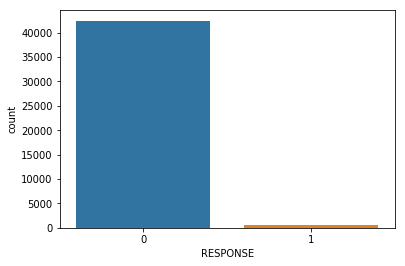

```python
# Plot count of individuals whom responded to the mailout campaign
sns.countplot(mailout_train['RESPONSE'])
```

From above, we can say that there are only 1.24% i.e. only 532 individuals whom responded to the mailout campaign. The dataset is highly imbalanced because of the huge difference in proportion of numbers of individuals whom responded to the campaign and numbers of individuals whom did not responded.

```python
# Check for missing value is 'RESPONSE' column
mailout_train['RESPONSE'].isnull().sum()
```

```
0
```

From above, we can observe that there are no missing values in column 'RESPONSE'.

```python
# Selecting features and response in mailout_train dataset
train_features = mailout_train.drop(['RESPONSE'], axis=1)
train_response = mailout_train['RESPONSE']
```

```python
# Quanitfying the naturally missing data in features in descenindg order
train_features_init_null = find_missing_data(train_features)
train_features_init_null
```

|  | count | pct |
| --- | --- | --- |
| ALTER_KIND4 | 42921 | 99.90 |
| ALTER_KIND3 | 42788 | 99.59 |
| ALTER_KIND2 | 42206 | 98.24 |
| ALTER_KIND1 | 40974 | 95.37 |
| KK_KUNDENTYP | 25316 | 58.93 |
| EXTSEL992 | 15948 | 37.12 |
| W_KEIT_KIND_HH | 9678 | 22.53 |
| HH_DELTA_FLAG | 9678 | 22.53 |
| KBA05_ZUL1 | 8648 | 20.13 |
| KBA05_KRSZUL | 8648 | 20.13 |
| KBA05_KRSKLEIN | 8648 | 20.13 |
| KBA05_KRSOBER | 8648 | 20.13 |
| KBA05_KRSVAN | 8648 | 20.13 |
| KBA05_KW3 | 8648 | 20.13 |
| KBA05_KW1 | 8648 | 20.13 |
| KBA05_KW2 | 8648 | 20.13 |
| KBA05_MAXAH | 8648 | 20.13 |
| KBA05_KRSHERST2 | 8648 | 20.13 |
| KBA05_HERST5 | 8648 | 20.13 |
| KBA05_KRSHERST1 | 8648 | 20.13 |
| KBA05_KRSAQUOT | 8648 | 20.13 |
| KBA05_MAXHERST | 8648 | 20.13 |
| KBA05_HERST4 | 8648 | 20.13 |
| KBA05_HERST3 | 8648 | 20.13 |
| KBA05_HERST2 | 8648 | 20.13 |
| KBA05_HERST1 | 8648 | 20.13 |
| KBA05_GBZ | 8648 | 20.13 |
| KBA05_FRAU | 8648 | 20.13 |
| KBA05_DIESEL | 8648 | 20.13 |
| KBA05_CCM4 | 8648 | 20.13 |
| ... | ... | ... |
| VHA | 6969 | 16.22 |
| ANZ_KINDER | 6969 | 16.22 |
| SOHO_KZ | 6969 | 16.22 |
| WOHNDAUER_2008 | 6969 | 16.22 |
| ANZ_TITEL | 6969 | 16.22 |
| TITEL_KZ | 6969 | 16.22 |
| ALTER_HH | 6969 | 16.22 |
| AKT_DAT_KL | 6969 | 16.22 |
| EINGEZOGENAM_HH_JAHR | 6969 | 16.22 |
| RT_UEBERGROESSE | 6380 | 14.85 |
| HH_EINKOMMEN_SCORE | 704 | 1.64 |
| ONLINE_AFFINITAET | 605 | 1.41 |
| GFK_URLAUBERTYP | 605 | 1.41 |
| LP_FAMILIE_FEIN | 605 | 1.41 |
| LP_FAMILIE_GROB | 605 | 1.41 |
| LP_LEBENSPHASE_FEIN | 605 | 1.41 |
| LP_LEBENSPHASE_GROB | 605 | 1.41 |
| LP_STATUS_FEIN | 605 | 1.41 |
| LP_STATUS_GROB | 605 | 1.41 |
| CJT_TYP_3 | 605 | 1.41 |
| CJT_TYP_2 | 605 | 1.41 |
| CJT_TYP_5 | 605 | 1.41 |
| CJT_GESAMTTYP | 605 | 1.41 |
| CJT_TYP_4 | 605 | 1.41 |
| RT_SCHNAEPPCHEN | 605 | 1.41 |
| RT_KEIN_ANREIZ | 605 | 1.41 |
| RETOURTYP_BK_S | 605 | 1.41 |
| CJT_KATALOGNUTZER | 605 | 1.41 |
| CJT_TYP_1 | 605 | 1.41 |
| CJT_TYP_6 | 605 | 1.41 |

273 rows × 2 columns

```python
# Identify missing or unknown data values in train_features dataframe columns and convert them to NaNs
# as per nan_vals in feat_info
for idx in feat_info.index:
    column = idx
    if column in train_features.columns:
        train_features[column] = train_features[column].replace(feat_info.loc[column]['nan_vals'], np.nan)
```

```python
# Count value of NaN values in each column in descending order after encoding missing values
train_features_after_nan = find_missing_data(train_features)
train_features_after_nan
```

|  | count | pct |
| --- | --- | --- |
| ALTER_KIND4 | 42921 | 99.90 |
| ALTER_KIND3 | 42788 | 99.59 |
| TITEL_KZ | 42749 | 99.50 |
| ALTER_KIND2 | 42206 | 98.24 |
| ALTER_KIND1 | 40974 | 95.37 |
| KK_KUNDENTYP | 25316 | 58.93 |
| KBA05_BAUMAX | 22980 | 53.49 |
| AGER_TYP | 18890 | 43.97 |
| GEBURTSJAHR | 17475 | 40.68 |
| EXTSEL992 | 15948 | 37.12 |
| ALTER_HH | 13177 | 30.67 |
| W_KEIT_KIND_HH | 10417 | 24.25 |
| REGIOTYP | 9930 | 23.11 |
| KKK | 9930 | 23.11 |
| HH_DELTA_FLAG | 9678 | 22.53 |
| KBA05_KRSZUL | 9031 | 21.02 |
| KBA05_KRSOBER | 9031 | 21.02 |
| KBA05_KW3 | 9031 | 21.02 |
| KBA05_KW1 | 9031 | 21.02 |
| KBA05_KW2 | 9031 | 21.02 |
| KBA05_MAXAH | 9031 | 21.02 |
| KBA05_KRSKLEIN | 9031 | 21.02 |
| KBA05_HERST5 | 9031 | 21.02 |
| KBA05_KRSHERST3 | 9031 | 21.02 |
| KBA05_KRSHERST2 | 9031 | 21.02 |
| KBA05_KRSHERST1 | 9031 | 21.02 |
| KBA05_KRSAQUOT | 9031 | 21.02 |
| KBA05_MAXHERST | 9031 | 21.02 |
| KBA05_HERST4 | 9031 | 21.02 |
| KBA05_HERST3 | 9031 | 21.02 |
| ... | ... | ... |
| VK_ZG11 | 7267 | 16.91 |
| VK_DISTANZ | 7267 | 16.91 |
| KONSUMNAEHE | 6997 | 16.29 |
| EINGEZOGENAM_HH_JAHR | 6969 | 16.22 |
| ANZ_PERSONEN | 6969 | 16.22 |
| ANZ_KINDER | 6969 | 16.22 |
| ANZ_TITEL | 6969 | 16.22 |
| WOHNDAUER_2008 | 6969 | 16.22 |
| UNGLEICHENN_FLAG | 6969 | 16.22 |
| AKT_DAT_KL | 6969 | 16.22 |
| SOHO_KZ | 6969 | 16.22 |
| VHA | 6969 | 16.22 |
| RT_UEBERGROESSE | 6380 | 14.85 |
| HH_EINKOMMEN_SCORE | 704 | 1.64 |
| CJT_TYP_6 | 605 | 1.41 |
| ONLINE_AFFINITAET | 605 | 1.41 |
| GFK_URLAUBERTYP | 605 | 1.41 |
| RT_SCHNAEPPCHEN | 605 | 1.41 |
| RT_KEIN_ANREIZ | 605 | 1.41 |
| RETOURTYP_BK_S | 605 | 1.41 |
| CJT_TYP_5 | 605 | 1.41 |
| CJT_TYP_4 | 605 | 1.41 |
| CJT_TYP_3 | 605 | 1.41 |
| CJT_TYP_2 | 605 | 1.41 |
| LP_STATUS_FEIN | 605 | 1.41 |
| LP_STATUS_GROB | 605 | 1.41 |
| CJT_GESAMTTYP | 605 | 1.41 |
| CJT_KATALOGNUTZER | 605 | 1.41 |
| CJT_TYP_1 | 605 | 1.41 |
| ALTERSKATEGORIE_GROB | 81 | 0.19 |

281 rows × 2 columns

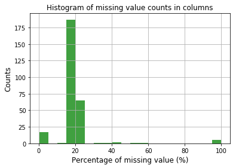

```python
#Plot distribution of missing value counts in columns
plot_hist_missing_col(train_features_after_nan)
```

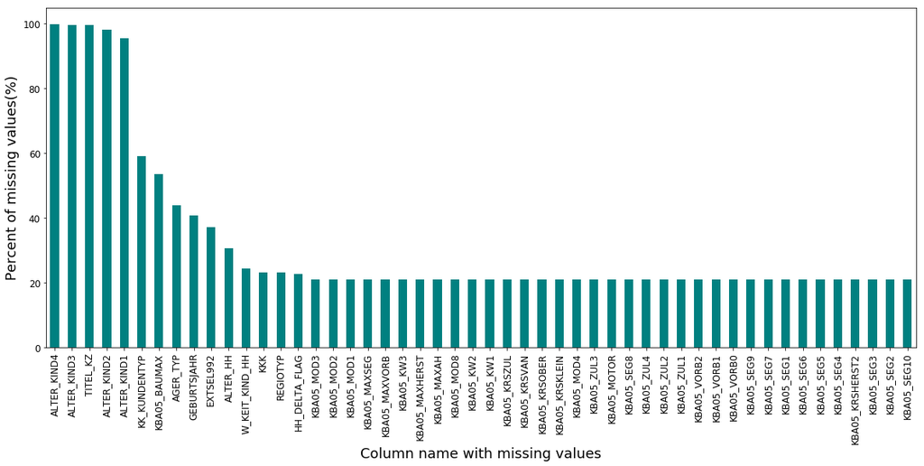

```python
# Visualizing the top 50 features with missing data
plot_top50_feat(train_features)
```

```python
# Find the name of columns with more than 25% missing values in train_features
missing_25 = find_cols_missing_pct_data(train_features, pct=25)
print(missing_25)
```

```
['AGER_TYP', 'ALTER_HH', 'ALTER_KIND1', 'ALTER_KIND2', 'ALTER_KIND3', 'ALTER_KIND4', 'EXTSEL992', 'GEBURTSJAHR', 'KBA05_BAUMAX', 'KK_KUNDENTYP', 'TITEL_KZ']
```

```python
# Number of features with more than 25% missing values
len(missing_25)
```

```
11
```

```python
# How many features are there of each data type in train_features?
#find_feat_dtype(train_features)
print('Number of features of each data type are : {}'.format(find_feat_dtype(train_features)))
```

```
Number of features of each data type are : {dtype('int64'): 85, dtype('float64'): 275, dtype('O'): 6}
```

```python
# Print columns with dtype as 'Object'
col_names_obj = []
for col in train_features.columns:
    if train_features[col].dtype.name == 'object':
        col_names_obj.append(col)

print(col_names_obj)
```

```
['CAMEO_DEU_2015', 'CAMEO_DEUG_2015', 'CAMEO_INTL_2015', 'D19_LETZTER_KAUF_BRANCHE', 'EINGEFUEGT_AM', 'OST_WEST_KZ']
```

### Step 2.2 Prepare the Data

#### Step 2.2.1 Clean the Data

Before the imbalanced dataset can be used as input for machine learning algorithms, it often must be cleaned, formatted, and restructured — this is typically known as preprocessing. Fortunately, the features are similar to the general population dataset and the customers dataset.

In order to preserve all the rows to predict, clean_data function has been revised.

```python
# Revise clean_data function to preserve all the rows to predict
def clean_data_revised(df):
    """
    Perform feature trimming, re-encoding, and engineering for demographics
    data

    INPUT: Demographics DataFrame
    OUTPUT: Trimmed and cleaned DataFrame
    """
    for idx in feat_info.index:
        column = idx
        if column in df.columns:
            df[column] = df[column].replace(feat_info.loc[column]['nan_vals'], np.nan)

    # Find the name of columns with more than 25% missing values
    missing_25 = find_cols_missing_pct_data(df, pct=25)

    # remove selected columns(columns having missing values more than 25%)
    df.drop(missing_25, axis=1, inplace=True)

    # drop column 'LNR' as it contains unique ID for each individual
    df.drop('LNR', axis=1, inplace=True)

    # select, re-encode, and engineer few features
    df['PRAEGENDE_JUGENDJAHRE_decade'] = df['PRAEGENDE_JUGENDJAHRE'].apply(make_decade)
    df['PRAEGENDE_JUGENDJAHRE_movement'] = df['PRAEGENDE_JUGENDJAHRE'].apply(make_movement)
    df.drop('PRAEGENDE_JUGENDJAHRE', axis=1, inplace=True)

    df['WOHNLAGE_rural'] = df['WOHNLAGE'].map({0:0,1:0,2:0,3:0,4:0,5:0,7:1,8:1})
    df['WOHNLAGE_rating_class'] = df['WOHNLAGE'].map({0:0,1:1,2:2,3:3,4:4,5:5,7:0,8:0})

    df = df.drop(['LP_LEBENSPHASE_FEIN','LP_LEBENSPHASE_GROB','WOHNLAGE','PLZ8_BAUMAX'], axis=1)

    # Taking care of 6 features with dtype as 'Object'
    # 'CAMEO_DEU_2015', 'CAMEO_DEUG_2015', 'CAMEO_INTL_2015', 'D19_LETZTER_KAUF_BRANCHE', 'EINGEFUEGT_AM' & 'OST_WEST_KZ'
    df['OST_WEST_KZ'].replace(['W','O'], [1, 0], inplace=True)

    df['CAMEO_INTL_2015_wealth'] = df['CAMEO_INTL_2015'].apply(make_wealth)
    df['CAMEO_INTL_2015_life_stage'] = df['CAMEO_INTL_2015'].apply(make_life_stage)
    df.drop('CAMEO_INTL_2015', axis=1, inplace=True)

    df['CAMEO_DEUG_2015'] = df['CAMEO_DEUG_2015'].astype('float64')

    df = df.drop(['EINGEFUEGT_AM'], axis=1) # drop feature 'EINGEFUEGT_AM' as it contains unique timestamp

    multi = ['CAMEO_DEU_2015','D19_LETZTER_KAUF_BRANCHE']
    df = pd.get_dummies(df, columns=multi, prefix=multi, dummy_na=True, drop_first=True)

    # Return the cleaned dataframe.
    return df
```

```python
# Prepare the data using the function clean_data_revised
train_features_cleaned = clean_data_revised(train_features)
```

```python
# Print shape of train_features dataset after cleaning
train_features_cleaned.shape
```

```
(42962, 430)
```

#### Step 2.2.2 Feature Transformation

```python
# Impute nans with median value
imputer = Imputer(missing_values='NaN',strategy='median',axis=0)
train_features_imputed = imputer.fit_transform(train_features_cleaned)
print('Type of train_features_imputed is : {}'.format(type(train_features_imputed)))

# Making train_features_imputed into a dataframe
train_features_imputed = pd.DataFrame(train_features_imputed)
print('Type of train_features_imputed now is : {}'.format(type(train_features_imputed)))
train_features_imputed.head()
```

```
Type of train_features_imputed is : <class 'numpy.ndarray'>
Type of train_features_imputed now is : <class 'pandas.core.frame.DataFrame'>
```

|  | 0 | 1 | 2 | 3 | 4 | 5 | 6 | 7 | 8 | 9 | ... | 420 | 421 | 422 | 423 | 424 | 425 | 426 | 427 | 428 | 429 |
| --- | --- | --- | --- | --- | --- | --- | --- | --- | --- | --- | --- | --- | --- | --- | --- | --- | --- | --- | --- | --- | --- |
| 0 | 1.0 | 8.0 | 15.0 | 0.0 | 0.0 | 1.0 | 13.0 | 0.0 | 3.0 | 5.0 | ... | 0.0 | 0.0 | 0.0 | 0.0 | 1.0 | 0.0 | 0.0 | 0.0 | 0.0 | 0.0 |
| 1 | 4.0 | 13.0 | 1.0 | 0.0 | 0.0 | 2.0 | 1.0 | 0.0 | 2.0 | 5.0 | ... | 0.0 | 1.0 | 0.0 | 0.0 | 0.0 | 0.0 | 0.0 | 0.0 | 0.0 | 0.0 |
| 2 | 1.0 | 7.0 | 2.0 | 0.0 | 0.0 | 0.0 | 1.0 | 0.0 | 4.0 | 1.0 | ... | 0.0 | 0.0 | 0.0 | 0.0 | 0.0 | 0.0 | 0.0 | 0.0 | 0.0 | 0.0 |
| 3 | 1.0 | 6.0 | 4.0 | 0.0 | 0.0 | 2.0 | 4.0 | 0.0 | 4.0 | 2.0 | ... | 0.0 | 0.0 | 0.0 | 0.0 | 1.0 | 0.0 | 0.0 | 0.0 | 0.0 | 0.0 |
| 4 | 1.0 | 9.0 | 53.0 | 0.0 | 0.0 | 1.0 | 44.0 | 0.0 | 3.0 | 4.0 | ... | 0.0 | 0.0 | 0.0 | 0.0 | 0.0 | 0.0 | 0.0 | 0.0 | 0.0 | 0.0 |

5 rows × 430 columns

```python
# Checking the sum of all misisng values in the train_features_imputed dataset.
# It should be 0 as we have already imputed the missing value with mode value.
sum(train_features_imputed.isnull().sum())
```

```
0
```

```python
len(list(train_features_imputed.columns.values))
```

```
430
```

```python
# Apply feature scaling to the train_features_imputed dataset.

scaler = StandardScaler()
train_features_scaled = scaler.fit_transform(train_features_imputed)
print('Type of train_features_scaled is : {}'.format(type(train_features_scaled)))

# Making train_features_scaled into a dataframe
train_features_scaled = pd.DataFrame(train_features_scaled, columns= list(train_features_cleaned.columns.values))
print('Type of train_features_scaled now is : {}'.format(type(train_features_scaled)))
train_features_scaled.head()
```

```
Type of train_features_scaled is : <class 'numpy.ndarray'>
Type of train_features_scaled now is : <class 'pandas.core.frame.DataFrame'>
```

|  | AKT_DAT_KL | ALTERSKATEGORIE_FEIN | ANZ_HAUSHALTE_AKTIV | ANZ_HH_TITEL | ANZ_KINDER | ANZ_PERSONEN | ANZ_STATISTISCHE_HAUSHALTE | ANZ_TITEL | ARBEIT | BALLRAUM | ... | D19_LETZTER_KAUF_BRANCHE_D19_TECHNIK | D19_LETZTER_KAUF_BRANCHE_D19_TELKO_MOBILE | D19_LETZTER_KAUF_BRANCHE_D19_TELKO_REST | D19_LETZTER_KAUF_BRANCHE_D19_TIERARTIKEL | D19_LETZTER_KAUF_BRANCHE_D19_UNBEKANNT | D19_LETZTER_KAUF_BRANCHE_D19_VERSAND_REST | D19_LETZTER_KAUF_BRANCHE_D19_VERSICHERUNGEN | D19_LETZTER_KAUF_BRANCHE_D19_VOLLSORTIMENT | D19_LETZTER_KAUF_BRANCHE_D19_WEIN_FEINKOST | D19_LETZTER_KAUF_BRANCHE_nan |
| --- | --- | --- | --- | --- | --- | --- | --- | --- | --- | --- | --- | --- | --- | --- | --- | --- | --- | --- | --- | --- | --- |
| 0 | -0.274048 | -0.478176 | 0.659884 | -0.116979 | -0.204857 | -0.815974 | 0.573741 | -0.083831 | -0.038459 | 0.303152 | ... | -0.094717 | -0.113246 | -0.112718 | -0.052032 | 1.783482 | -0.138797 | -0.257011 | -0.23723 | -0.085392 | -0.463002 |
| 1 | 1.594293 | 0.791833 | -0.352970 | -0.116979 | -0.204857 | -0.011516 | -0.344470 | -0.083831 | -1.110675 | 0.303152 | ... | -0.094717 | 8.830304 | -0.112718 | -0.052032 | -0.560701 | -0.138797 | -0.257011 | -0.23723 | -0.085392 | -0.463002 |
| 2 | -0.274048 | -0.732178 | -0.280624 | -0.116979 | -0.204857 | -1.620432 | -0.344470 | -0.083831 | 1.033757 | -1.690267 | ... | -0.094717 | -0.113246 | -0.112718 | -0.052032 | -0.560701 | -0.138797 | -0.257011 | -0.23723 | -0.085392 | -0.463002 |
| 3 | -0.274048 | -0.986180 | -0.135930 | -0.116979 | -0.204857 | -0.011516 | -0.114917 | -0.083831 | 1.033757 | -1.191912 | ... | -0.094717 | -0.113246 | -0.112718 | -0.052032 | 1.783482 | -0.138797 | -0.257011 | -0.23723 | -0.085392 | -0.463002 |
| 4 | -0.274048 | -0.224175 | 3.409061 | -0.116979 | -0.204857 | -0.815974 | 2.945784 | -0.083831 | -0.038459 | -0.195203 | ... | -0.094717 | -0.113246 | -0.112718 | -0.052032 | -0.560701 | -0.138797 | -0.257011 | -0.23723 | -0.085392 | -0.463002 |

5 rows × 430 columns

```python
# Print shape of train_features_scaled
train_features_scaled.shape
```

```
(42962, 430)
```

### Step 2.3 Evaluate Model Performance

Since there is a large output class imbalance, predicting individual classes and using accuracy does not seem to be an appropriate performance evaluation method. Instead, the model will be using ROC-AUC to evaluate performance.

Aside from the Kaggle competition (see section below) using ROC-AUC as the score, the metric is suitable for binary classification problems such as this. ROC curves give us the ability to assess the performance of the classifier over its entire operating range. The most widely-used measure is the area under the curve (AUC). The AUC can be used to compare the performance of two or more classifiers. A single threshold can be selected and the classifiers’ performance at that point compared, or the overall performance can be compared by considering the AUC". Compared to the F1 score, the ROC does not require optimizing a threshold for each label.

#### Step 2.3.1 Classification

```python
# Define fit_classifier function to fit different classifiers on training dataset i.e. train_features_scaled
# to find the best performing classifier algorithm
def fit_classifier(clf, param_grid, X=train_features_scaled, y=train_response):
    """
    Fits a classifier to its training data using GridSearchCV and calculates ROC AUC score

    INPUT:
    - clf (classifier): classifier to fit
    - param_grid (dict): classifier parameters used with GridSearchCV
    - X_train (DataFrame): training input
    - y_train (DataFrame): training output

    OUTPUT:
    - classifier: input classifier fitted to the training data
    """

    # cv uses StratifiedKFold
    # scoring roc_auc available as parameter
    start = time.time()
    grid = GridSearchCV(estimator=clf, param_grid=param_grid, scoring='roc_auc', cv=5, verbose=0)
    print("Training {} :".format(clf.__class__.__name__))
    grid.fit(X, y)
    end = time.time()
    time_taken = round(end-start,2)

    print(clf.__class__.__name__)
    print("Time taken : {} secs".format(time_taken))
    print("Best score : {}".format(round(grid.best_score_,4)))
    print("*"*40)

    return grid.best_score_, grid.best_estimator_, time_taken
```

```python
# Initialize classification algorithms
lor = LogisticRegression(random_state=42) # LogisticRegression
rfc = RandomForestClassifier(random_state=42) # RandomForestClassifier
abc = AdaBoostClassifier(random_state=42) # AdaBoostClassifier
gbc = GradientBoostingClassifier(random_state=42) # GradientBoostingClassifier
```

```python
# Find best classification algorithm
clf_names = []
clf_scores = []
clf_best_ests = []
clf_time_taken = []
clf_dict = {}

for clf in [lor, rfc, abc, gbc]:
    best_score, best_est, time_taken = fit_classifier(clf, {})
    clf_names.append(clf.__class__.__name__)
    clf_scores.append(best_score)
    clf_best_ests.append(best_est)
    clf_time_taken.append(time_taken)
```

```
Training LogisticRegression :
LogisticRegression
Time taken : 175.78 secs
Best score : 0.6514
Training RandomForestClassifier :
RandomForestClassifier
Time taken : 13.66 secs
Best score : 0.5095
Training AdaBoostClassifier :
AdaBoostClassifier
Time taken : 105.36 secs
Best score : 0.7237
Training GradientBoostingClassifier :
GradientBoostingClassifier
Time taken : 352.63 secs
Best score : 0.7499
```

```python
# Create clf_df dataframe from clf_dict
clf_dict['best_score'] = clf_scores
clf_dict['time_taken'] = clf_time_taken
clf_dict['best_est'] = clf_best_ests
clf_df = pd.DataFrame(clf_dict, index=clf_names)
clf_df
```

|  | best_score | time_taken | best_est |
| --- | --- | --- | --- |
| LogisticRegression | 0.651423 | 175.78 | LogisticRegression(C=1.0, class_weight=None, d... |
| RandomForestClassifier | 0.509507 | 13.66 | (DecisionTreeClassifier(class_weight=None, cri... |
| AdaBoostClassifier | 0.723684 | 105.36 | (DecisionTreeClassifier(class_weight=None, cri... |
| GradientBoostingClassifier | 0.749907 | 352.63 | ([DecisionTreeRegressor(criterion='friedman_ms... |

**So, from above, we can observe that the best performing classifier algorithm among the above 4 classifiers is GradientBoostingClassifier.**

```python
# Print the best estimator of GradientBoostingClassifier
clf_df.loc['GradientBoostingClassifier', 'best_est']
```

```
GradientBoostingClassifier(criterion='friedman_mse', init=None,
              learning_rate=0.1, loss='deviance', max_depth=3,
              max_features=None, max_leaf_nodes=None,
              min_impurity_decrease=0.0, min_impurity_split=None,
              min_samples_leaf=1, min_samples_split=2,
              min_weight_fraction_leaf=0.0, n_estimators=100,
              presort='auto', random_state=42, subsample=1.0, verbose=0,
              warm_start=False)
```

```python
# Print the classes known to the best estimator of GradientBoostingClassifier
clf_df.loc['GradientBoostingClassifier', 'best_est'].classes_
```

```
array([0, 1])
```

#### Step 2.3.2 Model Tuning

```python
# Tune the best classifier(GradientBoostingClassifier) with the help of param grid in GridSearchCV
# The fine tuned model will be used with the test set
param_grid = {#'loss': ['deviance', 'exponential'],
              'loss': ['exponential'],
              #'learning_rate': [0.01, 0.1, 0.5],
              'learning_rate': [0.01],
              #'n_estimators': [50, 80, 100],
              'n_estimators': [100],
              #'max_depth': [2, 3, 4, 6, 8],
              'max_depth': [8],
              #'min_samples_split': [2,3,4]
              'min_samples_split': [2]
             }

gbc = GradientBoostingClassifier(random_state=42)
gbc_best_score, gbc_best_est, _ = fit_classifier(gbc, param_grid)
gbc_best_est
```

```
Training GradientBoostingClassifier :
GradientBoostingClassifier
Time taken : 2764.04 secs
Best score : 0.7625
```

```
GradientBoostingClassifier(criterion='friedman_mse', init=None,
              learning_rate=0.01, loss='exponential', max_depth=8,
              max_features=None, max_leaf_nodes=None,
              min_impurity_decrease=0.0, min_impurity_split=None,
              min_samples_leaf=1, min_samples_split=2,
              min_weight_fraction_leaf=0.0, n_estimators=100,
              presort='auto', random_state=42, subsample=1.0, verbose=0,
              warm_start=False)
```

```python
# pickle file and save the model to disk.
filename = 'best_classifier.pkl'
outfile = open(filename, 'wb')
model = gbc_best_est
pickle.dump(model, outfile)
outfile.close()
```

#### Step 2.3.3 Feature Selection

```python
# Print the most important features of the model
imp_feat = pd.DataFrame({'imp_feat':gbc_best_est.feature_importances_}, index=train_features_scaled.columns)
imp_feat_sorted = imp_feat.sort_values(by=['imp_feat'], ascending=False)
imp_feat_sorted.head(10)
```

|  | imp_feat |
| --- | --- |
| D19_SOZIALES | 0.055729 |
| KBA13_ANZAHL_PKW | 0.021764 |
| ANZ_STATISTISCHE_HAUSHALTE | 0.016449 |
| ANZ_KINDER | 0.015743 |
| KBA05_ALTER4 | 0.015483 |
| UNGLEICHENN_FLAG | 0.014358 |
| D19_KONSUMTYP_MAX | 0.013221 |
| GFK_URLAUBERTYP | 0.013014 |
| KBA05_ZUL4 | 0.012067 |
| D19_BANKEN_ONLINE_DATUM | 0.011881 |

## Part 3: Kaggle Competition

Now that you've created a model to predict which individuals are most likely to respond to a mailout campaign, it's time to test that model in competition through Kaggle. If you click on the link [here](http://www.kaggle.com/t/21e6d45d4c574c7fa2d868f0e8c83140), you'll be taken to the competition page where, if you have a Kaggle account, you can enter. If you're one of the top performers, you may have the chance to be contacted by a hiring manager from Arvato or Bertelsmann for an interview!

Your entry to the competition should be a CSV file with two columns. The first column should be a copy of "LNR", which acts as an ID number for each individual in the "TEST" partition. The second column, "RESPONSE", should be some measure of how likely each individual became a customer – this might not be a straightforward probability. As you should have found in Part 2, there is a large output class imbalance, where most individuals did not respond to the mailout. Thus, predicting individual classes and using accuracy does not seem to be an appropriate performance evaluation method. Instead, the competition will be using AUC to evaluate performance. The exact values of the "RESPONSE" column do not matter as much: only that the higher values try to capture as many of the actual customers as possible, early in the ROC curve sweep.

### Step 3.1 Explore the test data

```python
# Load test dataset
mailout_test = pd.read_csv('../../data/Term2/capstone/arvato_data/Udacity_MAILOUT_052018_TEST.csv', sep=';')
```

```python
# Print shape of test dataset
mailout_test.shape
```

```
(42833, 366)
```

```python
# Print first few rows of test dataset
mailout_test.head()
```

|  | LNR | AGER_TYP | AKT_DAT_KL | ALTER_HH | ALTER_KIND1 | ALTER_KIND2 | ALTER_KIND3 | ALTER_KIND4 | ALTERSKATEGORIE_FEIN | ANZ_HAUSHALTE_AKTIV | ... | VHN | VK_DHT4A | VK_DISTANZ | VK_ZG11 | W_KEIT_KIND_HH | WOHNDAUER_2008 | WOHNLAGE | ZABEOTYP | ANREDE_KZ | ALTERSKATEGORIE_GROB |
| --- | --- | --- | --- | --- | --- | --- | --- | --- | --- | --- | --- | --- | --- | --- | --- | --- | --- | --- | --- | --- | --- |
| 0 | 1754 | 2 | 1.0 | 7.0 | NaN | NaN | NaN | NaN | 6.0 | 2.0 | ... | 4.0 | 5.0 | 6.0 | 3.0 | 6.0 | 9.0 | 3.0 | 3 | 1 | 4 |
| 1 | 1770 | -1 | 1.0 | 0.0 | NaN | NaN | NaN | NaN | 0.0 | 20.0 | ... | 1.0 | 5.0 | 2.0 | 1.0 | 6.0 | 9.0 | 5.0 | 3 | 1 | 4 |
| 2 | 1465 | 2 | 9.0 | 16.0 | NaN | NaN | NaN | NaN | 11.0 | 2.0 | ... | 3.0 | 9.0 | 6.0 | 3.0 | 2.0 | 9.0 | 4.0 | 3 | 2 | 4 |
| 3 | 1470 | -1 | 7.0 | 0.0 | NaN | NaN | NaN | NaN | 0.0 | 1.0 | ... | 2.0 | 6.0 | 6.0 | 3.0 | NaN | 9.0 | 2.0 | 3 | 2 | 4 |
| 4 | 1478 | 1 | 1.0 | 21.0 | NaN | NaN | NaN | NaN | 13.0 | 1.0 | ... | 1.0 | 2.0 | 4.0 | 3.0 | 3.0 | 9.0 | 7.0 | 4 | 2 | 4 |

5 rows × 366 columns

```python
# Extract feature 'LNR' to be used later for generation of the Kaggle competition CSV file with two columns
# The first column should be a copy of "LNR", which acts as an ID number for each individual in the "TEST" partition
# The second column, "RESPONSE", should be some measure of how likely each individual became a customer –
# this might not be a straightforward probability.
test_LNR = mailout_test['LNR']

# Print shape of test_LNR
test_LNR.shape
```

```
(42833,)
```

### Step 3.2 Prepare the test data

#### Step 3.2.1 Clean the test data

```python
# Prepare the test data using the function clean_data_revised
test_cleaned = clean_data_revised(mailout_test)
```

```python
# Print shape of test dataset after cleaning
test_cleaned.shape
```

```
(42833, 430)
```

#### Step 3.2.2 Feature Transformation of test_cleaned data

```python
# Impute nans with median value in test_cleaned dataset using the imputer fitted earlier on train data
test_imputed = pd.DataFrame(imputer.transform(test_cleaned))
# Print shape of test_imputed
print('Shape of test_imputed is: {}'.format(test_imputed.shape))

# Apply feature scaling to the test_imputed dataset using the scaler fitted earlier on the train data
test_scaled = pd.DataFrame(scaler.transform(test_imputed), columns= list(test_cleaned.columns.values))
# Print shape of test_scaled
print('Shape of test_scaled is: {}'.format(test_scaled.shape))
```

```
Shape of test_imputed is: (42833, 430)
Shape of test_scaled is: (42833, 430)
```

### Step 3.3 Classification of test data using best model trained on train data

#### Step 3.3.1 Predict the classes for the test data

```python
# Predict the classification of the test data using best model trained earlier on train data in Part 2
test_response = gbc_best_est.predict(test_scaled)
test_response
```

```
array([0, 0, 0, ..., 0, 0, 0])
```

```python
# Print shape of test_response
test_response.shape
```

```
(42833,)
```

#### Step 3.3.2 Predict the class probabilities for the test data

```python
# Predict the class probabilities of the test data using best model trained earlier on train data in Part 2
test_response_proba = gbc_best_est.predict_proba(test_scaled)
test_response_proba
```

```
array([[ 0.97935517,  0.02064483],
       [ 0.98070302,  0.01929698],
       [ 0.99690537,  0.00309463],
       ...,
       [ 0.98504708,  0.01495292],
       [ 0.97782509,  0.02217491],
       [ 0.98816393,  0.01183607]])
```

```python
# Print shape of test_response_proba
test_response_proba.shape
```

```
(42833, 2)
```

```python
# Print the order of the classes known to the classifier
# The array output from predict_proba has columns aligned with classes_
gbc_best_est.classes_
```

```
array([0, 1])
```

#### Step 3.3.3 Output file for Kaggle competition

```python
# Create dataframe kaggle_df with two columns
# The first column is a copy of "LNR", which acts as an ID number for each individual in the "TEST" partition
# The second column, "RESPONSE", is a measure of how likely each individual became a customer –
# this might not be a straightforward probability.
kaggle_df = pd.DataFrame({'LNR': test_LNR, 'RESPONSE': test_response_proba[:, 1]})
kaggle_df.head()
```

|  | LNR | RESPONSE |
| --- | --- | --- |
| 0 | 1754 | 0.020645 |
| 1 | 1770 | 0.019297 |
| 2 | 1465 | 0.003095 |
| 3 | 1470 | 0.002879 |
| 4 | 1478 | 0.007294 |

```python
# Generate CSV file for the Kaggle competition
kaggle_df.to_csv('kaggle_submission_file.csv', index=False)
```